```python
from IPython.display import HTML

HTML('''<script>
code_show=true;
function code_toggle() {
 if (code_show){
 $('div.input').hide();
 } else {
 $('div.input').show();
 }
 code_show = !code_show
}
$( document ).ready(code_toggle);
</script>
<form action="javascript:code_toggle()"><input type="submit"
value="Show/Hide Code."></form>''')
```

## CASE STUDY ON HOME CREDIT LOANS

# Prepared by: [Youbaraj Sharma](https://www.linkedin.com/in/youbarajs/)

### 1. Introduction to the Case Study

### 2. Provided information and Data Files

### 3. Project Goal

### 4. Required Python Libraries

### 5. User Defined Functions

### 6. Data Preparation Application Data

#### A. Load Application Data File

#### B. Read the First few lines and Last few lines in the Data Frame

#### C. Load and Read the Column Description File

#### D. Visually inspect Application Data Frame to understand column contents

#### E. Ascertain the Shape and Descriptive statistics of Application Data Frame

#### F. Identify, impute or delete Unstructured Categorical value columns

> > [ i ] Name Income Type, Occupation Type and Organization Type [ ii ] Name Type Suite [ iii ] Name Education Type [ iv ] Name Family Status [ v ] Name Housing Type [ vi ] Flag Document 2:21

#### G. Identify, impute or delete Null/blank/empty value columns

> > [ i ] Ext Source 1:3 [ ii ] Count Social Circle Observed and Defaulters [ iii ] Enquiry to Credit Bureau [ iv ] Amount Annuity, Count Family and Amount Goods Price

#### H. Identification and working with Data inconsistency (-ve date values, ‘XNA/XAP’ data values etc.)

#### i. Negative Values in Date Columns

#### ii. Finding columns with XNA,NA,XAP Values

#### I. Identify and delete unwanted columns in the data frame

### 7. Data Preparation Previous Application Data

#### A. Load Previous Application Data File

#### B. Read the First few lines and Last few lines in the Previous Application Data Frame

#### C. Load and Read the Column Description File

#### D. Visually inspect Previous Application Data Frame to understand column contents

#### E. Ascertain the Shape and Descriptive statistics of Previous Application Data Frame

#### F. Identify, impute or delete Unstructured Categorical value columns

> > [ i ] Name Type Suite [ ii ] Channel Suite

#### G. Identification and working with Data inconsistency (-ve date values, ‘XNA/XAP’ data values etc.)

#### i. Negative Values in Date Columns

#### ii. Finding columns with XNA,NA,XAP Values

> > [ a ] Name Contract Type [ b ] Name Client Type [ c ] Name Portfolio [ d ] Code Reject Reason [ e ] Name Cash Loan Purpose [ f ] Name Goods Category

#### H. Identify, impute or delete Null/blank/empty value columns

> > [ i ] Amount Credit [ ii ] Amount Annuity [ iii ] Amount Down Payment and Rate Down Payment [ iv ] Amount Application [ iv ] Payment Count [ iv ] Amount Goods Price

#### I. Identify and delete unwanted columns in the Previous Application data frame

### 8. Combining Application Data Frame with Previous Application

### 9. Working with Outliers

#### A. Identification of Columns with Outliers

> [ a ] Children and Family members count column [ b ] Amount Related columns

#### B. Outlier Treatment

> [ a ] Apply General Logic to work with outliers [ b ] Data Transformation Method [ c ] Understanding percentile distribution and Inter Quartile Ranges ( IQR )

[ d ] Segmenting Outliers based on IQR

### 10. Final Data Frame after all cleansing

### 11. Exploratory Data Analytics

#### A. Overall Percentage of Payment Difficulties

#### B. Applicants with Payment Difficulties based on multiple attribute

> [ a ] For Binomial Variables [ b ] For Polynominal Variables [ c ] For Finite Count Variables [ d ] For Other Count Variables [ e ] For Contineous Variables

#### C. Stastistical Data Analysis and Sample Tests

> [ a ] Sample Proportion Tests for Binomial Columns vs. the target [ b ] ChiSquare Test for Multinomial Data Columns [ c ] Testing Data Normality for Contineous Variables [ d ] Student's Test and Moods Median tests for Contineous Data Columns

#### D. Correlation between input variables and Loan Defaults

> [ a ] Correlation among Categorical columns and Payment Default [ b ] Correlation among Contineous Columns and Payment Default

#### E. Summarizing statistical tests output

### 12. Phase I Project Summary

## 1. Introduction to the Case Study Go Back to Glossary

The loan providing companies find it hard to give loans to the people due to their `insufficient` or `non-existent credit history`. Because of that, some consumers use it as their advantage by becoming a `defaulter`. As an data analyst for a consumer finance company, which specializes in lending various types of loans to urban customers, I have been tasked to use `EDA` to analyze the patterns present in the data. This will ensure that the applicants who can repay the loan are not rejected.

When the company receives a loan application, the company must decide for loan approval based on the applicant’s profile. Two types of risks are associated with the bank’s decision:

> If the applicant is likely to repay the loan, then not approving the loan results in a loss of business to the company

> If the applicant is not likely to repay the loan, i.e. he/she is likely to default, then approving the loan may lead to a financial loss for the company.

The data given below contains the information about the loan application at the time of applying for the loan. It contains two types of scenarios:

> **The client with payment difficulties:** he/she had late payment more than X days on at least one of the first Y instalments of the loan in our sample

> **All other cases:** All other cases when the payment is paid on time.

> When a client applies for a loan, there are four types of decisions that could be taken by the client/company):

> > **Approved:** The Company has approved loan Application

> > **Cancelled:** The client cancelled the application sometime during approval. Either the client changed her/his mind about the loan or in some cases due to a higher risk of the client he received worse pricing which he did not want.

> > **Refused:** The company had rejected the loan (because the client does not meet their requirements etc.).

> > **Unused offer:** Loan has been cancelled by the client but on different stages of the process.

In this case study, we will use EDA to understand how consumer attributes and loan attributes influence the tendency of default.

## 2. Provided information and Data Files Go Back to Glossary

This Analysis has has 3 files that holds following information:

> **'application_data.csv’** contains all the information of the client at the time of application. This file holds the information regarding customers with or without payment difficulties.

> **'previous_application.csv'** contains information about the client’s previous loan data. It contains the data whether the previous application had been Approved, Cancelled, Refused or Unused.

> **'columns_description.csv'** is data dictionary which contains description for each of the variables stored in above two files, this file is particularly helpful to understand the contents in each of the above two files.

## 3. Project Goal Go Back to Glossary

We will try to achieve following for this case study

> **Problem Statement:** Identify the set of **attributes** that have **higher probability of payment defaults**. This information can then be used to train our model to semi-automate the loan process for approvals, deciding credit amount etc.

The goal is sub divided into

> **Data Preparation** – manipulating the **Application Data and Previous Application data** into a form that can readily and accurately be analyzed to achieve the above given problem statement.

> **Exploratory Data Analysis** – use a set of **univariates,multivariate, parametric and non-parametric** analysis to identify factors that has higher probability of payment defaults.

## 4. Loading necessary Libraries Go Back to Glossary

The following libraries from python is needed for our analysis. We are also setting some global defaults for better visualization and formatting

> `Numpy` for scientific computing

> `Pandas` for data manipulation

> `Math` for related Mathematical Calculations

> `Scipy` and `Statsmodels`for Statistical Calculations and Hypothsesis testing

> `Matplotlib` and `Seaborn` for visually representing informations using Plots and drawing attractive and informative statistical graphics

We will also set Warnings to `ignore` to Discard the non fatal warning. We will set our Max colums to 200 in anticipation for high number of columns in our data set.

```python
#for multi d arrays and data manipulation
import numpy as np
import pandas as pd
#for regular math functions
import math
#for stats
from scipy import stats
from scipy.stats import chi2_contingency
from scipy.stats import normaltest
from statsmodels.stats.proportion import proportions_ztest
from statsmodels.graphics.gofplots import qqplot
#for plots
import matplotlib.pyplot as plt
import seaborn as sns
%matplotlib inline
#for ML and encoding
from sklearn import preprocessing
label = preprocessing.LabelEncoder()
#setting global options
import warnings
warnings.filterwarnings('ignore')
pd.set_option('display.max_columns', 200)
pd.set_option('max_colwidth', 10000)
pd.options.display.width = 100
```

## 5. Custom Functions Go Back to Glossary

In order to speed up our tasks, as well as to achieve the goal in a LEAN way, we will create some `Custom Functions`. All our custome functions will be listed in this section along with a short description of what is expected out of these functions.

> 1. `yCube_DescribePlus` - This function takes a Panda Data Frame as an input and returns another data frame that contains the Descriptive Statistics along with some additional details like Total number of rows and columns, Data Type of each column, Size of each Column, Null Count and Percentage in each column.
> 2. `yCube_iConsistent`- This function takes two argument, a data frame and a list and returns the name of the column and occurance percentage of the list items in the dataframe. This function will be used to identify Null, inconsistent as well as 0 values in our data set.
> 3. `yCube_Prop_Replace` - This function takes 3 mandatory argument and 1 optional argument, and is used to replace the null value in a column with the sampe proportion of existing content in that same column. The optional arugment can be used to use group by method if you want to replace null value with proportion based on value in another column.
> 4. `yCube_iQr_gRp` - This function will take 5 arguments and returns new columns with a suffix `_out`. We will use this function to calculate Inter Quartile Range of a column based on Rational Subgrouping
> 5. `yCube_iQr` - This function will work much like the previous iQr function but without Rational Subgrouping and takes 3 argument, data frame, column name and threshold for IQR.
> 6. `yCube_Cramer_V` - This is a modified version of [Cramer V function](https://en.wikipedia.org/wiki/Cramér%27s_V) custom function, which is used to calculate Correlation Coefficient with Nominal Target variable
> 7. `yCube_sqRtransform` - This function helps us to identify outliers in count data, it takes 4 argument (3 required and one optional) and returns a new column with a suffix `_out` which holds `Normal` or `Outlier` values. The outlier identifcation can be changed by modifying the 3rd agrument in the formula, which by default is kept at 2. To know more about `Identifying outliers in count data` please refer to this section

```python
def yCube_DescribePlus(DataFrame):
    df_des = DataFrame.describe(include='all')
    df_des.loc['Data Type'] = DataFrame.dtypes
    df_des.loc['Size'] = len(DataFrame)
    df_des.loc['Null Count'] = DataFrame.isnull().sum()
    df_des.loc['Null Percent'] = DataFrame.isnull().sum()*100/len(DataFrame)
    print('Your Data Frame has following number of Rows and Columns: ' + str(DataFrame.shape))
    return df_des
```

```python
def yCube_iConsistent(DataFrame,iConsistentList):
    i_Val = DataFrame.isin(iConsistentList).sum()
    i_Val_p = 100*(i_Val)/len(DataFrame)
    i_Val_t =  pd.concat([i_Val, i_Val_p], axis=1)
    i_Val_t = i_Val_t.rename(
    columns = {0 : 'Inconsistent Values', 1 : '%'})
    i_Val_t = i_Val_t[
        i_Val_t.iloc[:,1] != 0].sort_values(
    '%', ascending=False).round(1)
    print ('Your selected dataframe has ' + str(DataFrame.shape[1]) + 'columns.\n'
        'There are ' + str(i_Val_t.shape[0]) +
            ' columns that have inconsistent values.')
    return i_Val_t
```

```python
def yCube_Prop_Replace(dFrame, ColR, ColF,ColFVal):
    IsNull = dFrame[ColR].isnull()
    FilVal = dFrame[dFrame[ColF].isin([ColFVal])& dFrame[ColR].notnull()]
    FilVal = FilVal[ColR]
    iMpSam = set(FilVal)

    PropFrame = pd.DataFrame(columns=['Name','Count','Proportion'])
    for y in iMpSam:
        PropFrame.loc[-1] = [y,dFrame.loc[dFrame[ColR]==y].shape[0],0]
        PropFrame.index = PropFrame.index+1
    PropFrame['Proportion']=PropFrame['Count']/PropFrame['Count'].sum()
    ToReplace = np.random.choice(PropFrame['Name'],size=(dFrame[ColR].isnull().sum(),), p = PropFrame['Proportion'])
    dFrame.loc[IsNull,ColR]=ToReplace
    return dFrame
```

```python
def yCube_iQr_gRp(df, Cln, gCln,c, nCln=None):
    if nCln is None:
        nCln = Cln+'_out'
    iqr = df.groupby([gCln])[Cln].quantile(0.75)-df.groupby([gCln])[Cln].quantile(0.25)
    l = df.groupby([gCln])[Cln].quantile(0.25) - (c-.3)*iqr
    u = df.groupby([gCln])[Cln].quantile(0.75) + (c-.3)*iqr

    df_ = pd.merge(df,l,on =gCln,how ='inner',suffixes=('', '_lq'))
    df = pd.merge(df_,u,on =gCln,how ='inner',suffixes=('', '_uq'))

    df[nCln] = np.where((df[Cln] <=df[Cln+'_lq']),
                                 'Outlier', np.where((df[Cln]>= df[Cln+'_uq']),
                                                        'Outlier', 'Normal'))
    df.drop(Cln+'_lq', axis=1, inplace=True)
    df.drop(Cln+'_uq', axis=1, inplace=True)
    return df
```

```python
def yCube_iQr(dataFrame, CurrentCln, c,NewCln=None):
    if NewCln is None:
        NewCln = CurrentCln+'_out'
    Q1=dataFrame[CurrentCln].quantile(0.25)
    Q3=dataFrame[CurrentCln].quantile(0.75)
    IQR=Q3-Q1
    L_Outlier = (Q1-((c-.3)*IQR))
    U_Outlier = (Q3+((c-.3)*IQR))

    cond_quartile= [
    (dataFrame[CurrentCln].isnull()),
    (dataFrame[CurrentCln] <= L_Outlier),
    (dataFrame[CurrentCln] > L_Outlier) & (dataFrame[CurrentCln] < U_Outlier),
    (dataFrame[CurrentCln]>= U_Outlier)
    ]

    values = [np.nan,'Outlier', 'Normal', 'Outlier']


    dataFrame[NewCln] = np.select(cond_quartile, values)
    return dataFrame
```

```python
def YCube_Cramer_V(x,y):
    result=-1
    if len(x.value_counts())==1 :
        print("First variable is constant")
    elif len(y.value_counts())==1:
        print("Second variable is constant")
    else:
        conf_matrix=pd.crosstab(x, y)
        if conf_matrix.shape[0]==2:
            correct=False
        else:
            correct=True
        chi2 = stats.chi2_contingency(conf_matrix, correction=correct)[0]
        n = sum(conf_matrix.sum())
        phi2 = chi2/n
        r,k = conf_matrix.shape
        phi2corr = max(0, phi2 - ((k-1)*(r-1))/(n-1))
        rcorr = r - ((r-1)**2)/(n-1)
        kcorr = k - ((k-1)**2)/(n-1)
        result=np.sqrt(phi2corr / min( (kcorr-1), (rcorr-1)))
    return round(result,6)
```

## 6. Data Preparation-Application Data Go Back to Glossary

One of the primary purposes of data preparation is to ensure that raw data being readied for data processing and analysis is accurate and consistent so the results of our analytics applications will be valid. Data is commonly created with missing values, inaccuracies, outliers or other errors. Additionally, separate data sets often have different formats that need to be reconciled. In this section we will work with our Application Data and work on correcting data errors, verifying data quality and removing outliers etc.

### 6A. Loading Application Data Go Back to Glossary

We will use `Pandas Read CSV function` to load the application csv file and store out data in `df_app` data frame.

```python
df_app = pd.read_csv(r'application_data.csv')
```

### 6B. Read Application Data Frame Go Back to Glossary

```python
df_app.head()+df_app.tail()
```

|  | SK_ID_CURR | TARGET | NAME_CONTRACT_TYPE | CODE_GENDER | FLAG_OWN_CAR | FLAG_OWN_REALTY | CNT_CHILDREN | AMT_INCOME_TOTAL | AMT_CREDIT | AMT_ANNUITY | AMT_GOODS_PRICE | NAME_TYPE_SUITE | NAME_INCOME_TYPE | NAME_EDUCATION_TYPE | NAME_FAMILY_STATUS | NAME_HOUSING_TYPE | REGION_POPULATION_RELATIVE | DAYS_BIRTH | DAYS_EMPLOYED | DAYS_REGISTRATION | DAYS_ID_PUBLISH | OWN_CAR_AGE | FLAG_MOBIL | FLAG_EMP_PHONE | FLAG_WORK_PHONE | FLAG_CONT_MOBILE | FLAG_PHONE | FLAG_EMAIL | OCCUPATION_TYPE | … |
| --- | --- | --- | --- | --- | --- | --- | --- | --- | --- | --- | --- | --- | --- | --- | --- | --- | --- | --- | --- | --- | --- | --- | --- | --- | --- | --- | --- | --- | --- | --- |
| 0 | NaN | NaN | NaN | NaN | NaN | NaN | NaN | NaN | NaN | NaN | NaN | NaN | NaN | NaN | NaN | NaN | NaN | NaN | NaN | NaN | NaN | NaN | NaN | NaN | NaN | NaN | NaN | NaN | NaN | … |
| 1 | NaN | NaN | NaN | NaN | NaN | NaN | NaN | NaN | NaN | NaN | NaN | NaN | NaN | NaN | NaN | NaN | NaN | NaN | NaN | NaN | NaN | NaN | NaN | NaN | NaN | NaN | NaN | NaN | NaN | … |
| 2 | NaN | NaN | NaN | NaN | NaN | NaN | NaN | NaN | NaN | NaN | NaN | NaN | NaN | NaN | NaN | NaN | NaN | NaN | NaN | NaN | NaN | NaN | NaN | NaN | NaN | NaN | NaN | NaN | NaN | … |
| 3 | NaN | NaN | NaN | NaN | NaN | NaN | NaN | NaN | NaN | NaN | NaN | NaN | NaN | NaN | NaN | NaN | NaN | NaN | NaN | NaN | NaN | NaN | NaN | NaN | NaN | NaN | NaN | NaN | NaN | … |
| 4 | NaN | NaN | NaN | NaN | NaN | NaN | NaN | NaN | NaN | NaN | NaN | NaN | NaN | NaN | NaN | NaN | NaN | NaN | NaN | NaN | NaN | NaN | NaN | NaN | NaN | NaN | NaN | NaN | NaN | … |
| 307506 | NaN | NaN | NaN | NaN | NaN | NaN | NaN | NaN | NaN | NaN | NaN | NaN | NaN | NaN | NaN | NaN | NaN | NaN | NaN | NaN | NaN | NaN | NaN | NaN | NaN | NaN | NaN | NaN | NaN | … |
| 307507 | NaN | NaN | NaN | NaN | NaN | NaN | NaN | NaN | NaN | NaN | NaN | NaN | NaN | NaN | NaN | NaN | NaN | NaN | NaN | NaN | NaN | NaN | NaN | NaN | NaN | NaN | NaN | NaN | NaN | … |
| 307508 | NaN | NaN | NaN | NaN | NaN | NaN | NaN | NaN | NaN | NaN | NaN | NaN | NaN | NaN | NaN | NaN | NaN | NaN | NaN | NaN | NaN | NaN | NaN | NaN | NaN | NaN | NaN | NaN | NaN | … |
| 307509 | NaN | NaN | NaN | NaN | NaN | NaN | NaN | NaN | NaN | NaN | NaN | NaN | NaN | NaN | NaN | NaN | NaN | NaN | NaN | NaN | NaN | NaN | NaN | NaN | NaN | NaN | NaN | NaN | NaN | … |
| 307510 | NaN | NaN | NaN | NaN | NaN | NaN | NaN | NaN | NaN | NaN | NaN | NaN | NaN | NaN | NaN | NaN | NaN | NaN | NaN | NaN | NaN | NaN | NaN | NaN | NaN | NaN | NaN | NaN | NaN | … |

### 6C. Load column Description File Go Back to Glossary

There are many columns of vital information in the application file, we will try to understand each column with the help of **`column description file`**. We will load this file and filter it only for **application_data.csv** and read it side by side with Application Data Frame to understand the column contents.

NB: As this file requires encoding, we will specify ISO-8859-1 in our read csv option.

```python
df_des = pd.read_csv(r'columns_description.csv',encoding = 'ISO-8859-1')
pd.set_option('display.max_rows', df_des.shape[0]+1)
df_des
```

|  | Unnamed: 0 | Table | Row | Description | Special |
| --- | --- | --- | --- | --- | --- |
| 0 | 1 | application_data | SK_ID_CURR | ID of loan in our sample | NaN |
| 1 | 2 | application_data | TARGET | Target variable (1 - client with payment difficulties: he/she had late payment more than X days on at least one of the first Y installments of the loan in our sample, 0 - all other cases) | NaN |
| 2 | 5 | application_data | NAME_CONTRACT_TYPE | Identification if loan is cash or revolving | NaN |
| 3 | 6 | application_data | CODE_GENDER | Gender of the client | NaN |
| 4 | 7 | application_data | FLAG_OWN_CAR | Flag if the client owns a car | NaN |
| 5 | 8 | application_data | FLAG_OWN_REALTY | Flag if client owns a house or flat | NaN |
| 6 | 9 | application_data | CNT_CHILDREN | Number of children the client has | NaN |
| 7 | 10 | application_data | AMT_INCOME_TOTAL | Income of the client | NaN |
| 8 | 11 | application_data | AMT_CREDIT | Credit amount of the loan | NaN |
| 9 | 12 | application_data | AMT_ANNUITY | Loan annuity | NaN |
| 10 | 13 | application_data | AMT_GOODS_PRICE | For consumer loans it is the price of the goods for which the loan is given | NaN |
| 11 | 14 | application_data | NAME_TYPE_SUITE | Who was accompanying client when he was applying for the loan | NaN |
| 12 | 15 | application_data | NAME_INCOME_TYPE | Clients income type (businessman, working, maternity leave, ) | NaN |
| 13 | 16 | application_data | NAME_EDUCATION_TYPE | Level of highest education the client achieved | NaN |
| 14 | 17 | application_data | NAME_FAMILY_STATUS | Family status of the client | NaN |
| 15 | 18 | application_data | NAME_HOUSING_TYPE | What is the housing situation of the client (renting, living with parents, ...) | NaN |
| 16 | 19 | application_data | REGION_POPULATION_RELATIVE | Normalized population of region where client lives (higher number means the client lives in more populated region) | normalized |
| 17 | 20 | application_data | DAYS_BIRTH | Client's age in days at the time of application | time only relative to the application |
| 18 | 21 | application_data | DAYS_EMPLOYED | How many days before the application the person started current employment | time only relative to the application |
| 19 | 22 | application_data | DAYS_REGISTRATION | How many days before the application did client change his registration | time only relative to the application |
| 20 | 23 | application_data | DAYS_ID_PUBLISH | How many days before the application did client change the identity document with which he applied for the loan | time only relative to the application |
| 21 | 24 | application_data | OWN_CAR_AGE | Age of client's car | NaN |
| 22 | 25 | application_data | FLAG_MOBIL | Did client provide mobile phone (1=YES, 0=NO) | NaN |
| 23 | 26 | application_data | FLAG_EMP_PHONE | Did client provide work phone (1=YES, 0=NO) | NaN |
| 24 | 27 | application_data | FLAG_WORK_PHONE | Did client provide home phone (1=YES, 0=NO) | NaN |
| 25 | 28 | application_data | FLAG_CONT_MOBILE | Was mobile phone reachable (1=YES, 0=NO) | NaN |
| 26 | 29 | application_data | FLAG_PHONE | Did client provide home phone (1=YES, 0=NO) | NaN |
| 27 | 30 | application_data | FLAG_EMAIL | Did client provide email (1=YES, 0=NO) | NaN |
| 28 | 31 | application_data | OCCUPATION_TYPE | What kind of occupation does the client have | NaN |
| 29 | 32 | application_data | CNT_FAM_MEMBERS | How many family members does client have | NaN |

[output cut: 130 more lines]

### 6D. Visually inspect Application Data Frame Go Back to Glossary

It’s very important in any data analysis to spend a good amount of time in understanding the data file visually. Reading through columns and rows, and assessing the information in them. We will not be able to understand everything just with visual analysis, but the idea is understanding each column in detail, what information they hold and how we can assess these columns keeping the end goal in mind.

Remember, Data Analytics is as much of an Art than Science, so lets first be good artists before becoming scientists.

Some of the immediate understanding after visually inspecting the application data file and description file are

> - there are null values in most of the columns
> - there are `‘XNA’` and `blank values` (empty string) also in the data set
> - we have `date and time column` given in numeric format instead of time format, for example applicant’s DOB is given in `number of days instead of Years and Months`
> - `date value` columns contain -ve values
> - there are around `20 columns` containing document submission details, but most of the rows in these columns are empty
> - `income type, occupation type and organization type` columns contain very vital information, but these columns have unstructured data (different nomenclatures for same type of information)
> - there are set of columns which doesn’t provide any critical input for our analysis for example *flag employee phone, flat email address* etc.

### 5E. Descriptive statistics of Application Data Frame Go Back to Glossary

We will use a custom function to get a full **`descriptive statistic`** of our columns. These details will help us validate some of the observations that we had in our Visual Inspection section above, like

```python
yCube_DescribePlus(df_app)
```

```
Your Data Frame has following number of Rows and Columns: (307511, 122)
```

|  | SK_ID_CURR | TARGET | NAME_CONTRACT_TYPE | CODE_GENDER | FLAG_OWN_CAR | FLAG_OWN_REALTY | CNT_CHILDREN | AMT_INCOME_TOTAL | AMT_CREDIT | AMT_ANNUITY | AMT_GOODS_PRICE | NAME_TYPE_SUITE | NAME_INCOME_TYPE | NAME_EDUCATION_TYPE | NAME_FAMILY_STATUS | NAME_HOUSING_TYPE | REGION_POPULATION_RELATIVE | DAYS_BIRTH | DAYS_EMPLOYED | DAYS_REGISTRATION | DAYS_ID_PUBLISH | OWN_CAR_AGE | FLAG_MOBIL | FLAG_EMP_PHONE | FLAG_WORK_PHONE | FLAG_CONT_MOBILE | FLAG_PHONE | FLAG_EMAIL | OCCUPATION_TYPE | … |
| --- | --- | --- | --- | --- | --- | --- | --- | --- | --- | --- | --- | --- | --- | --- | --- | --- | --- | --- | --- | --- | --- | --- | --- | --- | --- | --- | --- | --- | --- | --- |
| count | 307511.0 | 307511.0 | 307511 | 307511 | 307511 | 307511 | 307511.0 | 307511.0 | 307511.0 | 307499.0 | 307233.0 | 306219 | 307511 | 307511 | 307511 | 307511 | 307511.0 | 307511.0 | 307511.0 | 307511.0 | 307511.0 | 104582.0 | 307511.0 | 307511.0 | 307511.0 | 307511.0 | 307511.0 | 307511.0 | 211120 | … |
| unique | NaN | NaN | 2 | 3 | 2 | 2 | NaN | NaN | NaN | NaN | NaN | 7 | 8 | 5 | 6 | 6 | NaN | NaN | NaN | NaN | NaN | NaN | NaN | NaN | NaN | NaN | NaN | NaN | 18 | … |
| top | NaN | NaN | Cash loans | F | N | Y | NaN | NaN | NaN | NaN | NaN | Unaccompanied | Working | Secondary / secondary special | Married | House / apartment | NaN | NaN | NaN | NaN | NaN | NaN | NaN | NaN | NaN | NaN | NaN | NaN | Laborers | … |
| freq | NaN | NaN | 278232 | 202448 | 202924 | 213312 | NaN | NaN | NaN | NaN | NaN | 248526 | 158774 | 218391 | 196432 | 272868 | NaN | NaN | NaN | NaN | NaN | NaN | NaN | NaN | NaN | NaN | NaN | NaN | 55186 | … |
| mean | 278180.518577 | 0.080729 | NaN | NaN | NaN | NaN | 0.417052 | 168797.919297 | 599025.999706 | 27108.573909 | 538396.207429 | NaN | NaN | NaN | NaN | NaN | 0.020868 | -16036.995067 | 63815.045904 | -4986.120328 | -2994.202373 | 12.061091 | 0.999997 | 0.819889 | 0.199368 | 0.998133 | 0.281066 | 0.05672 | NaN | … |
| std | 102790.175348 | 0.272419 | NaN | NaN | NaN | NaN | 0.722121 | 237123.146279 | 402490.776996 | 14493.737315 | 369446.46054 | NaN | NaN | NaN | NaN | NaN | 0.013831 | 4363.988632 | 141275.766519 | 3522.886321 | 1509.450419 | 11.944812 | 0.001803 | 0.38428 | 0.399526 | 0.043164 | 0.449521 | 0.231307 | NaN | … |
| min | 100002.0 | 0.0 | NaN | NaN | NaN | NaN | 0.0 | 25650.0 | 45000.0 | 1615.5 | 40500.0 | NaN | NaN | NaN | NaN | NaN | 0.00029 | -25229.0 | -17912.0 | -24672.0 | -7197.0 | 0.0 | 0.0 | 0.0 | 0.0 | 0.0 | 0.0 | 0.0 | NaN | … |
| 25% | 189145.5 | 0.0 | NaN | NaN | NaN | NaN | 0.0 | 112500.0 | 270000.0 | 16524.0 | 238500.0 | NaN | NaN | NaN | NaN | NaN | 0.010006 | -19682.0 | -2760.0 | -7479.5 | -4299.0 | 5.0 | 1.0 | 1.0 | 0.0 | 1.0 | 0.0 | 0.0 | NaN | … |
| 50% | 278202.0 | 0.0 | NaN | NaN | NaN | NaN | 0.0 | 147150.0 | 513531.0 | 24903.0 | 450000.0 | NaN | NaN | NaN | NaN | NaN | 0.01885 | -15750.0 | -1213.0 | -4504.0 | -3254.0 | 9.0 | 1.0 | 1.0 | 0.0 | 1.0 | 0.0 | 0.0 | NaN | … |
| 75% | 367142.5 | 0.0 | NaN | NaN | NaN | NaN | 1.0 | 202500.0 | 808650.0 | 34596.0 | 679500.0 | NaN | NaN | NaN | NaN | NaN | 0.028663 | -12413.0 | -289.0 | -2010.0 | -1720.0 | 15.0 | 1.0 | 1.0 | 0.0 | 1.0 | 1.0 | 0.0 | NaN | … |
| max | 456255.0 | 1.0 | NaN | NaN | NaN | NaN | 19.0 | 117000000.0 | 4050000.0 | 258025.5 | 4050000.0 | NaN | NaN | NaN | NaN | NaN | 0.072508 | -7489.0 | 365243.0 | 0.0 | 0.0 | 91.0 | 1.0 | 1.0 | 1.0 | 1.0 | 1.0 | 1.0 | NaN | … |
| Data Type | int64 | int64 | object | object | object | object | int64 | float64 | float64 | float64 | float64 | object | object | object | object | object | float64 | int64 | int64 | float64 | int64 | float64 | int64 | int64 | int64 | int64 | int64 | int64 | object | … |
| Size | 307511 | 307511 | 307511 | 307511 | 307511 | 307511 | 307511 | 307511 | 307511 | 307511 | 307511 | 307511 | 307511 | 307511 | 307511 | 307511 | 307511 | 307511 | 307511 | 307511 | 307511 | 307511 | 307511 | 307511 | 307511 | 307511 | 307511 | 307511 | 307511 | … |
| Null Count | 0 | 0 | 0 | 0 | 0 | 0 | 0 | 0 | 0 | 12 | 278 | 1292 | 0 | 0 | 0 | 0 | 0 | 0 | 0 | 0 | 0 | 202929 | 0 | 0 | 0 | 0 | 0 | 0 | 96391 | … |
| Null Percent | 0.0 | 0.0 | 0.0 | 0.0 | 0.0 | 0.0 | 0.0 | 0.0 | 0.0 | 0.003902 | 0.090403 | 0.420148 | 0.0 | 0.0 | 0.0 | 0.0 | 0.0 | 0.0 | 0.0 | 0.0 | 0.0 | 65.99081 | 0.0 | 0.0 | 0.0 | 0.0 | 0.0 | 0.0 | 31.345545 | … |

### 6F. Identify, impute or delete Unstructured Categorical value columns Go Back to Glossary

Not all data is created equal or the same, even in most of structured organizations like financial institutions, we may come across datapoints which are very unstructured. These types of categorical values are rather very annoying while performing data analytics, and often leads to incorrect or inconclusive results.

For example, a Marital status data should have following categorical values Married, Widowed, Separated, Divorced and Single. Now thanks to synonyms in English language few will call Single as Unmarried and enter a separate data in the database. These will not create any problem for humans as we can interpret it easily, but for a Machine to process, these two have separate values hence separate meanings.

In this section of our data cleaning we will look into similar situations in our dataset and correct them as we identify them.

#### 6F. i. Name Income Type, Occupation Type and Organization Type Go Back to Glossary

**`NAME_INCOME_TYPE, OCCUPATION_TYPE and ORGANIZATION_TYPE`** – we will spend considerable amount of time in these columns as they hold key information needed for our analysis.

Here is what we gonna do

> There are around 97k null values in `OCCUPATION_TYPE`, we will use the proportion replacement custom function called `yCube_Prop_Replace` to replace the missing values in this column with same proportion of existing values, one thing to keep in mind is that the content of this column is dependent on `NAME_INCOME_TYPE` column, so our proportion replace will have to take care of that. Luckily in our custom function we cann pass a content variable to replace values for specific Name Income Group.

> We will create a new column called `NAME_INCOME_TYPE_NEW` and map the value from `NAME_INCOME_TYPE` column as follows

> We will then create a new column called `OCCUPATION_TYPE_NEW` and map the values from `NAME_INCOME_TYPE_NEW` and `OCCUPATION_TYPE` as follows

> | **OCCUPATION_TYPE** | **OCCUPATION_TYPE_NEW** |
> | --- | --- |
> | Accountants | Accountants |
> | Cleaning staff | Cleaning Staff |
> | Cooking staff | Cooking Staff |
> | Core staff | Core Staff |
> | Drivers | Drivers |
> | High skill tech staff | IT Staff - High Skill |
> | HR staff | HR Staff |
> | IT staff | IT Staff - Low Skill |
> | Laborers | Laborer - Low Skill |
> | Low-skill Laborers | Laborer - Low Skill |
> | Managers | Managers |
> | Medicine staff | Medical Staff |
> | Private service staff | Service Staff |
> | Realty agents | Realty Agents |
> | Sales staff | Sales Staff |
> | Secretaries | Secretaries |
> | Security staff | Security Staff |
> | Waiters/barmen staff | Waiters |

> | **NAME_INCOME_TYPE_NEW** | **OCCUPATION_TYPE_NEW** |
> | --- | --- |
> | Businessman | Business Core Staff |
> | Student | Student |
> | Pensioner | Pensioner |
> | Unemployed | Unemployed |

Current unstructured Information can be displayed by following cross tab in `'NAME_INCOME_TYPE','OCCUPATION_TYPE'` columns

```python
pd.crosstab(df_app['NAME_INCOME_TYPE'],df_app['OCCUPATION_TYPE'])
```

| OCCUPATION_TYPE NAME_INCOME_TYPE | Accountants | Cleaning staff | Cooking staff | Core staff | Drivers | HR staff | High skill tech staff | IT staff | Laborers | Low-skill Laborers | Managers | Medicine staff | Private service staff | Realty agents | Sales staff | Secretaries | Security staff | Waiters/barmen staff |
| --- | --- | --- | --- | --- | --- | --- | --- | --- | --- | --- | --- | --- | --- | --- | --- | --- | --- | --- |
| Businessman | 0 | 0 | 0 | 1 | 0 | 0 | 0 | 0 | 0 | 0 | 7 | 0 | 0 | 0 | 0 | 0 | 0 | 0 |
| Commercial associate | 3970 | 892 | 1305 | 6528 | 4916 | 220 | 3495 | 204 | 12763 | 370 | 8916 | 1036 | 989 | 324 | 11104 | 343 | 1559 | 386 |
| Maternity leave | 1 | 0 | 0 | 2 | 0 | 0 | 0 | 0 | 1 | 0 | 0 | 0 | 0 | 0 | 0 | 0 | 0 | 0 |
| Pensioner | 0 | 2 | 0 | 0 | 0 | 0 | 0 | 0 | 1 | 0 | 0 | 1 | 0 | 0 | 1 | 0 | 0 | 0 |
| State servant | 729 | 261 | 453 | 6956 | 815 | 64 | 1033 | 55 | 1868 | 25 | 2142 | 2585 | 38 | 9 | 186 | 264 | 380 | 53 |
| Student | 1 | 0 | 0 | 3 | 1 | 0 | 0 | 0 | 5 | 2 | 0 | 0 | 0 | 0 | 0 | 0 | 0 | 1 |
| Working | 5112 | 3498 | 4188 | 14080 | 12871 | 279 | 6852 | 267 | 40548 | 1696 | 10306 | 4915 | 1625 | 418 | 20811 | 698 | 4782 | 908 |

```python
df_app = yCube_Prop_Replace(df_app, 'OCCUPATION_TYPE','NAME_INCOME_TYPE','Commercial associate')
df_app = yCube_Prop_Replace(df_app, 'OCCUPATION_TYPE','NAME_INCOME_TYPE','State servant')
df_app = yCube_Prop_Replace(df_app, 'OCCUPATION_TYPE','NAME_INCOME_TYPE','Working')
```

```python
NAME_INCOME_TYPE_NEW_1 = {'Working':'Private Servant',
                          'Commercial associate':'Commercial Associate',
                          'Pensioner':'Pensioner',
                          'State servant':'State Servant',
                          'Unemployed' :'Unemployed',
                          'Student' : 'Student',
                          'Maternity leave': 'Private Servant',
                          'Businessman':'Businessman'}

OCCUPATION_TYPE_NEW_1 ={'Accountants':'Accountants',
           'Cleaning staff':'Cleaning Staff',
           'Cooking staff':'Cooking Staff',
           'Core staff':'Core Staff',
           'Drivers':'Drivers',
           'High skill tech staff':'IT Staff - High Skill',
           'HR staff':'HR Staff',
           'IT staff':'IT Staff - Low Skill',
           'Laborers':'Loborer - Low Skill',
           'Low-skill Laborers':'Loborer - Low Skill',
           'Managers':'Managers',
           'Medicine staff':'Medical Staff',
           'Private service staff':'Service Staff',
           'Realty agents':'Realty Agents',
           'Sales staff':'Sales Staff',
           'Secretaries':'Secretaries',
           'Security staff':'Security Staff',
           'Waiters/barmen staff':'Waiters'}
OCCUPATION_TYPE_NEW_2 ={'Businessman':'Business Core Staff',
           'Student':'Student',
           'Pensioner':'Pensioner',
           'Unemployed':'Unemployed'}

df_app['NAME_INCOME_TYPE_NEW'] = df_app['NAME_INCOME_TYPE'].map(NAME_INCOME_TYPE_NEW_1)
df_app['OCCUPATION_TYPE_NEW'] = np.where(df_app['NAME_INCOME_TYPE_NEW'].isin(OCCUPATION_TYPE_NEW_2),
        df_app['NAME_INCOME_TYPE_NEW'].map(OCCUPATION_TYPE_NEW_2),
                                         df_app['OCCUPATION_TYPE'].map(OCCUPATION_TYPE_NEW_1))
```

Here is sanitized information after maping new values into `NAME_INCOME_TYPE_NEW` and `OCCUPATION_TYPE_NEW` columns

```python
pd.crosstab(df_app['NAME_INCOME_TYPE_NEW'],df_app['OCCUPATION_TYPE_NEW'])
```

| OCCUPATION_TYPE_NEW NAME_INCOME_TYPE_NEW | Accountants | Business Core Staff | Cleaning Staff | Cooking Staff | Core Staff | Drivers | HR Staff | IT Staff - High Skill | IT Staff - Low Skill | Loborer - Low Skill | Managers | Medical Staff | Pensioner | Realty Agents | Sales Staff | Secretaries | Security Staff | Service Staff | Student | Unemployed | Waiters |
| --- | --- | --- | --- | --- | --- | --- | --- | --- | --- | --- | --- | --- | --- | --- | --- | --- | --- | --- | --- | --- | --- |
| Businessman | 0 | 10 | 0 | 0 | 0 | 0 | 0 | 0 | 0 | 0 | 0 | 0 | 0 | 0 | 0 | 0 | 0 | 0 | 0 | 0 | 0 |
| Commercial Associate | 4552 | 0 | 1170 | 1661 | 8141 | 6045 | 252 | 4121 | 231 | 16505 | 10160 | 1510 | 0 | 371 | 12913 | 404 | 1979 | 1145 | 0 | 0 | 457 |
| Pensioner | 0 | 0 | 0 | 0 | 0 | 0 | 0 | 0 | 0 | 0 | 0 | 0 | 55362 | 0 | 0 | 0 | 0 | 0 | 0 | 0 | 0 |
| Private Servant | 6251 | 0 | 4048 | 4882 | 17458 | 15101 | 347 | 8222 | 333 | 48904 | 12865 | 5920 | 0 | 514 | 24542 | 831 | 5561 | 1948 | 0 | 0 | 1052 |
| State Servant | 928 | 0 | 334 | 566 | 7457 | 1152 | 75 | 1206 | 66 | 2911 | 2538 | 2751 | 0 | 20 | 755 | 281 | 501 | 88 | 0 | 0 | 74 |
| Student | 0 | 0 | 0 | 0 | 0 | 0 | 0 | 0 | 0 | 0 | 0 | 0 | 0 | 0 | 0 | 0 | 0 | 0 | 18 | 0 | 0 |
| Unemployed | 0 | 0 | 0 | 0 | 0 | 0 | 0 | 0 | 0 | 0 | 0 | 0 | 0 | 0 | 0 | 0 | 0 | 0 | 0 | 22 | 0 |

#### 6F. ii. Name Type Suite Go Back to Glossary

We will create a new column **`NAME_TYPE_SUITE_NEW`** which can represent the same information but as

> `Accompanied` – if the applicant was accompanied by anyone during the application processor

> `Unaccompanied` – if the applicant did not have any company during the application process.

Current unstructured information in `NAME_TYPE_SUITE` column

```python
df_app['NAME_TYPE_SUITE'].value_counts()
```

```
Unaccompanied      248526
Family              40149
Spouse, partner     11370
Children             3267
Other_B              1770
Other_A               866
Group of people       271
Name: NAME_TYPE_SUITE, dtype: int64
```

```python
conditions = [
    (df_app['NAME_TYPE_SUITE'] == 'Unaccompanied'),
    (pd.isnull('NAME_TYPE_SUITE')),
     (df_app['NAME_TYPE_SUITE'] != 'Unaccompanied')
    ]
values = ['Unaccompanied','Unaccompanied','Accompanied']
df_app['NAME_TYPE_SUITE_NEW'] = np.select(conditions, values)
```

Sanitized view of `NAME_TYPE_SUITE_NEW` column

```python
df_app['NAME_TYPE_SUITE_NEW'].value_counts()
```

```
Unaccompanied    248526
Accompanied       58985
Name: NAME_TYPE_SUITE_NEW, dtype: int64
```

#### 6F iii. Name Education Type Go Back to Glossary

**`NAME_EDUCATION_TYPE`-** This column contains the highest education attainment of individual applicants, the only change we will do in this column is to replace **`Secondary / secondary`** special to **`Secondary.`** This is not a must to have change, but later on when we will get onto visual representation, these changes will help us to represent the information in a crisp format without losing any essence of the information in this column.

Current view of `NAME_EDUCATION_TYPE` column contents

```python
df_app['NAME_EDUCATION_TYPE'].value_counts()
```

```
Secondary / secondary special    218391
Higher education                  74863
Incomplete higher                 10277
Lower secondary                    3816
Academic degree                     164
Name: NAME_EDUCATION_TYPE, dtype: int64
```

Sanitized data in `NAME_EDUCATION_TYPE` after all processing

```python
df_app.loc[df_app['NAME_EDUCATION_TYPE']=='Secondary / secondary special', 'NAME_EDUCATION_TYPE'] = 'Secondary'
df_app['NAME_EDUCATION_TYPE'].value_counts()
```

```
Secondary            218391
Higher education      74863
Incomplete higher     10277
Lower secondary        3816
Academic degree         164
Name: NAME_EDUCATION_TYPE, dtype: int64
```

#### 6F. iv. Name Family Status Type Go Back to Glossary

**`NAME_FAMILY_STATUS`** There are couple of unstructured information’s in this column which we will change as per following rule.

> We will change **`Civil marriage`** to **`Married`**

> Change **`Single/not Married`** to **`Single`**

> Change **`Unknown`** to **`Single`** as both of the data points under unknown category have no children in **`CNT_CHILDREN`** column and blank under **`CNT_FAM_MEMBERS`** column, indicating that we can safely assume them to be single and ready to mingle

Current view of `NAME_FAMILY_STATUS` column contents

```python
df_app.NAME_FAMILY_STATUS.value_counts(sort=False)
```

```
Civil marriage           29775
Single / not married     45444
Unknown                      2
Separated                19770
Married                 196432
Widow                    16088
Name: NAME_FAMILY_STATUS, dtype: int64
```

Refrencing children column to confirm the Martial Status

```python
df_app.loc[df_app['NAME_FAMILY_STATUS']=='Civil marriage', 'NAME_FAMILY_STATUS'] = 'Married'
df_app.loc[df_app['NAME_FAMILY_STATUS']=='Single / not married', 'NAME_FAMILY_STATUS'] = 'Single'
df_app[['SK_ID_CURR','CODE_GENDER',
        'CNT_CHILDREN','NAME_FAMILY_STATUS',
        'CNT_FAM_MEMBERS']].loc[df_app['NAME_FAMILY_STATUS'] == 'Unknown']
```

|  | SK_ID_CURR | CODE_GENDER | CNT_CHILDREN | NAME_FAMILY_STATUS | CNT_FAM_MEMBERS |
| --- | --- | --- | --- | --- | --- |
| 41982 | 148605 | M | 0 | Unknown | NaN |
| 187348 | 317181 | F | 0 | Unknown | NaN |

```python
df_app.loc[df_app['NAME_FAMILY_STATUS']=='Unknown', 'NAME_FAMILY_STATUS'] = 'Single'
```

Sanitized view of `NAME_FAMILY_STATUS` column after all processing

```python
df_app.NAME_FAMILY_STATUS.value_counts(sort=False)
```

```
Single        45446
Separated     19770
Married      226207
Widow         16088
Name: NAME_FAMILY_STATUS, dtype: int64
```

#### 6F. v. Name Housing Type] Go Back to Glossary

Current View of `NAME_HOUSING_TYPE` values

```python
df_app.NAME_HOUSING_TYPE.value_counts(sort=False)
```

```
Municipal apartment     11183
Rented apartment         4881
With parents            14840
Co-op apartment          1122
House / apartment      272868
Office apartment         2617
Name: NAME_HOUSING_TYPE, dtype: int64
```

Modified View of `NAME_HOUSING_TYPE` values

```python
df_app.loc[df_app['NAME_HOUSING_TYPE']=='House / apartment', 'NAME_HOUSING_TYPE'] = 'Own Apartment'
df_app.NAME_HOUSING_TYPE.value_counts(sort=False)
```

```
Own Apartment          272868
Municipal apartment     11183
Rented apartment         4881
With parents            14840
Co-op apartment          1122
Office apartment         2617
Name: NAME_HOUSING_TYPE, dtype: int64
```

#### 6F. vi. Flag Document 2:21 Go Back to Glossary

**`FLAG_DOCUMENT_2: FLAG_DOCUMENT_21`** Flag_Document columns which ranges from 2 to 21 contains information regarding the status of document submission by the applicants. There is no further information given regarding the type of document in each of these segments between 2 to 21. Instead of keeping all the columns for our analysis we can combine the info into a single column, but counting the total documents submitted by each applicant. `For eg. If an applicant has submitted all the 21 documents, this column will contain a value 21`.

Here is a view of our new column `FLAG_DOCUMENT_COUNT` after necessary processing

```python
cols_flag = df_app.loc[: , 'FLAG_DOCUMENT_2':'FLAG_DOCUMENT_21']
df_app['FLAG_DOCUMENT_COUNT'] = cols_flag.sum(axis=1)
df_app['FLAG_DOCUMENT_COUNT'].value_counts()
```

```
1    270056
0     29549
2      7742
3       163
4         1
Name: FLAG_DOCUMENT_COUNT, dtype: int64
```

### 6G. Identify, impute or delete Empty and Null value columns Go Back to Glossary

In general null or empty values are not illegal, specially during multiple data source mapping processes we will get some empty values, but what is important is to have a `legitimate explanation` for the null value, as well as clear view of which all columns contain null values. We also need to identify mandatory columns (those which cannot have null values)

Some of the statistical functions doen't like to have null values at all, as it will skew the analysis, knowing the presence of null values in each column will help us to take decissions while selecting statistical tools.

In this section we will analyze all of our columns for the `Null` values. We will use our `yCube_iConsistent` function to identify Null values by giving `np.nan` as a list input. Any column that contains more than 30% of the null value possesses big risk in our data analysis, as it will skew our inferences and may also result in incorrect outcomes. We will list column names containing the blank values, we will analyze then and take a decision if we want to keep them for our analysis or anote them to exclude during certain analysis.

> `CNT_SOCIAL_CIRCLE` – We have four columns of critical information regarding Clients Social Circle. These information are very hard to come by specially in today’s world governed by data privacy. This columns will help us predict client behaviour based on the social circle, which is very interesting, however the problem with these columns is that they contain a way more Zero values and few null values, that we anticipated. As a work around we will convert these Count values to a categorical column `CNT_SOCIAL_CIRCLE_DEF` with a condition.

Rest of the columns will be deleted later during the final sanitization phase with [proper explanation](#appdata_unwanteddata).

Here are the set of columns will Null Value, the count of inconsistent value (null in this case) and relevant percentage is given here for your reference.

```python
yCube_iConsistent(df_app,[np.nan])
```

```
Your selected dataframe has 126columns.
There are 66 columns that have inconsistent values.
```

|  | Inconsistent Values | % |
| --- | --- | --- |
| COMMONAREA_MODE | 214865 | 69.9 |
| COMMONAREA_MEDI | 214865 | 69.9 |
| COMMONAREA_AVG | 214865 | 69.9 |
| NONLIVINGAPARTMENTS_MEDI | 213514 | 69.4 |
| NONLIVINGAPARTMENTS_AVG | 213514 | 69.4 |
| NONLIVINGAPARTMENTS_MODE | 213514 | 69.4 |
| FONDKAPREMONT_MODE | 210295 | 68.4 |
| LIVINGAPARTMENTS_MODE | 210199 | 68.4 |
| LIVINGAPARTMENTS_MEDI | 210199 | 68.4 |
| LIVINGAPARTMENTS_AVG | 210199 | 68.4 |
| FLOORSMIN_MODE | 208642 | 67.8 |
| FLOORSMIN_MEDI | 208642 | 67.8 |
| FLOORSMIN_AVG | 208642 | 67.8 |
| YEARS_BUILD_AVG | 204488 | 66.5 |
| YEARS_BUILD_MODE | 204488 | 66.5 |
| YEARS_BUILD_MEDI | 204488 | 66.5 |
| OWN_CAR_AGE | 202929 | 66.0 |
| LANDAREA_MODE | 182590 | 59.4 |
| LANDAREA_AVG | 182590 | 59.4 |
| LANDAREA_MEDI | 182590 | 59.4 |
| BASEMENTAREA_MODE | 179943 | 58.5 |
| BASEMENTAREA_MEDI | 179943 | 58.5 |
| BASEMENTAREA_AVG | 179943 | 58.5 |
| EXT_SOURCE_1 | 173378 | 56.4 |
| NONLIVINGAREA_AVG | 169682 | 55.2 |
| NONLIVINGAREA_MEDI | 169682 | 55.2 |
| NONLIVINGAREA_MODE | 169682 | 55.2 |
| ELEVATORS_AVG | 163891 | 53.3 |
| ELEVATORS_MEDI | 163891 | 53.3 |
| ELEVATORS_MODE | 163891 | 53.3 |
| WALLSMATERIAL_MODE | 156341 | 50.8 |
| APARTMENTS_MODE | 156061 | 50.7 |
| APARTMENTS_AVG | 156061 | 50.7 |
| APARTMENTS_MEDI | 156061 | 50.7 |
| ENTRANCES_AVG | 154828 | 50.3 |
| ENTRANCES_MEDI | 154828 | 50.3 |
| ENTRANCES_MODE | 154828 | 50.3 |
| LIVINGAREA_MEDI | 154350 | 50.2 |
| LIVINGAREA_MODE | 154350 | 50.2 |
| LIVINGAREA_AVG | 154350 | 50.2 |
| HOUSETYPE_MODE | 154297 | 50.2 |
| FLOORSMAX_MODE | 153020 | 49.8 |
| FLOORSMAX_MEDI | 153020 | 49.8 |
| FLOORSMAX_AVG | 153020 | 49.8 |
| YEARS_BEGINEXPLUATATION_MEDI | 150007 | 48.8 |
| YEARS_BEGINEXPLUATATION_MODE | 150007 | 48.8 |
| YEARS_BEGINEXPLUATATION_AVG | 150007 | 48.8 |
| TOTALAREA_MODE | 148431 | 48.3 |
| EMERGENCYSTATE_MODE | 145755 | 47.4 |
| EXT_SOURCE_3 | 60965 | 19.8 |
| AMT_REQ_CREDIT_BUREAU_DAY | 41519 | 13.5 |
| AMT_REQ_CREDIT_BUREAU_HOUR | 41519 | 13.5 |
| AMT_REQ_CREDIT_BUREAU_WEEK | 41519 | 13.5 |
| AMT_REQ_CREDIT_BUREAU_MON | 41519 | 13.5 |
| AMT_REQ_CREDIT_BUREAU_QRT | 41519 | 13.5 |
| AMT_REQ_CREDIT_BUREAU_YEAR | 41519 | 13.5 |
| NAME_TYPE_SUITE | 1292 | 0.4 |
| DEF_30_CNT_SOCIAL_CIRCLE | 1021 | 0.3 |
| OBS_60_CNT_SOCIAL_CIRCLE | 1021 | 0.3 |
| DEF_60_CNT_SOCIAL_CIRCLE | 1021 | 0.3 |
| OBS_30_CNT_SOCIAL_CIRCLE | 1021 | 0.3 |
| EXT_SOURCE_2 | 660 | 0.2 |
| AMT_GOODS_PRICE | 278 | 0.1 |
| AMT_ANNUITY | 12 | 0.0 |
| CNT_FAM_MEMBERS | 2 | 0.0 |
| DAYS_LAST_PHONE_CHANGE | 1 | 0.0 |

#### 6G. i. Ext Source 1:3 Go Back to Glossary

As mentioned earlier we will take the average of `EXT_SOURCE` scores and create a new column `EXT_SOURCE_AVG`. Here is our new column with sanitized details.

```python
df_app_cols_ext = df_app.loc[: , 'EXT_SOURCE_1':'EXT_SOURCE_3']
df_app['EXT_SOURCE_AVG'] = df_app_cols_ext.mean(axis=1)
df_app = df_app[df_app['EXT_SOURCE_AVG'].notna()]
df_app[['EXT_SOURCE_1','EXT_SOURCE_2','EXT_SOURCE_3','EXT_SOURCE_AVG']]
```

|  | EXT_SOURCE_1 | EXT_SOURCE_2 | EXT_SOURCE_3 | EXT_SOURCE_AVG |
| --- | --- | --- | --- | --- |
| 0 | 0.083037 | 0.262949 | 0.139376 | 0.161787 |
| 1 | 0.311267 | 0.622246 | NaN | 0.466757 |
| 2 | NaN | 0.555912 | 0.729567 | 0.642739 |
| 3 | NaN | 0.650442 | NaN | 0.650442 |
| 4 | NaN | 0.322738 | NaN | 0.322738 |
| ... | ... | ... | ... | ... |
| 307506 | 0.145570 | 0.681632 | NaN | 0.413601 |
| 307507 | NaN | 0.115992 | NaN | 0.115992 |
| 307508 | 0.744026 | 0.535722 | 0.218859 | 0.499536 |
| 307509 | NaN | 0.514163 | 0.661024 | 0.587593 |
| 307510 | 0.734460 | 0.708569 | 0.113922 | 0.518984 |

307339 rows × 4 columns

#### 6G. ii. Count Social Circle Observed and Defaulters Go Back to Glossary

With this we will be able to preserve the column as well as the critical information it holds.

Here is the view of sanitized column with respective value count.

```python
df_app = df_app[df_app['DEF_30_CNT_SOCIAL_CIRCLE'].notna() & df_app['DEF_60_CNT_SOCIAL_CIRCLE'].notna()]
df_app['DEF_CNT_SOCIAL'] = np.where(df_app['DEF_30_CNT_SOCIAL_CIRCLE']+
                                    df_app['DEF_60_CNT_SOCIAL_CIRCLE']>0,
                                    True, False)
df_app.value_counts('DEF_CNT_SOCIAL')
```

```
DEF_CNT_SOCIAL
False    271162
True      35158
dtype: int64
```

#### 6G. iii. Enquiry to Credit Bureau Go Back to Glossary

As discussed earlier instead of keeping multiple columns on `CREDIT_BUREAU`, we will create a unified column `AMT_REQ_CREDIT_BUREAU` that will hold the maximum occuring value from these columns `AMT_REQ_CREDIT_BUREAU_HOUR,AMT_REQ_CREDIT_BUREAU_DAY, AMT_REQ_CREDIT_BUREAU_WEEK, AMT_REQ_CREDIT_BUREAU_MON,AMT_REQ_CREDIT_BUREAU_QRT,AMT_REQ_CREDIT_BUREAU_YEAR`

We will also change the Null values to 0 that will indicate no contacts to credit bureau.

Here is the view of our sanitized new column `AMT_REQ_CREDIT_BUREAU`, can you spot the `outlier` here? Don't worry we will disucss about outliers in great detail later in our processing.

```python
df_app_cols_bureau = df_app.filter(like='BUREAU')
df_app_cols_bureau = df_app_cols_bureau.fillna(0)
df_app['AMT_REQ_CREDIT_BUREAU'] =df_app_cols_bureau.max(axis=1)
df_app.value_counts('AMT_REQ_CREDIT_BUREAU')
```

```
AMT_REQ_CREDIT_BUREAU
0.0      91880
1.0      72144
2.0      56896
3.0      35384
4.0      21734
5.0      12552
6.0       7304
7.0       4151
8.0       2315
9.0       1297
10.0       152
11.0       149
12.0       106
13.0        90
14.0        50
15.0        41
16.0        26
17.0        21
18.0        10
19.0         8
22.0         2
23.0         2
20.0         1
21.0         1
24.0         1
25.0         1
27.0         1
261.0        1
dtype: int64
```

#### 6G. iii. Amount Annuity, Count Family and Amount Goods Price Go Back to Glossary

We are left with few columns that has tiny percentage of Null values. Its in our `AMT_GOODS_PRICE`, `AMT_ANNUITY`, `CNT_FAM_MEMBERS` columns. There are less that 1% of outliers in these columns, none the less these are very important columns and we don't want our data to skew, hence we will remove this null to completely sanitize our data.

The rest of the columns apart from what we have discussed in this segment will be deleted later in our unwanted data section, as they contain way too much null, plus these columns doesn't add much value in our overall project objective.

```python
yCube_iConsistent(df_app,[np.nan])
```

```
Your selected dataframe has 129columns.
There are 61 columns that have inconsistent values.
```

|  | Inconsistent Values | % |
| --- | --- | --- |
| COMMONAREA_MEDI | 214110 | 69.9 |
| COMMONAREA_AVG | 214110 | 69.9 |
| COMMONAREA_MODE | 214110 | 69.9 |
| NONLIVINGAPARTMENTS_MODE | 212765 | 69.5 |
| NONLIVINGAPARTMENTS_AVG | 212765 | 69.5 |
| NONLIVINGAPARTMENTS_MEDI | 212765 | 69.5 |
| FONDKAPREMONT_MODE | 209564 | 68.4 |
| LIVINGAPARTMENTS_AVG | 209466 | 68.4 |
| LIVINGAPARTMENTS_MODE | 209466 | 68.4 |
| LIVINGAPARTMENTS_MEDI | 209466 | 68.4 |
| FLOORSMIN_AVG | 207919 | 67.9 |
| FLOORSMIN_MEDI | 207919 | 67.9 |
| FLOORSMIN_MODE | 207919 | 67.9 |
| YEARS_BUILD_MEDI | 203781 | 66.5 |
| YEARS_BUILD_AVG | 203781 | 66.5 |
| YEARS_BUILD_MODE | 203781 | 66.5 |
| OWN_CAR_AGE | 202145 | 66.0 |
| LANDAREA_MODE | 181977 | 59.4 |
| LANDAREA_MEDI | 181977 | 59.4 |
| LANDAREA_AVG | 181977 | 59.4 |
| BASEMENTAREA_MEDI | 179348 | 58.5 |
| BASEMENTAREA_MODE | 179348 | 58.5 |
| BASEMENTAREA_AVG | 179348 | 58.5 |
| EXT_SOURCE_1 | 172657 | 56.4 |
| NONLIVINGAREA_AVG | 169145 | 55.2 |
| NONLIVINGAREA_MODE | 169145 | 55.2 |
| NONLIVINGAREA_MEDI | 169145 | 55.2 |
| ELEVATORS_MEDI | 163378 | 53.3 |
| ELEVATORS_MODE | 163378 | 53.3 |
| ELEVATORS_AVG | 163378 | 53.3 |
| WALLSMATERIAL_MODE | 155857 | 50.9 |
| APARTMENTS_MODE | 155565 | 50.8 |
| APARTMENTS_MEDI | 155565 | 50.8 |
| APARTMENTS_AVG | 155565 | 50.8 |
| ENTRANCES_MEDI | 154344 | 50.4 |
| ENTRANCES_MODE | 154344 | 50.4 |
| ENTRANCES_AVG | 154344 | 50.4 |
| LIVINGAREA_MODE | 153869 | 50.2 |
| LIVINGAREA_AVG | 153869 | 50.2 |
| LIVINGAREA_MEDI | 153869 | 50.2 |
| HOUSETYPE_MODE | 153814 | 50.2 |
| FLOORSMAX_MEDI | 152544 | 49.8 |
| FLOORSMAX_MODE | 152544 | 49.8 |
| FLOORSMAX_AVG | 152544 | 49.8 |
| YEARS_BEGINEXPLUATATION_AVG | 149537 | 48.8 |
| YEARS_BEGINEXPLUATATION_MEDI | 149537 | 48.8 |
| YEARS_BEGINEXPLUATATION_MODE | 149537 | 48.8 |
| TOTALAREA_MODE | 147976 | 48.3 |
| EMERGENCYSTATE_MODE | 145306 | 47.4 |
| EXT_SOURCE_3 | 60523 | 19.8 |
| AMT_REQ_CREDIT_BUREAU_DAY | 41267 | 13.5 |
| AMT_REQ_CREDIT_BUREAU_WEEK | 41267 | 13.5 |
| AMT_REQ_CREDIT_BUREAU_MON | 41267 | 13.5 |
| AMT_REQ_CREDIT_BUREAU_QRT | 41267 | 13.5 |
| AMT_REQ_CREDIT_BUREAU_HOUR | 41267 | 13.5 |
| AMT_REQ_CREDIT_BUREAU_YEAR | 41267 | 13.5 |
| NAME_TYPE_SUITE | 1292 | 0.4 |
| EXT_SOURCE_2 | 486 | 0.2 |
| AMT_GOODS_PRICE | 278 | 0.1 |
| AMT_ANNUITY | 12 | 0.0 |
| CNT_FAM_MEMBERS | 2 | 0.0 |

```python
df_app = df_app[df_app['AMT_GOODS_PRICE'].notna()]
df_app = df_app[df_app['AMT_ANNUITY'].notna()]
df_app = df_app[df_app['CNT_FAM_MEMBERS'].notna()]
```

### 6H. Identification and working with Data inconsistency Go Back to Glossary

In this section we will analyze all of our columns for the inconsistent values. Some of our findings are based on our visual inspection as mentioned earlier. Identifying Inconsistent value requires lot of patience as we need to go through our data base columns multiple times to understand what is stored in them, we will refer back to our visual inspection time and again and look at some of the columns and try to identify inconsistent values.

Our visual section indicates that we have **`XNA,NA and XAP`** values in our columns, we will use our custom function yCube_iConsistent once again to identify these values.

#### 6H. i. Negative Values in Date Columns Go Back to Glossary

**`DAYS_BIRTH, DAYS_EMPLOYED, DAYS_REGISTRATION, DAYS_ID_PUBLISH`** – All of these columns contain the information regarding total number of days, for eg. DAY_BIRTH contains the Total Number of days from the applicant’s birth until the application date. Also as noted earlier in the visual section, some of these values are negative.

Most of the date values express in integers should contain only positive values, but there are few situations where the same is express in -ve. For example `days past due` many a time is expressed in `-ve` terms as it gives us the direction along with the magnitude. However in our case, all of the day columns can be expressed in `+ve` integer. We will use python `abs()` fucntion to perform this action

Here is the new and changed `Data Value Columns` with all positive values

```python
df_app_cols_date =['DAYS_BIRTH' ,'DAYS_EMPLOYED' ,'DAYS_REGISTRATION' ,'DAYS_ID_PUBLISH']
df_app[df_app_cols_date] = df_app[df_app_cols_date].abs()
df_app[df_app_cols_date].describe()
```

|  | DAYS_BIRTH | DAYS_EMPLOYED | DAYS_REGISTRATION | DAYS_ID_PUBLISH |
| --- | --- | --- | --- | --- |
| count | 306030.000000 | 306030.000000 | 306030.000000 | 306030.000000 |
| mean | 16040.161406 | 67773.504781 | 4986.152515 | 2994.862134 |
| std | 4363.197675 | 139483.660779 | 3522.759855 | 1509.169911 |
| min | 7489.000000 | 0.000000 | 0.000000 | 0.000000 |
| 25% | 12416.000000 | 933.000000 | 2010.000000 | 1721.000000 |
| 50% | 15753.000000 | 2220.000000 | 4504.000000 | 3255.000000 |
| 75% | 19684.000000 | 5714.000000 | 7479.000000 | 4299.000000 |
| max | 25229.000000 | 365243.000000 | 24672.000000 | 7197.000000 |

#### 6H. ii. Finding columns with XNA,NA,XAP Values Go Back to Glossary

We will now check our data frame for any inconsistent values like `` XNA``XAP``N/A `` etc. We have desinged a function that will help us to list down all the columns with these specific values. As we can see below we have a couple of columns that has `XNA` values

We have columns **`CODE_GENDER and ORGANIZATION_TYPE`** having **`'XNA'`** values. Now let’s see how many rows in these two columns have this value. Our Gender column has only 4 ‘XNA’ values, as Female (F) has the most repetitive count in our data set, we will replace the XNA value in the Gender column with F. This is also called as replacing value with **`Mode function`** (most occurring value)

**`ORAGANISATION_TYPE`** column holds the information regarding the type of organization for each applicant. In our Unstructured data analytics section above, we noted that we cannot change the values in this column as the information is very unstructured, however, we have create two new columns on Income and Occupation that contain some part of information from this column, hence we will delete these columns from our data frame.

```python
yCube_iConsistent(df_app,['XNA','NA','XAP','N/A'])
```

```
Your selected dataframe has 129columns.
There are 2 columns that have inconsistent values.
```

|  | Inconsistent Values | % |
| --- | --- | --- |
| ORGANIZATION_TYPE | 55148 | 18.0 |
| CODE_GENDER | 4 | 0.0 |

Here is our `CODE_GENDER` column with sanitized information

```python
df_app.loc[df_app['CODE_GENDER']=='XNA', 'CODE_GENDER'] = 'F'
df_app['CODE_GENDER'].value_counts()
```

```
F    201459
M    104571
Name: CODE_GENDER, dtype: int64
```

### 6I. Deleting unwanted Columns in Application Data Frame Go Back to Glossary

So far, we have sanitized our data to remove, replace and impute some vital information and columns. Now its time to look into the columns once again and create a list of columns that we want to get rid of.

> List of unwanted columns with reasons

[output not shown]

[output cut: 59 more lines]

```python
df_app_unwanted_cols = ['AMT_REQ_CREDIT_BUREAU_DAY','AMT_REQ_CREDIT_BUREAU_HOUR','AMT_REQ_CREDIT_BUREAU_MON',
                 'AMT_REQ_CREDIT_BUREAU_QRT','AMT_REQ_CREDIT_BUREAU_WEEK','AMT_REQ_CREDIT_BUREAU_YEAR',
                 'APARTMENTS_AVG','APARTMENTS_MEDI','APARTMENTS_MODE','BASEMENTAREA_AVG','BASEMENTAREA_MEDI',
                 'BASEMENTAREA_MODE','COMMONAREA_AVG','COMMONAREA_MEDI','COMMONAREA_MODE','DAYS_LAST_PHONE_CHANGE',
                 'DEF_30_CNT_SOCIAL_CIRCLE','DEF_60_CNT_SOCIAL_CIRCLE','EXT_SOURCE_1','EXT_SOURCE_2','EXT_SOURCE_3',
                 'ELEVATORS_AVG','ELEVATORS_MEDI','ELEVATORS_MODE','EMERGENCYSTATE_MODE','ENTRANCES_AVG',
                 'ENTRANCES_MEDI','ENTRANCES_MODE','FLAG_CONT_MOBILE','FLAG_DOCUMENT_10','FLAG_DOCUMENT_11',
                 'FLAG_DOCUMENT_12','FLAG_DOCUMENT_13','FLAG_DOCUMENT_14','FLAG_DOCUMENT_15','FLAG_DOCUMENT_16',
                 'FLAG_DOCUMENT_17','FLAG_DOCUMENT_18','FLAG_DOCUMENT_19','FLAG_DOCUMENT_2','FLAG_DOCUMENT_20',
                 'FLAG_DOCUMENT_21','FLAG_DOCUMENT_3','FLAG_DOCUMENT_4','FLAG_DOCUMENT_5','FLAG_DOCUMENT_6',
                 'FLAG_DOCUMENT_7','FLAG_DOCUMENT_8','FLAG_DOCUMENT_9','FLAG_EMAIL','FLAG_EMP_PHONE','FLAG_MOBIL',
                 'FLAG_PHONE','FLAG_WORK_PHONE','FLOORSMAX_AVG','FLOORSMAX_MEDI','FLOORSMAX_MODE','FLOORSMIN_AVG',
                 'FLOORSMIN_MEDI','FLOORSMIN_MODE','FONDKAPREMONT_MODE','HOUR_APPR_PROCESS_START','HOUSETYPE_MODE',
                 'NAME_INCOME_TYPE','LANDAREA_AVG','LANDAREA_MEDI','LANDAREA_MODE','LIVINGAPARTMENTS_AVG',
                 'LIVINGAPARTMENTS_MEDI','LIVINGAPARTMENTS_MODE','LIVINGAREA_AVG','LIVINGAREA_MEDI',
                 'LIVINGAREA_MODE','NONLIVINGAPARTMENTS_AVG','NONLIVINGAPARTMENTS_MEDI','NONLIVINGAPARTMENTS_MODE',
                 'NONLIVINGAREA_AVG','NONLIVINGAREA_MEDI','NONLIVINGAREA_MODE','OBS_30_CNT_SOCIAL_CIRCLE',
                 'OBS_60_CNT_SOCIAL_CIRCLE','OCCUPATION_TYPE','ORGANIZATION_TYPE','TOTALAREA_MODE',
                 'WALLSMATERIAL_MODE','WEEKDAY_APPR_PROCESS_START','YEARS_BEGINEXPLUATATION_AVG',
                 'YEARS_BEGINEXPLUATATION_MEDI','YEARS_BEGINEXPLUATATION_MODE','YEARS_BUILD_AVG',
                 'YEARS_BUILD_MEDI','YEARS_BUILD_MODE','NAME_TYPE_SUITE','OWN_CAR_AGE']
df_app = df_app.drop(columns=df_app_unwanted_cols)
```

We have sorted out our data in the Application Data Frame, now its time to move onto another important data set `Previous Application Data`. We will apply similiar logic as with Application Data, but as every data set in different, depending on the column conetnets we have to perform some additional tasks. Let dig into it:

### 7A. Loading Previous Application Data Go Back to Glossary

We will use `Pandas Read CSV function` to load the application csv file and store out data in `df_pre` data frame.

```python
df_pre=pd.read_csv(r"previous_application.csv")
```

### 7B. Read Previous Application Data Frame Go Back to Glossary

Lets read through first few and last few columns in our data frame.

```python
df_pre.head()+df_pre.tail()
```

|  | SK_ID_PREV | SK_ID_CURR | NAME_CONTRACT_TYPE | AMT_ANNUITY | AMT_APPLICATION | AMT_CREDIT | AMT_DOWN_PAYMENT | AMT_GOODS_PRICE | WEEKDAY_APPR_PROCESS_START | HOUR_APPR_PROCESS_START | FLAG_LAST_APPL_PER_CONTRACT | NFLAG_LAST_APPL_IN_DAY | RATE_DOWN_PAYMENT | RATE_INTEREST_PRIMARY | RATE_INTEREST_PRIVILEGED | NAME_CASH_LOAN_PURPOSE | NAME_CONTRACT_STATUS | DAYS_DECISION | NAME_PAYMENT_TYPE | CODE_REJECT_REASON | NAME_TYPE_SUITE | NAME_CLIENT_TYPE | NAME_GOODS_CATEGORY | NAME_PORTFOLIO | NAME_PRODUCT_TYPE | CHANNEL_TYPE | SELLERPLACE_AREA | NAME_SELLER_INDUSTRY | CNT_PAYMENT | … |
| --- | --- | --- | --- | --- | --- | --- | --- | --- | --- | --- | --- | --- | --- | --- | --- | --- | --- | --- | --- | --- | --- | --- | --- | --- | --- | --- | --- | --- | --- | --- |
| 0 | NaN | NaN | NaN | NaN | NaN | NaN | NaN | NaN | NaN | NaN | NaN | NaN | NaN | NaN | NaN | NaN | NaN | NaN | NaN | NaN | NaN | NaN | NaN | NaN | NaN | NaN | NaN | NaN | NaN | … |
| 1 | NaN | NaN | NaN | NaN | NaN | NaN | NaN | NaN | NaN | NaN | NaN | NaN | NaN | NaN | NaN | NaN | NaN | NaN | NaN | NaN | NaN | NaN | NaN | NaN | NaN | NaN | NaN | NaN | NaN | … |
| 2 | NaN | NaN | NaN | NaN | NaN | NaN | NaN | NaN | NaN | NaN | NaN | NaN | NaN | NaN | NaN | NaN | NaN | NaN | NaN | NaN | NaN | NaN | NaN | NaN | NaN | NaN | NaN | NaN | NaN | … |
| 3 | NaN | NaN | NaN | NaN | NaN | NaN | NaN | NaN | NaN | NaN | NaN | NaN | NaN | NaN | NaN | NaN | NaN | NaN | NaN | NaN | NaN | NaN | NaN | NaN | NaN | NaN | NaN | NaN | NaN | … |
| 4 | NaN | NaN | NaN | NaN | NaN | NaN | NaN | NaN | NaN | NaN | NaN | NaN | NaN | NaN | NaN | NaN | NaN | NaN | NaN | NaN | NaN | NaN | NaN | NaN | NaN | NaN | NaN | NaN | NaN | … |
| 1670209 | NaN | NaN | NaN | NaN | NaN | NaN | NaN | NaN | NaN | NaN | NaN | NaN | NaN | NaN | NaN | NaN | NaN | NaN | NaN | NaN | NaN | NaN | NaN | NaN | NaN | NaN | NaN | NaN | NaN | … |
| 1670210 | NaN | NaN | NaN | NaN | NaN | NaN | NaN | NaN | NaN | NaN | NaN | NaN | NaN | NaN | NaN | NaN | NaN | NaN | NaN | NaN | NaN | NaN | NaN | NaN | NaN | NaN | NaN | NaN | NaN | … |
| 1670211 | NaN | NaN | NaN | NaN | NaN | NaN | NaN | NaN | NaN | NaN | NaN | NaN | NaN | NaN | NaN | NaN | NaN | NaN | NaN | NaN | NaN | NaN | NaN | NaN | NaN | NaN | NaN | NaN | NaN | … |
| 1670212 | NaN | NaN | NaN | NaN | NaN | NaN | NaN | NaN | NaN | NaN | NaN | NaN | NaN | NaN | NaN | NaN | NaN | NaN | NaN | NaN | NaN | NaN | NaN | NaN | NaN | NaN | NaN | NaN | NaN | … |
| 1670213 | NaN | NaN | NaN | NaN | NaN | NaN | NaN | NaN | NaN | NaN | NaN | NaN | NaN | NaN | NaN | NaN | NaN | NaN | NaN | NaN | NaN | NaN | NaN | NaN | NaN | NaN | NaN | NaN | NaN | … |

### 7C. Load column Description File Go Back to Glossary

There are multiple columns in this data frame, each of which contains some vital information needed for our analysis, as this is the first time we are loanding this, lets take the help of **`column description file`** to understand each column in detail. We will load this file and filter it only for **previous_application_data.csv**.

NB: As this file requires encoding, we will specify ISO-8859-1 in our read csv option.

```python
filter_predata = df_des['Table'].isin(['previous_application.csv'])
df_des_predata = df_des[filter_predata]
df_des_predata
```

|  | Unnamed: 0 | Table | Row | Description | Special |
| --- | --- | --- | --- | --- | --- |
| 122 | 176 | previous_application.csv | SK_ID_PREV | ID of previous credit in Home credit related to loan in our sample. (One loan in our sample can have 0,1,2 or more previous loan applications in Home Credit, previous application could, but not necess… | hashed |
| 123 | 177 | previous_application.csv | SK_ID_CURR | ID of loan in our sample | hashed |
| 124 | 178 | previous_application.csv | NAME_CONTRACT_TYPE | Contract product type (Cash loan, consumer loan [POS] ,...) of the previous application | NaN |
| 125 | 179 | previous_application.csv | AMT_ANNUITY | Annuity of previous application | NaN |
| 126 | 180 | previous_application.csv | AMT_APPLICATION | For how much credit did client ask on the previous application | NaN |
| 127 | 181 | previous_application.csv | AMT_CREDIT | Final credit amount on the previous application. This differs from AMT_APPLICATION in a way that the AMT_APPLICATION is the amount for which the client initially applied for, but during our approval p… | NaN |
| 128 | 182 | previous_application.csv | AMT_DOWN_PAYMENT | Down payment on the previous application | NaN |
| 129 | 183 | previous_application.csv | AMT_GOODS_PRICE | Goods price of good that client asked for (if applicable) on the previous application | NaN |
| 130 | 184 | previous_application.csv | WEEKDAY_APPR_PROCESS_START | On which day of the week did the client apply for previous application | NaN |
| 131 | 185 | previous_application.csv | HOUR_APPR_PROCESS_START | Approximately at what day hour did the client apply for the previous application | rounded |
| 132 | 186 | previous_application.csv | FLAG_LAST_APPL_PER_CONTRACT | Flag if it was last application for the previous contract. Sometimes by mistake of client or our clerk there could be more applications for one single contract | NaN |
| 133 | 187 | previous_application.csv | NFLAG_LAST_APPL_IN_DAY | Flag if the application was the last application per day of the client. Sometimes clients apply for more applications a day. Rarely it could also be error in our system that one application is in the … | NaN |
| 134 | 188 | previous_application.csv | NFLAG_MICRO_CASH | Flag Micro finance loan | NaN |
| 135 | 189 | previous_application.csv | RATE_DOWN_PAYMENT | Down payment rate normalized on previous credit | normalized |
| 136 | 190 | previous_application.csv | RATE_INTEREST_PRIMARY | Interest rate normalized on previous credit | normalized |
| 137 | 191 | previous_application.csv | RATE_INTEREST_PRIVILEGED | Interest rate normalized on previous credit | normalized |
| 138 | 192 | previous_application.csv | NAME_CASH_LOAN_PURPOSE | Purpose of the cash loan | NaN |
| 139 | 193 | previous_application.csv | NAME_CONTRACT_STATUS | Contract status (approved, cancelled, ...) of previous application | NaN |
| 140 | 194 | previous_application.csv | DAYS_DECISION | Relative to current application when was the decision about previous application made | time only relative to the application |
| 141 | 195 | previous_application.csv | NAME_PAYMENT_TYPE | Payment method that client chose to pay for the previous application | NaN |
| 142 | 196 | previous_application.csv | CODE_REJECT_REASON | Why was the previous application rejected | NaN |
| 143 | 197 | previous_application.csv | NAME_TYPE_SUITE | Who accompanied client when applying for the previous application | NaN |
| 144 | 198 | previous_application.csv | NAME_CLIENT_TYPE | Was the client old or new client when applying for the previous application | NaN |
| 145 | 199 | previous_application.csv | NAME_GOODS_CATEGORY | What kind of goods did the client apply for in the previous application | NaN |
| 146 | 200 | previous_application.csv | NAME_PORTFOLIO | Was the previous application for CASH, POS, CAR, | NaN |
| 147 | 201 | previous_application.csv | NAME_PRODUCT_TYPE | Was the previous application x-sell o walk-in | NaN |
| 148 | 202 | previous_application.csv | CHANNEL_TYPE | Through which channel we acquired the client on the previous application | NaN |
| 149 | 203 | previous_application.csv | SELLERPLACE_AREA | Selling area of seller place of the previous application | NaN |
| 150 | 204 | previous_application.csv | NAME_SELLER_INDUSTRY | The industry of the seller | NaN |
| 151 | 205 | previous_application.csv | CNT_PAYMENT | Term of previous credit at application of the previous application | NaN |
| 152 | 206 | previous_application.csv | NAME_YIELD_GROUP | Grouped interest rate into small medium and high of the previous application | grouped |
| 153 | 207 | previous_application.csv | PRODUCT_COMBINATION | Detailed product combination of the previous application | NaN |
| 154 | 208 | previous_application.csv | DAYS_FIRST_DRAWING | Relative to application date of current application when was the first disbursement of the previous application | time only relative to the application |
| 155 | 209 | previous_application.csv | DAYS_FIRST_DUE | Relative to application date of current application when was the first due supposed to be of the previous application | time only relative to the application |
| 156 | 210 | previous_application.csv | DAYS_LAST_DUE_1ST_VERSION | Relative to application date of current application when was the first due of the previous application | time only relative to the application |
| 157 | 211 | previous_application.csv | DAYS_LAST_DUE | Relative to application date of current application when was the last due date of the previous application | time only relative to the application |
| 158 | 212 | previous_application.csv | DAYS_TERMINATION | Relative to application date of current application when was the expected termination of the previous application | time only relative to the application |
| 159 | 213 | previous_application.csv | NFLAG_INSURED_ON_APPROVAL | Did the client requested insurance during the previous application | NaN |

### 7D. Visually inspect Previous Application Data Frame Go Back to Glossary

As we did last time with our data, for our current data set also we will spend a good amount of time understanding the data structure and column contents, as well as visually inspecting previous application, here are our initial observations, which will pave our way for the next leg of data cleansing:

> There are couple of very interesting columns that will help us in our overall analysis **`NAME_CONTRACT_TYPE, NAME_CONTRACT_STATUS, DAYS_DECISION, CODE_REJECT_REASON, NAME_CLIENT_TYPE`–** we will pay extra care while working on these columns

> **`SK_ID_CURR`** is the foreign key link between our Previous Application Data set and Application data set, we can use join table operation later if needed using this link. We can also get a view of how many repeaters we have in the data set using **`SK_ID_PREV`**

> there are many columns with visible **`null value`** ‘as compared to application data set this previous application data set has a lot of **`‘XNA’`** and **`‘XAP’`** values

> we have **`DAYS_DECISION`** column that contains `negative values`.

> there are set of columns which doesn’t provide any critical input for our analysis for example **`WEEKDAY_APPR_PROCESS_START, HOUR_APPR_PROCESS_START, FLAG_LAST_APPL_PER_CONTRACT` etc.** unless we are to believe in astrological influences of `Days and Hours` in our analysis.

### 7E. Descriptive statistics of Previous Application Data Frame Go Back to Glossary

It’s always a good practice to understand the shape of the data in terms of total rows and columns. A quick view on Descriptive Statistics tells us that

> there are few columns that contains as high as `99%` of null values, these columns will not add any value in our analysis

> `-ve` values in date columns, which further substantiates our visual inspection

> some of our columns have very `high standard deviation`, looks like `outliers` is again going to be our best friend

```python
yCube_DescribePlus(df_pre)
```

```
Your Data Frame has following number of Rows and Columns: (1670214, 37)
```

|  | SK_ID_PREV | SK_ID_CURR | NAME_CONTRACT_TYPE | AMT_ANNUITY | AMT_APPLICATION | AMT_CREDIT | AMT_DOWN_PAYMENT | AMT_GOODS_PRICE | WEEKDAY_APPR_PROCESS_START | HOUR_APPR_PROCESS_START | FLAG_LAST_APPL_PER_CONTRACT | NFLAG_LAST_APPL_IN_DAY | RATE_DOWN_PAYMENT | RATE_INTEREST_PRIMARY | RATE_INTEREST_PRIVILEGED | NAME_CASH_LOAN_PURPOSE | NAME_CONTRACT_STATUS | DAYS_DECISION | NAME_PAYMENT_TYPE | CODE_REJECT_REASON | NAME_TYPE_SUITE | NAME_CLIENT_TYPE | NAME_GOODS_CATEGORY | NAME_PORTFOLIO | NAME_PRODUCT_TYPE | CHANNEL_TYPE | SELLERPLACE_AREA | NAME_SELLER_INDUSTRY | CNT_PAYMENT | … |
| --- | --- | --- | --- | --- | --- | --- | --- | --- | --- | --- | --- | --- | --- | --- | --- | --- | --- | --- | --- | --- | --- | --- | --- | --- | --- | --- | --- | --- | --- | --- |
| count | 1670214.0 | 1670214.0 | 1670214 | 1297979.0 | 1670214.0 | 1670213.0 | 774370.0 | 1284699.0 | 1670214 | 1670214.0 | 1670214 | 1670214.0 | 774370.0 | 5951.0 | 5951.0 | 1670214 | 1670214 | 1670214.0 | 1670214 | 1670214 | 849809 | 1670214 | 1670214 | 1670214 | 1670214 | 1670214 | 1670214.0 | 1670214 | 1297984.0 | … |
| unique | NaN | NaN | 4 | NaN | NaN | NaN | NaN | NaN | 7 | NaN | 2 | NaN | NaN | NaN | NaN | 25 | 4 | NaN | 4 | 9 | 7 | 4 | 28 | 5 | 3 | 8 | NaN | 11 | NaN | … |
| top | NaN | NaN | Cash loans | NaN | NaN | NaN | NaN | NaN | TUESDAY | NaN | Y | NaN | NaN | NaN | NaN | XAP | Approved | NaN | Cash through the bank | XAP | Unaccompanied | Repeater | XNA | POS | XNA | Credit and cash offices | NaN | XNA | NaN | … |
| freq | NaN | NaN | 747553 | NaN | NaN | NaN | NaN | NaN | 255118 | NaN | 1661739 | NaN | NaN | NaN | NaN | 922661 | 1036781 | NaN | 1033552 | 1353093 | 508970 | 1231261 | 950809 | 691011 | 1063666 | 719968 | NaN | 855720 | NaN | … |
| mean | 1923089.135331 | 278357.174099 | NaN | 15955.120659 | 175233.86036 | 196114.021218 | 6697.402139 | 227847.279283 | NaN | 12.484182 | NaN | 0.996468 | 0.079637 | 0.188357 | 0.773503 | NaN | NaN | -880.679668 | NaN | NaN | NaN | NaN | NaN | NaN | NaN | NaN | 313.951115 | NaN | 16.054082 | … |
| std | 532597.958696 | 102814.823849 | NaN | 14782.137335 | 292779.762387 | 318574.616546 | 20921.49541 | 315396.557937 | NaN | 3.334028 | NaN | 0.05933 | 0.107823 | 0.087671 | 0.100879 | NaN | NaN | 779.099667 | NaN | NaN | NaN | NaN | NaN | NaN | NaN | NaN | 7127.443459 | NaN | 14.567288 | … |
| min | 1000001.0 | 100001.0 | NaN | 0.0 | 0.0 | 0.0 | -0.9 | 0.0 | NaN | 0.0 | NaN | 0.0 | -0.000015 | 0.034781 | 0.37315 | NaN | NaN | -2922.0 | NaN | NaN | NaN | NaN | NaN | NaN | NaN | NaN | -1.0 | NaN | 0.0 | … |
| 25% | 1461857.25 | 189329.0 | NaN | 6321.78 | 18720.0 | 24160.5 | 0.0 | 50841.0 | NaN | 10.0 | NaN | 1.0 | 0.0 | 0.160716 | 0.715645 | NaN | NaN | -1300.0 | NaN | NaN | NaN | NaN | NaN | NaN | NaN | NaN | -1.0 | NaN | 6.0 | … |
| 50% | 1923110.5 | 278714.5 | NaN | 11250.0 | 71046.0 | 80541.0 | 1638.0 | 112320.0 | NaN | 12.0 | NaN | 1.0 | 0.051605 | 0.189122 | 0.835095 | NaN | NaN | -581.0 | NaN | NaN | NaN | NaN | NaN | NaN | NaN | NaN | 3.0 | NaN | 12.0 | … |
| 75% | 2384279.75 | 367514.0 | NaN | 20658.42 | 180360.0 | 216418.5 | 7740.0 | 234000.0 | NaN | 15.0 | NaN | 1.0 | 0.108909 | 0.19333 | 0.852537 | NaN | NaN | -280.0 | NaN | NaN | NaN | NaN | NaN | NaN | NaN | NaN | 82.0 | NaN | 24.0 | … |
| max | 2845382.0 | 456255.0 | NaN | 418058.145 | 6905160.0 | 6905160.0 | 3060045.0 | 6905160.0 | NaN | 23.0 | NaN | 1.0 | 1.0 | 1.0 | 1.0 | NaN | NaN | -1.0 | NaN | NaN | NaN | NaN | NaN | NaN | NaN | NaN | 4000000.0 | NaN | 84.0 | … |
| Data Type | int64 | int64 | object | float64 | float64 | float64 | float64 | float64 | object | int64 | object | int64 | float64 | float64 | float64 | object | object | int64 | object | object | object | object | object | object | object | object | int64 | object | float64 | … |
| Size | 1670214 | 1670214 | 1670214 | 1670214 | 1670214 | 1670214 | 1670214 | 1670214 | 1670214 | 1670214 | 1670214 | 1670214 | 1670214 | 1670214 | 1670214 | 1670214 | 1670214 | 1670214 | 1670214 | 1670214 | 1670214 | 1670214 | 1670214 | 1670214 | 1670214 | 1670214 | 1670214 | 1670214 | 1670214 | … |
| Null Count | 0 | 0 | 0 | 372235 | 0 | 1 | 895844 | 385515 | 0 | 0 | 0 | 0 | 895844 | 1664263 | 1664263 | 0 | 0 | 0 | 0 | 0 | 820405 | 0 | 0 | 0 | 0 | 0 | 0 | 0 | 372230 | … |
| Null Percent | 0.0 | 0.0 | 0.0 | 22.286665 | 0.0 | 0.00006 | 53.63648 | 23.081773 | 0.0 | 0.0 | 0.0 | 0.0 | 53.63648 | 99.643698 | 99.643698 | 0.0 | 0.0 | 0.0 | 0.0 | 0.0 | 49.119754 | 0.0 | 0.0 | 0.0 | 0.0 | 0.0 | 0.0 | 0.0 | 22.286366 | … |

### 7F. Identify, impute or delete Unstructured Categorical value columns Go Back to Glossary

Let's beging with unstructured data columns, we will santize some of our columns of unstructured values, create few more derived columns to help us further in the data analysis.

#### 7F. i. Name Type Suite Go Back to Glossary

We did the same trick in our Application Data segment, lets do it once more:

**`NAME_TYPE_SUITE`** – We will change the column basis the following logic, we will insert a new column called **`NAME_TYPE_SUITE_NEW`** that will hold info with following logic

> ‘**Accompanied’** – if the applicant was accompanied by anyone during the application process or

> ‘**Unaccompanied’** – if the applicant did not have any company during > the application process.

```python
conditions = [
    (df_pre['NAME_TYPE_SUITE'] == 'Unaccompanied'),
    (pd.isnull('NAME_TYPE_SUITE')),
     (df_pre['NAME_TYPE_SUITE'] != 'Unaccompanied')
    ]
values = ['Unaccompanied','Unaccompanied','Accompanied']
df_pre['NAME_TYPE_SUITE_NEW'] = np.select(conditions, values)
```

#### 7F. ii. Channel Type Go Back to Glossary

**`CHANNEL\_TYPE` –** This column has all the required details, but we will structure it a bit for better understanding while doing analysis later. We will rename some of the row values basis following logic

> **‘Credit and cash offices’** to **‘Credit & Cash offices’**

> **'Channel of corporate sales'** to **'Corporate Sales'**

> **'Contact center'** to **'Contact Center'**

> **'Country-wide'** to **'Country Wide'**

> **'Car dealer'** to **'Car Dealer'**

> **'Regional / Local'** to **'Regional or Local'**

> **'AP+ (Cash loan)'** to **'Account Payable and Cash Loan'**

```python
df_pre.loc[df_pre['CHANNEL_TYPE']=='Credit and cash offices', 'CHANNEL_TYPE'] = 'Credit & Cash offices'
df_pre.loc[df_pre['CHANNEL_TYPE']=='Channel of corporate sales', 'CHANNEL_TYPE'] = 'Corporate Sales'
df_pre.loc[df_pre['CHANNEL_TYPE']=='Contact center', 'CHANNEL_TYPE'] = 'Contact Center'
df_pre.loc[df_pre['CHANNEL_TYPE']=='Country-wide', 'CHANNEL_TYPE'] = 'Country Wide'
df_pre.loc[df_pre['CHANNEL_TYPE']=='Car dealer', 'CHANNEL_TYPE'] = 'Car Dealer'
df_pre.loc[df_pre['CHANNEL_TYPE']=='Regional / Local', 'CHANNEL_TYPE'] = 'Regional or Local'
df_pre.loc[df_pre['CHANNEL_TYPE']=='AP+ (Cash loan)', 'CHANNEL_TYPE'] = 'Account Payable and Cash Loan'
```

### 7G. Identification and working with Data inconsistency Go Back to Glossary

In this section we will analyze all of our columns for the inconsistent values. Some of our findings are based on our visual inspection as mentioned earlier. Identify Inconsistent value requires a bit of common sense as well as Python skills, in this segment we will look at some of the columns and try to identify inconsistent values.

For inconsistent string values like *`XNA,NA and XAP`* we have our handy function created earlier

#### 7G. i. Negative Values in Date Columns Go Back to Glossary

**Negative Value days columns** - In this segment we will put focus on some of the columns that holds date, days and time values. While some days values stored in integer format (as count of days) can be represented in negative format to indicate the direction (eg. Past Due is generally noted in -ve format to indicate how many days has already passed by froma specific due date), but in our data set, our date value columns (critical ones needed for analysis) can very well only be represented as positive integers.

> `DAYS_DECISION`, `DAYS_FIRST_DUE`, `DAYS_LAST_DUE_1ST_VERSION`, `DAYS_LAST_DUE`, `DAYS_TERMINATION` – All of these columns contain the information regarding total number of days for certain category of information, and can verywell be only represented in positive format.

Rest of columns are of no importance for our analysis except `DAYS_DECISION`. We will use python `abs()` function to covert this into positive value.

```python
df_pre['DAYS_DECISION'] = df_pre['DAYS_DECISION'].abs()
```

#### 7G. ii. Finding columns with XNA,NA,XAP Values Go Back to Glossary

We will now check our data frame for any inconsistent values like `XNA, XAP, N/A` etc. We will reuse our old function `yCube_iConsistent` for this job. As you can see we have quite a bit of inconsistent values in our columns, while most of these we can treat with various logic, but unfortunately some of them are either quite impossible to work with, or we may want to remove them as an existing column will suffice. Any column that we will delete will be discussed in our section here, but just to build the right prespective, we will have to delete following columns as they have too many inconsistent values without any logic for us to replace them `NAME_PRODUCT_TYPE`, `NAME_SELLER_INDUSTRY`, `NAME_PAYMENT_TYPE`, `NAME_YIELD_GROUP`. We will work on the following columns to sanitize the information

[ a ] Name Contract Type [ b ] Name Client Type [ c ] Name Portfolio [ d ] Code Reject Reason [ e ] Name Cash Loan Purpose [ f ] Name Goods Category

But before we get going with the coding, I would like to introduce the the concept of **`Proportion Replacement`** which we will be using quite a bit in this section. We can replace the inconsistent values in our columns using the proprtion of existing values. If the Gender column as 30% Male and 70% Female and has 100 missing values, we can replace these 100 values with a 30% Male values and 70% female values, so 30 rows will be randomly tagged as Male and 70 rows will be tagged as Female. This way we will be able to treat our missing, null or inconsistent values without changing the underlaying data distribution. For this we have create a function called `yCube_Prop_Replace`, which we will put in full action in this section.

```python
yCube_iConsistent(df_pre,['XNA','XAP','N/A'])
```

```
Your selected dataframe has 38columns.
There are 10 columns that have inconsistent values.
```

|  | Inconsistent Values | % |
| --- | --- | --- |
| NAME_CASH_LOAN_PURPOSE | 1600579 | 95.8 |
| CODE_REJECT_REASON | 1358337 | 81.3 |
| NAME_PRODUCT_TYPE | 1063666 | 63.7 |
| NAME_GOODS_CATEGORY | 950809 | 56.9 |
| NAME_SELLER_INDUSTRY | 855720 | 51.2 |
| NAME_PAYMENT_TYPE | 627384 | 37.6 |
| NAME_YIELD_GROUP | 517215 | 31.0 |
| NAME_PORTFOLIO | 372230 | 22.3 |
| NAME_CLIENT_TYPE | 1941 | 0.1 |
| NAME_CONTRACT_TYPE | 346 | 0.0 |

> **NAME_CONTRACT_TYPE** Holds the information regarding the type of Loan, applicant has applied for. There is a small portion of value that contains `XNA` values, we can see that most of the details in other column associated with this value is either `0` or `blank`, indicating that these entries were erroneous, we will delete these rows from our database.Top

```python
df_pre = df_pre.loc[df_pre["NAME_CONTRACT_TYPE"] != 'XNA']
```

> **NAME_CLIENT_TYPE** - this column holds a very critical information for our analysis, weather an applicant is a **`repeater, refresher or new`**. While there is no discrete operational definition provided on any of this but applying some common sense, we can state that a repeater applicant is one who had already applied for loan earlier. As this database holds information regarding all previous applicants and **`SK_ID_CURR`** (which is unique count of every application) we can use this logic for XNA values in this column to **`see if a customer is New (having only one application) versus Repeater (having more than one application is the system)`**.Top

```python
df_pre.NAME_CLIENT_TYPE.value_counts(sort=False)
```

```
New           301342
XNA             1941
Refreshed     135625
Repeater     1230960
Name: NAME_CLIENT_TYPE, dtype: int64
```

```python
df_pre_fil_XNA = df_pre['NAME_CLIENT_TYPE'].isin(['XNA'])
df_pre_NCT_XNA= df_pre[df_pre_fil_XNA]
df_pre_NCT_NXNA = df_pre[df_pre['NAME_CLIENT_TYPE'].isin(['XNA']) == False]
df_val_presence = df_pre_NCT_XNA.assign(df_pre_NCT_NXNA=
                                        df_pre_NCT_XNA.SK_ID_CURR.isin(df_pre_NCT_NXNA.SK_ID_CURR).astype(int))
df_val_presence.df_pre_NCT_NXNA.value_counts(sort=False)
df_val_presence['df_pre_NCT_NXNA']
```

```
694        1
3419       1
3594       1
5819       1
5990       1
          ..
1669063    1
1669517    1
1669763    1
1669927    1
1670054    1
Name: df_pre_NCT_NXNA, Length: 1941, dtype: int64
```

```python
filter_0 = df_val_presence['df_pre_NCT_NXNA'].isin([0])
filter_1 = df_val_presence['df_pre_NCT_NXNA'].isin([1])
df_pre_0 = df_val_presence[filter_0]
df_pre_1 = df_val_presence[filter_1]
df_pre.loc[df_pre_0.index,'NAME_CLIENT_TYPE']='New'
df_pre.loc[df_pre_1.index,'NAME_CLIENT_TYPE']='Repeater'
```

> **NAME_PORTFOLIO** column holds information regarding breakup of type of loan, which goes hand in hand with **`PRODUCT_COMBINATION`** column which also holds a similar information but with greater details. We will use Pivot table to understand this in bit detail and replace the XNA values based on following logic

> > If **PRODUCT_COMBINATION** has entries related to *Card Street or Card X-Sell* we will change the XNA values in *NAME_PORTFOLIO as Cards*

> > If **PRODUCT_COMBINATION** has entries related to *any of the CASH segment* we will change the XNA values in *NAME_PORTFOLIO as Cash*

> > If **PRODUCT_COMBINATION** has entries related to *any of the POS segment* we will change the XNA values in *NAME_PORTFOLIO as POS* Top

```python
df_pre_pivot_pc_np = pd.pivot_table(df_pre,index=['PRODUCT_COMBINATION'],
                                    columns = ['NAME_PORTFOLIO'],values=['SK_ID_CURR'],
                                    aggfunc=np.count_nonzero)
df_pre_pivot_pc_np
```

| NAME_PORTFOLIO PRODUCT_COMBINATION | SK_ID_CURR Cards | SK_ID_CURR Cars | SK_ID_CURR Cash | SK_ID_CURR POS | SK_ID_CURR XNA |
| --- | --- | --- | --- | --- | --- |
| Card Street | 64403.0 | NaN | NaN | NaN | 48179.0 |
| Card X-Sell | 80582.0 | NaN | NaN | NaN | NaN |
| Cash | NaN | NaN | NaN | NaN | 285990.0 |
| Cash Street: high | NaN | NaN | 59639.0 | NaN | NaN |
| Cash Street: low | NaN | NaN | 33834.0 | NaN | NaN |
| Cash Street: middle | NaN | NaN | 34658.0 | NaN | NaN |
| Cash X-Sell: high | NaN | NaN | 59301.0 | NaN | NaN |
| Cash X-Sell: low | NaN | NaN | 130248.0 | NaN | NaN |
| Cash X-Sell: middle | NaN | NaN | 143883.0 | NaN | NaN |
| POS household with interest | NaN | NaN | NaN | 257857.0 | 5765.0 |
| POS household without interest | NaN | NaN | NaN | 82908.0 | NaN |
| POS industry with interest | NaN | 423.0 | NaN | 97734.0 | 676.0 |
| POS industry without interest | NaN | NaN | NaN | 12602.0 | NaN |
| POS mobile with interest | NaN | NaN | NaN | 190523.0 | 30147.0 |
| POS mobile without interest | NaN | NaN | NaN | 24082.0 | NaN |
| POS other with interest | NaN | 2.0 | NaN | 22750.0 | 1127.0 |
| POS others without interest | NaN | NaN | NaN | 2555.0 | NaN |

```python
df_pre.loc[(df_pre['NAME_PORTFOLIO'] == 'XNA') & (df_pre['PRODUCT_COMBINATION'].str.contains("Card")),
           'NAME_PORTFOLIO']='Cards'
df_pre.loc[(df_pre['NAME_PORTFOLIO'] == 'XNA') & (df_pre['PRODUCT_COMBINATION'].str.contains("Cash")),
           'NAME_PORTFOLIO']='Cash'
df_pre.loc[(df_pre['NAME_PORTFOLIO'] == 'XNA') & (df_pre['PRODUCT_COMBINATION'].str.contains("POS")),
           'NAME_PORTFOLIO']='POS'
```

> **CODE_REJECT_REASON** – this is another important column we have as it holds details pertaining to loan rejections i.e. reasons for denial of a particular loan. There is a substantial amount of **XNA** values in this column. We will first draw a pivot to see the count of each values in this column in relation to **NAME_CONTRACT_STATUS** column, as it will give a clear view of all reject reasons.
> > 1. It is clear from the pivot that XNA values are the missing values for Refused Contract status is the highest (5234)
> > 2. There are 8 XNA values for Approved loan type, which is obviously erroneous entry and we will change this to Approved (as reject reasons are not needed for approved loans and this way we would clearly understand while performing analysis later)
> > 3. There is 1 XAP under Refused loan, which is again an invalid entry and we will change this back to XNA
> > 4. We will also tag XAP under cancelled category to Client, as a loan can only be cancelled by applicant himself (if it was cancelled by bank it would be tagged at reject) this will help us to clearly understand the code while performing analysis at later stages

> > *After doing all this we have 5234 entries under XNA for reject types without any reject code. We will use proportionate method to fill these XNA values with existing reasons. In a proportionate method, we will calculate the existing proportion of reject reasons in our database, and replace the XNA values with same proportion, so that our overall analysis is not skewed, at the same time we will have complete data columns to work with.*

> We have created a user defined function to do this trick for us, for this function to work we will first change the ‘XNA’ values to Null entry and they use this function to automatically replace the values based on existing proportions of each reject reason count. Top

```python
df_pre_pivot_cr_nc = pd.pivot_table(df_pre,index=['CODE_REJECT_REASON'],
                                    columns = ['NAME_CONTRACT_STATUS'],
                                    values=['SK_ID_CURR'],
                                    aggfunc=np.count_nonzero)
df_pre_pivot_cr_nc
```

| NAME_CONTRACT_STATUS CODE_REJECT_REASON | SK_ID_CURR Approved | SK_ID_CURR Canceled | SK_ID_CURR Refused | SK_ID_CURR Unused offer |
| --- | --- | --- | --- | --- |
| CLIENT | NaN | NaN | NaN | 26436.0 |
| HC | NaN | NaN | 175202.0 | NaN |
| LIMIT | NaN | NaN | 55680.0 | NaN |
| SCO | NaN | NaN | 37467.0 | NaN |
| SCOFR | NaN | NaN | 12811.0 | NaN |
| SYSTEM | NaN | NaN | 717.0 | NaN |
| VERIF | NaN | NaN | 3535.0 | NaN |
| XAP | 1036773.0 | 316004.0 | 1.0 | NaN |
| XNA | 8.0 | NaN | 5234.0 | NaN |

```python
#1. Approved XNA = 8 can be retagged as XAP
df_pre.loc[(df_pre['CODE_REJECT_REASON'] == 'XNA') & (df_pre['NAME_CONTRACT_STATUS'] == 'Approved'),
           'CODE_REJECT_REASON']='XAP'
#refused XNP =1 will be tagged as XNA
df_pre.loc[(df_pre['CODE_REJECT_REASON'] == 'XAP') & (df_pre['NAME_CONTRACT_STATUS'] == 'Refused'),
           'CODE_REJECT_REASON']='XNA'
#2. For easy understanding we will change XAP Approved to Approved

df_pre.loc[(df_pre['CODE_REJECT_REASON'] == 'XAP') & (df_pre['NAME_CONTRACT_STATUS'] == 'Approved'),
           'CODE_REJECT_REASON']='Approved'
# FOR EASY UNDERSTANDING  XAP cancelled to CLIENT as most like client might have cancelled the request
df_pre.loc[(df_pre['CODE_REJECT_REASON'] == 'XAP') & (df_pre['NAME_CONTRACT_STATUS'] == 'Canceled'),
           'CODE_REJECT_REASON']='CLIENT'
#we will change XNA to blank value to speed up our custom function processing
df_pre['CODE_REJECT_REASON'] = df_pre['CODE_REJECT_REASON'].replace({'XNA':np.nan})
```

```python
yCube_Prop_Replace(df_pre,'CODE_REJECT_REASON','NAME_CONTRACT_STATUS','Refused')
```

|  | SK_ID_PREV | SK_ID_CURR | NAME_CONTRACT_TYPE | AMT_ANNUITY | AMT_APPLICATION | AMT_CREDIT | AMT_DOWN_PAYMENT | AMT_GOODS_PRICE | WEEKDAY_APPR_PROCESS_START | HOUR_APPR_PROCESS_START | FLAG_LAST_APPL_PER_CONTRACT | NFLAG_LAST_APPL_IN_DAY | RATE_DOWN_PAYMENT | RATE_INTEREST_PRIMARY | RATE_INTEREST_PRIVILEGED | NAME_CASH_LOAN_PURPOSE | NAME_CONTRACT_STATUS | DAYS_DECISION | NAME_PAYMENT_TYPE | CODE_REJECT_REASON | NAME_TYPE_SUITE | NAME_CLIENT_TYPE | NAME_GOODS_CATEGORY | NAME_PORTFOLIO | NAME_PRODUCT_TYPE | CHANNEL_TYPE | SELLERPLACE_AREA | NAME_SELLER_INDUSTRY | CNT_PAYMENT | … |
| --- | --- | --- | --- | --- | --- | --- | --- | --- | --- | --- | --- | --- | --- | --- | --- | --- | --- | --- | --- | --- | --- | --- | --- | --- | --- | --- | --- | --- | --- | --- |
| 0 | 2030495 | 271877 | Consumer loans | 1730.430 | 17145.0 | 17145.0 | 0.0 | 17145.0 | SATURDAY | 15 | Y | 1 | 0.000000 | 0.182832 | 0.867336 | XAP | Approved | 73 | Cash through the bank | Approved | NaN | Repeater | Mobile | POS | XNA | Country Wide | 35 | Connectivity | 12.0 | … |
| 1 | 2802425 | 108129 | Cash loans | 25188.615 | 607500.0 | 679671.0 | NaN | 607500.0 | THURSDAY | 11 | Y | 1 | NaN | NaN | NaN | XNA | Approved | 164 | XNA | Approved | Unaccompanied | Repeater | XNA | Cash | x-sell | Contact Center | -1 | XNA | 36.0 | … |
| 2 | 2523466 | 122040 | Cash loans | 15060.735 | 112500.0 | 136444.5 | NaN | 112500.0 | TUESDAY | 11 | Y | 1 | NaN | NaN | NaN | XNA | Approved | 301 | Cash through the bank | Approved | Spouse, partner | Repeater | XNA | Cash | x-sell | Credit & Cash offices | -1 | XNA | 12.0 | … |
| 3 | 2819243 | 176158 | Cash loans | 47041.335 | 450000.0 | 470790.0 | NaN | 450000.0 | MONDAY | 7 | Y | 1 | NaN | NaN | NaN | XNA | Approved | 512 | Cash through the bank | Approved | NaN | Repeater | XNA | Cash | x-sell | Credit & Cash offices | -1 | XNA | 12.0 | … |
| 4 | 1784265 | 202054 | Cash loans | 31924.395 | 337500.0 | 404055.0 | NaN | 337500.0 | THURSDAY | 9 | Y | 1 | NaN | NaN | NaN | Repairs | Refused | 781 | Cash through the bank | HC | NaN | Repeater | XNA | Cash | walk-in | Credit & Cash offices | -1 | XNA | 24.0 | … |
| ... | ... | ... | ... | ... | ... | ... | ... | ... | ... | ... | ... | ... | ... | ... | ... | ... | ... | ... | ... | ... | ... | ... | ... | ... | ... | ... | ... | ... | ... | … |
| 1670209 | 2300464 | 352015 | Consumer loans | 14704.290 | 267295.5 | 311400.0 | 0.0 | 267295.5 | WEDNESDAY | 12 | Y | 1 | 0.000000 | NaN | NaN | XAP | Approved | 544 | Cash through the bank | Approved | NaN | Refreshed | Furniture | POS | XNA | Stone | 43 | Furniture | 30.0 | … |
| 1670210 | 2357031 | 334635 | Consumer loans | 6622.020 | 87750.0 | 64291.5 | 29250.0 | 87750.0 | TUESDAY | 15 | Y | 1 | 0.340554 | NaN | NaN | XAP | Approved | 1694 | Cash through the bank | Approved | Unaccompanied | New | Furniture | POS | XNA | Stone | 43 | Furniture | 12.0 | … |
| 1670211 | 2659632 | 249544 | Consumer loans | 11520.855 | 105237.0 | 102523.5 | 10525.5 | 105237.0 | MONDAY | 12 | Y | 1 | 0.101401 | NaN | NaN | XAP | Approved | 1488 | Cash through the bank | Approved | Spouse, partner | Repeater | Consumer Electronics | POS | XNA | Country Wide | 1370 | Consumer electronics | 10.0 | … |
| 1670212 | 2785582 | 400317 | Cash loans | 18821.520 | 180000.0 | 191880.0 | NaN | 180000.0 | WEDNESDAY | 9 | Y | 1 | NaN | NaN | NaN | XNA | Approved | 1185 | Cash through the bank | Approved | Family | Repeater | XNA | Cash | x-sell | Account Payable and Cash Loan | -1 | XNA | 12.0 | … |
| 1670213 | 2418762 | 261212 | Cash loans | 16431.300 | 360000.0 | 360000.0 | NaN | 360000.0 | SUNDAY | 10 | Y | 1 | NaN | NaN | NaN | XNA | Approved | 1193 | Cash through the bank | Approved | Family | Repeater | XNA | Cash | x-sell | Account Payable and Cash Loan | -1 | XNA | 48.0 | … |

1669868 rows × 38 columns

> > We will rename some of the reasons with following standards and then change the XNA values with same proportion as the existing reasons Top

> > | Current Entries in the Data | New Entries. |
> > | --- | --- |
> > | Building a house or an annex | House Building |
> > | Business development | Business |
> > | Buying a garage | Buying Garage |
> > | Buying a holiday home / land | Buying Land |
> > | Buying a home | Buying Home |
> > | Buying a new car | Buying Car New |
> > | Buying a used car | Buying Car Used |
> > | Car repairs | Car Repair |
> > | Education | Education |
> > | Everyday expenses | Daily Expense |
> > | Furniture | Buying Furniture |
> > | Gasification / water supply | Utilities |
> > | Hobby | Hobby |
> > | Journey | Travel |
> > | Medicine | Medicines |
> > | Money for a third person | Debt Consolidation |
> > | Other | Undisclosed |
> > | Payments on other loans | Debt Consolidation |
> > | Purchase of electronic equipment | Consumer Goods |
> > | Refusal to name the goal | Undisclosed |
> > | Repairs | House Repair |
> > | Urgent needs | Urgent Need |
> > | Wedding / gift / holiday | Gifts |

```python
df_pre_pivot_lp_ct = pd.pivot_table(df_pre,index=['NAME_CASH_LOAN_PURPOSE'],
                                    columns = ['NAME_CONTRACT_TYPE'],
                                    values=['SK_ID_CURR'],
                                    aggfunc=np.count_nonzero)
df_pre_pivot_lp_ct
```

| NAME_CONTRACT_TYPE NAME_CASH_LOAN_PURPOSE | SK_ID_CURR Cash loans | SK_ID_CURR Consumer loans | SK_ID_CURR Revolving loans |
| --- | --- | --- | --- |
| Building a house or an annex | 2693.0 | NaN | NaN |
| Business development | 426.0 | NaN | NaN |
| Buying a garage | 136.0 | NaN | NaN |
| Buying a holiday home / land | 533.0 | NaN | NaN |
| Buying a home | 865.0 | NaN | NaN |
| Buying a new car | 1012.0 | NaN | NaN |
| Buying a used car | 2888.0 | NaN | NaN |
| Car repairs | 797.0 | NaN | NaN |
| Education | 1573.0 | NaN | NaN |
| Everyday expenses | 2416.0 | NaN | NaN |
| Furniture | 749.0 | NaN | NaN |
| Gasification / water supply | 300.0 | NaN | NaN |
| Hobby | 55.0 | NaN | NaN |
| Journey | 1239.0 | NaN | NaN |
| Medicine | 2174.0 | NaN | NaN |
| Money for a third person | 25.0 | NaN | NaN |
| Other | 15608.0 | NaN | NaN |
| Payments on other loans | 1931.0 | NaN | NaN |
| Purchase of electronic equipment | 1061.0 | NaN | NaN |
| Refusal to name the goal | 15.0 | NaN | NaN |
| Repairs | 23765.0 | NaN | NaN |
| Urgent needs | 8412.0 | NaN | NaN |
| Wedding / gift / holiday | 962.0 | NaN | NaN |
| XAP | NaN | 729151.0 | 193164.0 |
| XNA | 677918.0 | NaN | NaN |

```python
cash_loan = {"Building a house or an annex" : "House Building",
             "Business development" : "Business",
             "Buying a garage" : "Buying Garage",
             "Buying a holiday home / land" : "Buying Land",
             "Buying a home" : "Buing Home",
             "Buying a new car" : "Buying Car New",
             "Buying a used car" : "Buying Car Used",
             "Car repairs" : "Car Repair",
             "Education" : "Education",
             "Everyday expenses" : "Daily Expense",
             "Furniture" : "Buying Furniture",
             "Gasification / water supply" : "Utilities",
             "Hobby" : "Hobby",
             "Journey" : "Travel",
             "Medicine" : "Medicines",
             "Money for a third person" : "Debt Consolidation",
             "Other" : "Undisclosed",
             "Payments on other loans" : "Debt Consolidation",
             "Purchase of electronic equipment" : "Consumer Goods",
             "Refusal to name the goal" : "Undisclosed",
             "Repairs" : "House Repair",
             "Urgent needs" : "Urgent Need",
             "Wedding / gift / holiday" : "Gifts",
            "XNA" : "XNA",
            "XAP":"XAP"}
df_pre['NAME_CASH_LOAN_PURPOSE']= df_pre['NAME_CASH_LOAN_PURPOSE'].map(cash_loan)

#we will change remaining XNA to null to speed up our next step of proportion replacement method
df_pre['NAME_CASH_LOAN_PURPOSE'] = df_pre['NAME_CASH_LOAN_PURPOSE'].replace({'XNA':np.nan})

yCube_Prop_Replace(df_pre,'NAME_CASH_LOAN_PURPOSE','NAME_CONTRACT_TYPE','Cash loans')
```

|  | SK_ID_PREV | SK_ID_CURR | NAME_CONTRACT_TYPE | AMT_ANNUITY | AMT_APPLICATION | AMT_CREDIT | AMT_DOWN_PAYMENT | AMT_GOODS_PRICE | WEEKDAY_APPR_PROCESS_START | HOUR_APPR_PROCESS_START | FLAG_LAST_APPL_PER_CONTRACT | NFLAG_LAST_APPL_IN_DAY | RATE_DOWN_PAYMENT | RATE_INTEREST_PRIMARY | RATE_INTEREST_PRIVILEGED | NAME_CASH_LOAN_PURPOSE | NAME_CONTRACT_STATUS | DAYS_DECISION | NAME_PAYMENT_TYPE | CODE_REJECT_REASON | NAME_TYPE_SUITE | NAME_CLIENT_TYPE | NAME_GOODS_CATEGORY | NAME_PORTFOLIO | NAME_PRODUCT_TYPE | CHANNEL_TYPE | SELLERPLACE_AREA | NAME_SELLER_INDUSTRY | CNT_PAYMENT | … |
| --- | --- | --- | --- | --- | --- | --- | --- | --- | --- | --- | --- | --- | --- | --- | --- | --- | --- | --- | --- | --- | --- | --- | --- | --- | --- | --- | --- | --- | --- | --- |
| 0 | 2030495 | 271877 | Consumer loans | 1730.430 | 17145.0 | 17145.0 | 0.0 | 17145.0 | SATURDAY | 15 | Y | 1 | 0.000000 | 0.182832 | 0.867336 | XAP | Approved | 73 | Cash through the bank | Approved | NaN | Repeater | Mobile | POS | XNA | Country Wide | 35 | Connectivity | 12.0 | … |
| 1 | 2802425 | 108129 | Cash loans | 25188.615 | 607500.0 | 679671.0 | NaN | 607500.0 | THURSDAY | 11 | Y | 1 | NaN | NaN | NaN | House Repair | Approved | 164 | XNA | Approved | Unaccompanied | Repeater | XNA | Cash | x-sell | Contact Center | -1 | XNA | 36.0 | … |
| 2 | 2523466 | 122040 | Cash loans | 15060.735 | 112500.0 | 136444.5 | NaN | 112500.0 | TUESDAY | 11 | Y | 1 | NaN | NaN | NaN | Undisclosed | Approved | 301 | Cash through the bank | Approved | Spouse, partner | Repeater | XNA | Cash | x-sell | Credit & Cash offices | -1 | XNA | 12.0 | … |
| 3 | 2819243 | 176158 | Cash loans | 47041.335 | 450000.0 | 470790.0 | NaN | 450000.0 | MONDAY | 7 | Y | 1 | NaN | NaN | NaN | Buying Car Used | Approved | 512 | Cash through the bank | Approved | NaN | Repeater | XNA | Cash | x-sell | Credit & Cash offices | -1 | XNA | 12.0 | … |
| 4 | 1784265 | 202054 | Cash loans | 31924.395 | 337500.0 | 404055.0 | NaN | 337500.0 | THURSDAY | 9 | Y | 1 | NaN | NaN | NaN | House Repair | Refused | 781 | Cash through the bank | HC | NaN | Repeater | XNA | Cash | walk-in | Credit & Cash offices | -1 | XNA | 24.0 | … |
| ... | ... | ... | ... | ... | ... | ... | ... | ... | ... | ... | ... | ... | ... | ... | ... | ... | ... | ... | ... | ... | ... | ... | ... | ... | ... | ... | ... | ... | ... | … |
| 1670209 | 2300464 | 352015 | Consumer loans | 14704.290 | 267295.5 | 311400.0 | 0.0 | 267295.5 | WEDNESDAY | 12 | Y | 1 | 0.000000 | NaN | NaN | XAP | Approved | 544 | Cash through the bank | Approved | NaN | Refreshed | Furniture | POS | XNA | Stone | 43 | Furniture | 30.0 | … |
| 1670210 | 2357031 | 334635 | Consumer loans | 6622.020 | 87750.0 | 64291.5 | 29250.0 | 87750.0 | TUESDAY | 15 | Y | 1 | 0.340554 | NaN | NaN | XAP | Approved | 1694 | Cash through the bank | Approved | Unaccompanied | New | Furniture | POS | XNA | Stone | 43 | Furniture | 12.0 | … |
| 1670211 | 2659632 | 249544 | Consumer loans | 11520.855 | 105237.0 | 102523.5 | 10525.5 | 105237.0 | MONDAY | 12 | Y | 1 | 0.101401 | NaN | NaN | XAP | Approved | 1488 | Cash through the bank | Approved | Spouse, partner | Repeater | Consumer Electronics | POS | XNA | Country Wide | 1370 | Consumer electronics | 10.0 | … |
| 1670212 | 2785582 | 400317 | Cash loans | 18821.520 | 180000.0 | 191880.0 | NaN | 180000.0 | WEDNESDAY | 9 | Y | 1 | NaN | NaN | NaN | Undisclosed | Approved | 1185 | Cash through the bank | Approved | Family | Repeater | XNA | Cash | x-sell | Account Payable and Cash Loan | -1 | XNA | 12.0 | … |
| 1670213 | 2418762 | 261212 | Cash loans | 16431.300 | 360000.0 | 360000.0 | NaN | 360000.0 | SUNDAY | 10 | Y | 1 | NaN | NaN | NaN | House Repair | Approved | 1193 | Cash through the bank | Approved | Family | Repeater | XNA | Cash | x-sell | Account Payable and Cash Loan | -1 | XNA | 48.0 | … |

1669868 rows × 38 columns

> **NAME_GOODS_CATEGORY** – this column has the reason behind Consumer Loan application, all the consumer loans should have a reason related to it, but we have 10232 values that are XNA. Let’s try to sort out this column with following guidelines:

> > We will rename some of the reasons with following standards and then change the XNA values with **same proportion as the existing Goods Name*** Top

> > | **Current Consumer Loan reason** | **New Reasons** |
> > | --- | --- |
> > | Additional Service | Additional Service |
> > | Animals | Pets |
> > | Audio/Video | Software & Hardware |
> > | Auto Accessories | Automobile Related |
> > | Clothing and Accessories | Consumer Goods |
> > | Computers | Consumer Electronics |
> > | Construction Materials | Construction |
> > | Consumer Electronics | Consumer Electronics |
> > | Direct Sales | Additional Service |
> > | Education | Education |
> > | Fitness | Sports |
> > | Furniture | House Furnishing |
> > | Gardening | House Furnishing |
> > | Homewares | Home & Office wares |
> > | House Construction | Construction |
> > | Insurance | Additional Service |
> > | Jewelry | Consumer Goods |
> > | Medical Supplies | Healthcare |
> > | Medicine | Healthcare |
> > | Mobile | Consumer Electronics |
> > | Office Appliances | Home & Office wares |
> > | Other | Additional Service |
> > | Photo / Cinema Equipment | Software & Hardware |
> > | Sport and Leisure | Sports |
> > | Tourism | Travel |
> > | Vehicles | Automobile Related |
> > | Weapon | Firearms |
> > | XNA | XNA |

```python
df_pre_pivot_gc_ct = pd.pivot_table(df_pre,index=['NAME_GOODS_CATEGORY'],
                                              columns = ['NAME_CONTRACT_TYPE'],
                                              values=['SK_ID_CURR'],
                                              aggfunc=np.count_nonzero)
df_pre_pivot_gc_ct
```

| NAME_CONTRACT_TYPE NAME_GOODS_CATEGORY | SK_ID_CURR Cash loans | SK_ID_CURR Consumer loans | SK_ID_CURR Revolving loans |
| --- | --- | --- | --- |
| Additional Service | NaN | 128.0 | NaN |
| Animals | NaN | 1.0 | NaN |
| Audio/Video | NaN | 99357.0 | 84.0 |
| Auto Accessories | NaN | 7381.0 | NaN |
| Clothing and Accessories | NaN | 23554.0 | NaN |
| Computers | NaN | 105748.0 | 21.0 |
| Construction Materials | NaN | 24995.0 | NaN |
| Consumer Electronics | NaN | 121237.0 | 339.0 |
| Direct Sales | NaN | 446.0 | NaN |
| Education | NaN | 107.0 | NaN |
| Fitness | NaN | 209.0 | NaN |
| Furniture | NaN | 53640.0 | 16.0 |
| Gardening | NaN | 2668.0 | NaN |
| Homewares | NaN | 5023.0 | NaN |
| House Construction | NaN | 1.0 | NaN |
| Insurance | NaN | 64.0 | NaN |
| Jewelry | NaN | 6290.0 | NaN |
| Medical Supplies | NaN | 3843.0 | NaN |
| Medicine | NaN | 1550.0 | NaN |
| Mobile | NaN | 224686.0 | 22.0 |
| Office Appliances | NaN | 2333.0 | NaN |
| Other | NaN | 2553.0 | 1.0 |
| Photo / Cinema Equipment | NaN | 25018.0 | 3.0 |
| Sport and Leisure | NaN | 2981.0 | NaN |
| Tourism | NaN | 1659.0 | NaN |
| Vehicles | NaN | 3370.0 | NaN |
| Weapon | NaN | 77.0 | NaN |
| XNA | 747553.0 | 10232.0 | 192678.0 |

```python
#change Name Goods Category to XAP for Revolving Loans and Cash loans
df_pre.loc[df_pre['NAME_CONTRACT_TYPE']=='Revolving loans','NAME_GOODS_CATEGORY']='XAP'
df_pre.loc[df_pre['NAME_CONTRACT_TYPE']=='Cash loans','NAME_GOODS_CATEGORY']='XAP'

#change the existing reasons to more standard reasons
goods_name = {"Additional Service":"Additional Service",
"Animals":"Pets",
"Audio/Video":"Software & Hardware",
"Auto Accessories":"Automobile Related",
"Clothing and Accessories":"Consumer Goods",
"Computers":"Consumer Electronics",
"Construction Materials":"Construction",
"Consumer Electronics":"Consumer Electronics",
"Direct Sales":"Additional Service",
"Education":"Education",
"Fitness":"Sports",
"Furniture":"House Furnishing",
"Gardening":"House Furnishing",
"Homewares":"Home & Office wares",
"House Construction":"Construction",
"Insurance":"Additional Service",
"Jewelry":"Consumer Goods",
"Medical Supplies":"Healthcare",
"Medicine":"Healthcare",
"Mobile":"Consumer Electronics",
"Office Appliances":"Home & Office wares",
"Other":"Additional Service",
"Photo / Cinema Equipment":"Software & Hardware",
"Sport and Leisure":"Sports",
"Tourism":"Travel",
"Vehicles":"Automobile Related",
"Weapon":"Firearms",
"XNA":"XNA",
"XAP":"XAP"}
df_pre['NAME_GOODS_CATEGORY']= df_pre['NAME_GOODS_CATEGORY'].map(goods_name)
```

```python
#we will change XNA to blank value to speed up our custom function processing
df_pre['NAME_GOODS_CATEGORY'] = df_pre['NAME_GOODS_CATEGORY'].replace({'XNA':np.nan})
#replace_with_proportion
yCube_Prop_Replace(df_pre,'NAME_GOODS_CATEGORY','NAME_CONTRACT_TYPE','Consumer loans')
```

|  | SK_ID_PREV | SK_ID_CURR | NAME_CONTRACT_TYPE | AMT_ANNUITY | AMT_APPLICATION | AMT_CREDIT | AMT_DOWN_PAYMENT | AMT_GOODS_PRICE | WEEKDAY_APPR_PROCESS_START | HOUR_APPR_PROCESS_START | FLAG_LAST_APPL_PER_CONTRACT | NFLAG_LAST_APPL_IN_DAY | RATE_DOWN_PAYMENT | RATE_INTEREST_PRIMARY | RATE_INTEREST_PRIVILEGED | NAME_CASH_LOAN_PURPOSE | NAME_CONTRACT_STATUS | DAYS_DECISION | NAME_PAYMENT_TYPE | CODE_REJECT_REASON | NAME_TYPE_SUITE | NAME_CLIENT_TYPE | NAME_GOODS_CATEGORY | NAME_PORTFOLIO | NAME_PRODUCT_TYPE | CHANNEL_TYPE | SELLERPLACE_AREA | NAME_SELLER_INDUSTRY | CNT_PAYMENT | … |
| --- | --- | --- | --- | --- | --- | --- | --- | --- | --- | --- | --- | --- | --- | --- | --- | --- | --- | --- | --- | --- | --- | --- | --- | --- | --- | --- | --- | --- | --- | --- |
| 0 | 2030495 | 271877 | Consumer loans | 1730.430 | 17145.0 | 17145.0 | 0.0 | 17145.0 | SATURDAY | 15 | Y | 1 | 0.000000 | 0.182832 | 0.867336 | XAP | Approved | 73 | Cash through the bank | Approved | NaN | Repeater | Consumer Electronics | POS | XNA | Country Wide | 35 | Connectivity | 12.0 | … |
| 1 | 2802425 | 108129 | Cash loans | 25188.615 | 607500.0 | 679671.0 | NaN | 607500.0 | THURSDAY | 11 | Y | 1 | NaN | NaN | NaN | House Repair | Approved | 164 | XNA | Approved | Unaccompanied | Repeater | XAP | Cash | x-sell | Contact Center | -1 | XNA | 36.0 | … |
| 2 | 2523466 | 122040 | Cash loans | 15060.735 | 112500.0 | 136444.5 | NaN | 112500.0 | TUESDAY | 11 | Y | 1 | NaN | NaN | NaN | Undisclosed | Approved | 301 | Cash through the bank | Approved | Spouse, partner | Repeater | XAP | Cash | x-sell | Credit & Cash offices | -1 | XNA | 12.0 | … |
| 3 | 2819243 | 176158 | Cash loans | 47041.335 | 450000.0 | 470790.0 | NaN | 450000.0 | MONDAY | 7 | Y | 1 | NaN | NaN | NaN | Buying Car Used | Approved | 512 | Cash through the bank | Approved | NaN | Repeater | XAP | Cash | x-sell | Credit & Cash offices | -1 | XNA | 12.0 | … |
| 4 | 1784265 | 202054 | Cash loans | 31924.395 | 337500.0 | 404055.0 | NaN | 337500.0 | THURSDAY | 9 | Y | 1 | NaN | NaN | NaN | House Repair | Refused | 781 | Cash through the bank | HC | NaN | Repeater | XAP | Cash | walk-in | Credit & Cash offices | -1 | XNA | 24.0 | … |
| ... | ... | ... | ... | ... | ... | ... | ... | ... | ... | ... | ... | ... | ... | ... | ... | ... | ... | ... | ... | ... | ... | ... | ... | ... | ... | ... | ... | ... | ... | … |
| 1670209 | 2300464 | 352015 | Consumer loans | 14704.290 | 267295.5 | 311400.0 | 0.0 | 267295.5 | WEDNESDAY | 12 | Y | 1 | 0.000000 | NaN | NaN | XAP | Approved | 544 | Cash through the bank | Approved | NaN | Refreshed | House Furnishing | POS | XNA | Stone | 43 | Furniture | 30.0 | … |
| 1670210 | 2357031 | 334635 | Consumer loans | 6622.020 | 87750.0 | 64291.5 | 29250.0 | 87750.0 | TUESDAY | 15 | Y | 1 | 0.340554 | NaN | NaN | XAP | Approved | 1694 | Cash through the bank | Approved | Unaccompanied | New | House Furnishing | POS | XNA | Stone | 43 | Furniture | 12.0 | … |
| 1670211 | 2659632 | 249544 | Consumer loans | 11520.855 | 105237.0 | 102523.5 | 10525.5 | 105237.0 | MONDAY | 12 | Y | 1 | 0.101401 | NaN | NaN | XAP | Approved | 1488 | Cash through the bank | Approved | Spouse, partner | Repeater | Consumer Electronics | POS | XNA | Country Wide | 1370 | Consumer electronics | 10.0 | … |
| 1670212 | 2785582 | 400317 | Cash loans | 18821.520 | 180000.0 | 191880.0 | NaN | 180000.0 | WEDNESDAY | 9 | Y | 1 | NaN | NaN | NaN | Undisclosed | Approved | 1185 | Cash through the bank | Approved | Family | Repeater | XAP | Cash | x-sell | Account Payable and Cash Loan | -1 | XNA | 12.0 | … |
| 1670213 | 2418762 | 261212 | Cash loans | 16431.300 | 360000.0 | 360000.0 | NaN | 360000.0 | SUNDAY | 10 | Y | 1 | NaN | NaN | NaN | House Repair | Approved | 1193 | Cash through the bank | Approved | Family | Repeater | XAP | Cash | x-sell | Account Payable and Cash Loan | -1 | XNA | 48.0 | … |

1669868 rows × 38 columns

### 7H. Identification and working with Data inconsistency Go Back to Glossary

In this section we will analyze all of our columns in Previous Application Data frame for the `Null values, 0 values and other empty values`. We will use our custom function created earlier `yCube_iConsistent` to identify these columns and look for possible ways to impute correct and logical values into these cells, for every columns our action may vary depending on the situation.

Its important to note that both zero and null values are may a time legitamate values, depending on the other column information and content. We will be refrencing multiple column during our process.

We have quite a long list to work with and some of our columns contains as high as 99% of 0 and Null values. We will work with following critical columns and delete the rest of the columns.

[ i ] Amount Credit [ ii ] Amount Annuity [ iii ] Amount Down Payment and Rate Down Payment [ iv ] Amount Application [ iv ] Payment Count [ iv ] Amount Goods Price

```python
yCube_iConsistent(df_pre,[0,np.nan])
```

```
Your selected dataframe has 38columns.
There are 19 columns that have inconsistent values.
```

|  | Inconsistent Values | % |
| --- | --- | --- |
| RATE_INTEREST_PRIVILEGED | 1663917 | 99.6 |
| RATE_INTEREST_PRIMARY | 1663917 | 99.6 |
| NFLAG_INSURED_ON_APPROVAL | 1338246 | 80.1 |
| AMT_DOWN_PAYMENT | 1265352 | 75.8 |
| RATE_DOWN_PAYMENT | 1265352 | 75.8 |
| NAME_TYPE_SUITE | 820059 | 49.1 |
| DAYS_LAST_DUE_1ST_VERSION | 673424 | 40.3 |
| DAYS_FIRST_DRAWING | 672719 | 40.3 |
| DAYS_FIRST_DUE | 672719 | 40.3 |
| DAYS_LAST_DUE | 672719 | 40.3 |
| DAYS_TERMINATION | 672719 | 40.3 |
| CNT_PAYMENT | 516869 | 31.0 |
| AMT_APPLICATION | 392056 | 23.5 |
| AMT_GOODS_PRICE | 392038 | 23.5 |
| AMT_ANNUITY | 373526 | 22.4 |
| AMT_CREDIT | 336423 | 20.1 |
| SELLERPLACE_AREA | 60523 | 3.6 |
| NFLAG_LAST_APPL_IN_DAY | 5900 | 0.4 |
| HOUR_APPR_PROCESS_START | 109 | 0.0 |

> **AMT_CREDIT** – This column holds the details of total credit given to each applicant; we will follow the logic given below

> > **Approved Loan cannot have 0 or Null credit amount** – we will delete these row entries as we can’t compute loan amount

> > **Unused loan cannot have 0 or Null credit amount** – we will delete these row entries as we can’t compute loan amount

> > **Cancelled Loan cannot have a credit amount**, we will change it to null

> > **Refused loan cannot have a credit amount**, we will change it to null Top

```python
#approved loan canot have amount credit as 0 or null
index_approved_0 = df_pre.loc[(df_pre["NAME_CONTRACT_STATUS"] == 'Approved') & (df_pre["AMT_CREDIT"] == 0)].index
index_approved_null = df_pre.loc[(df_pre["NAME_CONTRACT_STATUS"] == 'Approved') & (df_pre["AMT_CREDIT"].isnull())].index
#unused loan cannot have amount credit as 0 or null
index_unused_0 = df_pre.loc[(df_pre["NAME_CONTRACT_STATUS"] == 'Unused offer') & (df_pre["AMT_CREDIT"] == 0)].index
index_unused_null = df_pre.loc[(df_pre["NAME_CONTRACT_STATUS"] == 'Unused offer') & (df_pre["AMT_CREDIT"].isnull())].index
print(len(index_approved_0)+len(index_approved_null)+len(index_unused_0)+len(index_unused_null))
#we will be deleting following number of rows of incorrect data
```

```
2044
```

```python
df_pre.drop(index_approved_0, inplace=True)
df_pre.drop(index_approved_null, inplace=True)
df_pre.drop(index_unused_0, inplace=True)
df_pre.drop(index_unused_null, inplace=True)
```

```python
#Cancelled Loan cannot have a credit amount, we will change it to null
index_cancelled_notnull = df_pre.loc[(df_pre["NAME_CONTRACT_STATUS"] == 'Canceled') & pd.notna(df_pre["AMT_CREDIT"])].index
#Refused loan cannot have a credit amount, we will change it to null
index_refused_notnull = df_pre.loc[(df_pre["NAME_CONTRACT_STATUS"] == 'Refused') & pd.notna(df_pre["AMT_CREDIT"])].index
print(len(index_cancelled_notnull)+len(index_refused_notnull))
#print(len(index_approved_0)+len(index_approved_null)+len(index_unused_0)+len(index_unused_null))
#we will have following set of rows whose value will be change to Null
```

```
606651
```

```python
#change the application amount to NAN for those credit which are cancelled or refused and have credit as 0 or null
df_pre.loc[index_cancelled_notnull,'AMT_CREDIT']=np.nan
df_pre.loc[index_refused_notnull,'AMT_CREDIT']=np.nan
```

> **AMT_ANNUITY** – This column holds the details of total credit given to each applicant; we will follow the logic given below

> > **Approved Loan cannot have 0 or Null Annuity Amount** – we will delete these row entries as we can’t compute loan amount

> > **Unused loan cannot have 0 or Null Annuity Amount** – we will delete these row entries as we can’t compute loan amount

> > **Cancelled Loan cannot have a Annuity Amount**, we will change it to null

> > **Refused loan cannot have a Annuity Amount**, we will change it to null Top

```python
#approved laon canot have amount annuity as 0 or null
index_approved_annuity_0 = df_pre.loc[(df_pre["NAME_CONTRACT_STATUS"] == 'Approved') & (df_pre["AMT_ANNUITY"] == 0)].index
index_approved_annuity_null = df_pre.loc[(df_pre["NAME_CONTRACT_STATUS"] == 'Approved') & (df_pre["AMT_ANNUITY"].isnull())].index
#unused loan cannot have amount credit as 0 or null
index_unused_annuity_0 = df_pre.loc[(df_pre["NAME_CONTRACT_STATUS"] == 'Unused offer') & (df_pre["AMT_ANNUITY"] == 0)].index
index_unused_annuity_null = df_pre.loc[(df_pre["NAME_CONTRACT_STATUS"] == 'Unused offer') & (df_pre["AMT_ANNUITY"].isnull())].index
#total affected rows
print(len(index_approved_annuity_0)+len(index_approved_annuity_null)+len(index_unused_annuity_0)+len(index_unused_annuity_null))
```

```
25049
```

```python
#dropping these columns
df_pre.drop(index_approved_annuity_0, inplace=True)
df_pre.drop(index_approved_annuity_null, inplace=True)
df_pre.drop(index_unused_annuity_0, inplace=True)
df_pre.drop(index_unused_annuity_null, inplace=True)
```

```python
#Cancelled Loan cannot have a amount annuity , we will change it to null
index_cancelled_notnull = df_pre.loc[(df_pre["NAME_CONTRACT_STATUS"] == 'Canceled') & pd.notna(df_pre["AMT_ANNUITY"])].index

#Refused loan cannot have a amount annuity, we will change it to null
index_refused_notnull = df_pre.loc[(df_pre["NAME_CONTRACT_STATUS"] == 'Refused') & pd.notna(df_pre["AMT_ANNUITY"])].index

print(len(index_cancelled_notnull)+len(index_refused_notnull))
#print(len(index_approved_0)+len(index_approved_null)+len(index_unused_0)+len(index_unused_null))
```

```
260294
```

```python
#chaing the values to null
df_pre.loc[index_cancelled_notnull,'AMT_ANNUITY']=np.nan
df_pre.loc[index_refused_notnull,'AMT_ANNUITY']=np.nan
```

> *AMT_DOWN_PAYMENT and RATE_DOWN_PAYMENT*– It’s obvious that if we have some amount in the Down Payment section, we also should have rate associated for that down payment. It’s clear from our zero-value formula that there are many 0 value down payment and 0 value interest rate, we will change them to null as not all credit need to have down payment and associated interest rate. Top

```python
#AMT_DOWN_PAYMENT and RATE_DOWN_PAYMENT change to null if its 0
index_amtdownpayment_0 = df_pre.loc[(df_pre["AMT_DOWN_PAYMENT"] == 0)].index

#Changing the value to NaN
df_pre.loc[index_amtdownpayment_0,'AMT_DOWN_PAYMENT']=np.nan
df_pre.loc[index_amtdownpayment_0,'RATE_DOWN_PAYMENT']=np.nan
```

> *CNT_PAYMENT–* This column holds the information regarding the Term of the Previous Loan, as we know that Revolving Loans doesnot have any fixed term. Similar there is no point keeping value on this column for Cancelled and Rejected loans, we will impute the values in this column with following logic

> > **For Cancelled Loans** – Change the value to Null

> > **For Refused Loans** – Change the value to Null

> > **For Revolving Loans**- Change the value to Null Top

```python
#index Revolving loans, Cancelled Loans and refused Loans

index_countpayment_refusedloans = df_pre.loc[(df_pre["NAME_CONTRACT_STATUS"] == 'Refused')].index
index_countpayment_cancelledloans = df_pre.loc[(df_pre["NAME_CONTRACT_STATUS"] == 'Canceled')].index
index_countpayment_revolvingloans = df_pre.loc[(df_pre["NAME_CONTRACT_TYPE"] == 'Revolving loans')].index

#Change to NaN
df_pre.loc[index_countpayment_refusedloans,'CNT_PAYMENT']=np.nan
df_pre.loc[index_countpayment_cancelledloans,'CNT_PAYMENT']=np.nan
df_pre.loc[index_countpayment_revolvingloans,'CNT_PAYMENT']=np.nan
```

> *AMT_GOODS_PRICE–* This column holds the price for the goods under consumer loan type. Earlier we worked on the *NAME_GOODS_CATEGORY* and sanitized the names of the goods using some standard names. Now in this segment we will change the details in this column basis following logic

> > **For CASH Loans** – Change the value of AMT_GOODS_PRICE to Null

> > **For Revolving Loans** – Change the value of AMT_GOODS_PRICE to Null

```python
#Change the value of AMT_GOODS_PRICE to Null for Cash loans and Revolving Loans
df_pre.loc[df_pre['NAME_CONTRACT_TYPE']=='Revolving loans','AMT_GOODS_PRICE']=np.nan
df_pre.loc[df_pre['NAME_CONTRACT_TYPE']=='Cash loans','AMT_GOODS_PRICE']=np.nan
#change the 0 value of AMT_GOODS_PRICE to null for Consumer Loan
df_pre.loc[(df_pre['NAME_CONTRACT_TYPE']=='Consumer loans') & (df_pre['AMT_GOODS_PRICE']==0),'AMT_GOODS_PRICE']=np.nan
```

```python
#we will use the median of each amount for gNAME_GOODS_CATEGORY' to replace the null value in amout good price column
s = df_pre.groupby('NAME_GOODS_CATEGORY')['AMT_GOODS_PRICE'].transform('median')
df_pre['AMT_GOODS_PRICE'].fillna(s, inplace=True)
```

> **AMT_APPLICATION** – This column has the total amount for which credit was applied by each applicant, while in most of the cases the application amount is same as credit amount, but it may not be universal in all the cases. However, the best possibility we have is to replace the blank and 0 amount in application amount column with the credit amount. We will be applying following logic on this column

> > Replace Credit Amount 0 with Null Values -

```python
#create index for amount application =0 and =nAn
index_amtapplication_0 = df_pre.loc[(df_pre["AMT_APPLICATION"] == 0)].index
index_amtapplication_null = df_pre.loc[(df_pre["AMT_APPLICATION"].isnull() )].index

#Change the value to amount credit
df_pre.loc[index_amtapplication_0,'AMT_APPLICATION']=df_pre['AMT_CREDIT']
df_pre.loc[index_amtapplication_null,'AMT_APPLICATION']=df_pre['AMT_CREDIT']
```

### 7I. Identify and delete unwanted columns in the Previous Application data frame Go Back to Glossary

So far, we have sanitized our data to remove, replace and impute some vital information and columns. Now its time to look into the columns once again and create a list of columns that we want to get rid of.

| **Column Name** | **Why Delete?** |
| --- | --- |
| WEEKDAY_APPR_PROCESS_START | Not needed for analysis |
| HOUR_APPR_PROCESS_START | Not needed for analysis |
| FLAG_LAST_APPL_PER_CONTRACT | Not needed for analysis |
| NFLAG_LAST_APPL_IN_DAY | Not needed for analysis |
| RATE_INTEREST_PRIMARY | Unstructured Information with high Null values |
| RATE_INTEREST_PRIVILEGED | Unstructured Information with high Null values |
| NAME_PAYMENT_TYPE | Unstructured Information with high Null values |
| NAME_TYPE_SUITE | New Column created that holds structured information |
| NAME_PRODUCT_TYPE | Unstructured Information with high Null values |
| SELLERPLACE_AREA | Not needed for analysis |
| NAME_SELLER_INDUSTRY | Not needed for analysis |
| NAME_YIELD_GROUP | Not needed for analysis |
| PRODUCT_COMBINATION | Not needed for analysis |
| DAYS_FIRST_DRAWING | Not needed for analysis |
| DAYS_FIRST_DUE | Not needed for analysis |
| DAYS_LAST_DUE_1ST_VERSION | Not needed for analysis |
| DAYS_LAST_DUE | Not needed for analysis |
| DAYS_TERMINATION | Not needed for analysis |
| NFLAG_INSURED_ON_APPROVAL | Not needed for analysis |

```python
#List of all unwanted Columns
unwanted_cols = ["WEEKDAY_APPR_PROCESS_START",
"HOUR_APPR_PROCESS_START",
"FLAG_LAST_APPL_PER_CONTRACT",
"NFLAG_LAST_APPL_IN_DAY",
"RATE_INTEREST_PRIMARY",
"RATE_INTEREST_PRIVILEGED",
"NAME_PAYMENT_TYPE",
"NAME_TYPE_SUITE",
"NAME_PRODUCT_TYPE",
"SELLERPLACE_AREA",
"NAME_SELLER_INDUSTRY",
"NAME_YIELD_GROUP",
"PRODUCT_COMBINATION",
"DAYS_FIRST_DRAWING",
"DAYS_FIRST_DUE",
"DAYS_LAST_DUE_1ST_VERSION",
"DAYS_LAST_DUE",
"DAYS_TERMINATION",
"NFLAG_INSURED_ON_APPROVAL"]
df_pre = df_pre.drop(columns=unwanted_cols)
```

### 8. Combining Application Data Frame with Previous Application Go Back to Glossary

Now before we move onto our exploratory data analysis, we will combine botth `Application Data` and `Previous Application Data`, with the help of our `Foreign Key` `SK_ID_CURR`. This way we will be able to get the best of both the worlds and comeup with a clear view of what data has to say. We will also do a bit of final leg sanitization by renaming few columns and sort the columns for easier interpretation

```python
df_cmb = pd.merge(left=df_app, right=df_pre,how='inner', on='SK_ID_CURR',suffixes=('_app', '_pre'))
```

```python
df_cmb = df_cmb.rename(columns={'NAME_CONTRACT_TYPE_app':'NAME_CONTRACT_TYPE','AMT_CREDIT_app':'AMT_CREDIT',
              'AMT_ANNUITY_app':'AMT_ANNUITY',               'AMT_GOODS_PRICE_app':'AMT_GOODS_PRICE',
               'NAME_TYPE_SUITE_NEW_app':'NAME_TYPE_SUITE_NEW',
               'NAME_CONTRACT_TYPE_pre':'PREV_NAME_CONTRACT_TYPE',
               'AMT_ANNUITY_pre':'PREV_AMT_ANNUITY',
               'AMT_CREDIT_pre':'PREV_AMT_CREDIT',
               'AMT_GOODS_PRICE_pre':'PREV_AMT_GOODS_PRICE',
               'NAME_TYPE_SUITE_NEW_pre':'PREV_NAME_TYPE_SUITE_NEW',
                               'NAME_CONTRACT_STATUS':'PREV_NAME_CONTRACT_STATUS',
                                'CODE_REJECT_REASON':'PREV_CODE_REJECT_REASON'})
```

```python
df_cmb = df_cmb[['SK_ID_CURR','SK_ID_PREV','TARGET','NAME_CONTRACT_TYPE','PREV_NAME_CONTRACT_TYPE','PREV_NAME_CONTRACT_STATUS',
'PREV_CODE_REJECT_REASON','NAME_CLIENT_TYPE','NAME_INCOME_TYPE_NEW','OCCUPATION_TYPE_NEW','CODE_GENDER',
'NAME_FAMILY_STATUS','NAME_EDUCATION_TYPE','NAME_HOUSING_TYPE','NAME_TYPE_SUITE_NEW','PREV_NAME_TYPE_SUITE_NEW',
'FLAG_OWN_CAR','FLAG_OWN_REALTY','CHANNEL_TYPE','NAME_PORTFOLIO','DEF_CNT_SOCIAL','AMT_REQ_CREDIT_BUREAU','CNT_CHILDREN',
                 'CNT_FAM_MEMBERS','CNT_PAYMENT','DAYS_BIRTH',
'DAYS_DECISION','DAYS_EMPLOYED','DAYS_ID_PUBLISH','DAYS_REGISTRATION','FLAG_DOCUMENT_COUNT','LIVE_CITY_NOT_WORK_CITY',
'LIVE_REGION_NOT_WORK_REGION','REG_CITY_NOT_LIVE_CITY','REG_CITY_NOT_WORK_CITY','REG_REGION_NOT_LIVE_REGION',
'REG_REGION_NOT_WORK_REGION','REGION_RATING_CLIENT','REGION_RATING_CLIENT_W_CITY','AMT_INCOME_TOTAL',
'AMT_APPLICATION','AMT_CREDIT','PREV_AMT_CREDIT','AMT_ANNUITY','PREV_AMT_ANNUITY','AMT_DOWN_PAYMENT',
'RATE_DOWN_PAYMENT','EXT_SOURCE_AVG','REGION_POPULATION_RELATIVE','AMT_GOODS_PRICE','PREV_AMT_GOODS_PRICE',
'NAME_GOODS_CATEGORY','NAME_CASH_LOAN_PURPOSE']]
```

### 9. Working with Outliers Go Back to Glossary

Now we are ready to move into another important section of our data preparation, working with the outliers. By the end of this segment we have already and informally entered into `Exploratory Data Analysis` segment. Before we get further on this lets understand what are outliers.

An outlier is an observation that lies at an abnormal distance from other values in a random sample from a population. There are well accepted ways to identify the outlier in statistics, one of the most common method is to check the shape of the data using `data distribution` for certain type of data, other prominent methods includes `Box and Whisker plots`, which is based on the percentile method of `data distribution`. In this section we will analyze some of the critical columns to identify the outliers and find a way to work with them.

The reason I have stated `certain type of data` in the above paragraph is becuase, we can use the percentile distribution method more accurately only on Continuous data and pseudo Continuous data, in case of discrete count data, the above method will not reliably detect outliers because the fitting procedure we use in itself is liable to being pulled towards the outliers, which in statistics is known as [masking effect](https://academic.oup.com/biomet/article-abstract/74/4/891/280603?redirectedFrom=PDF). Again depending on the type of count variable (more importantly on poisson distributed data with given 𝜆 value), detection method may slightly vary. In order to best tackle this, we will use data transformation methods) using `squre root` and then use identifycation processes base on `Median(MED)` and `Mean Absolute Deviation (MAD)` and pack it in our formula `yCube_sqRtransform` for easier application.

However it is important to note that, understanding outlier is a combination of Art and Science, as a value may appear out of the set from a statistical analysis perspective but if we look at it closely, it may be a valid data point which we cannot ignore. Hence, before we delete a set of values as outliers, it is important to do a thorough study. It is also highly advisable to treat outliers separately rather than deleting them, especially in case if there are too many of them.

We also need to understand outliers from the prespective of other related columns, for example, if we are drawing a random box-plot of income for all our applicant, we will for sure get too many outliers, as data like Salary is heavily dependent on type of Occupation, so in scenario like this we need to use Occupation as a group by and see outliers in each segment of Occupation. This method is generally termed as `Rational Subgrouping` in statistical analysis

### 9A. Identification of Columns with Outliers Go Back to Glossary

One of the easiest way to identify outliers is to draw a box and whisker plot. We will combine some of the common data type columns and draw box plots to understand the data distribution. We are interested at `size of the Box` which will help us to understand the spread of data (`Standard Deviation`), placement of `Mean` and `Median`, if these two values are way apart from each other indicates presence of extreme values (remember Mean is influenced by all data points while Median is not) and most importantly `outlier` values which are indicated by dots present above our below the whisker.

[ a ] Children and Family members count column [ b ] Amount Related columns

> **`CNT_CHILDREN` –** Let’s look at the column that contains the total Children ount in our application data set. We will check the value count of this column as well as draw a boxplot to understand the distribution of data in this column.

> **`CNT_FAM_MEMBERS` –** Much like our Count Children column this columns also have some outliers as shown below

> **`CNT_PAYMENT` –** This column also has a few outliers which spread mostly on the upper side of the whisker

> **`AMT_REQ_CREDIT_BUREAU`** This column has one extremely high value which we need to remove. Top

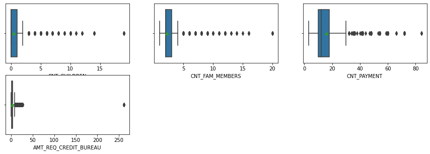

```python
cf_cmb_temp_var =['CNT_CHILDREN','CNT_FAM_MEMBERS','CNT_PAYMENT','AMT_REQ_CREDIT_BUREAU']
plt.figure(figsize=(15,10))
clns = 3
rows = len(cf_cmb_temp_var)
for i in enumerate(cf_cmb_temp_var):
    plt.subplot(rows,clns,i[0]+1)
    g= sns.boxplot(x=i[1],data=df_cmb,showmeans=True)
```

**`Amount Related Columns`** - We have a number of columns that holds amount related information.

All of our prominant Amount columns holds significant amount of Outliers, some of them are so different from the rest of the set that our `box` completely disappears.

As discussed earlier, we will try to factor in `Rational Subgroup` and see if ther are any outliers in the subgroupeed data. For our Amount related columns, we know that it is dependent on `Type of Occupation`. We will see the `amount` realted plots in a subgroup of `occupation` and estimate the outliers.

Even with Rational Subgrouping we can see too may outliers in our DataSet. We will have to work on these outliers before getting into any analysis, otherwise our outcome may not be true.

Top

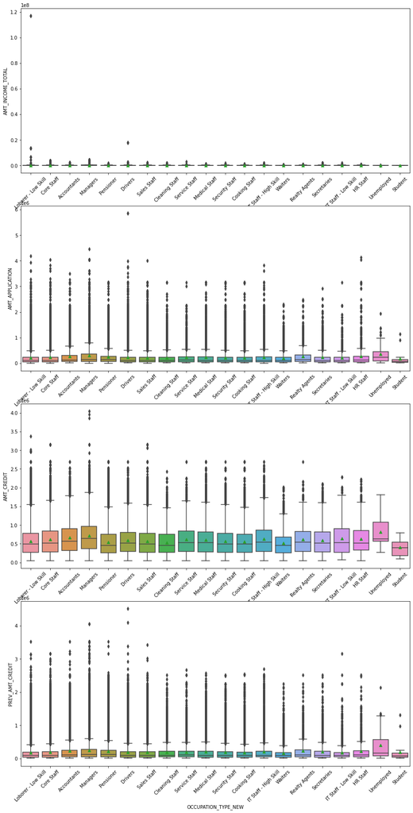

```python
cf_cmb_temp_var = ['AMT_INCOME_TOTAL', 'AMT_APPLICATION', 'AMT_CREDIT', 'PREV_AMT_CREDIT']

plt.figure(figsize=(15,30))
clns = 1
rows = len(cf_cmb_temp_var)
for i in enumerate(cf_cmb_temp_var):
    plt.subplot(rows,clns,i[0]+1)
    g= sns.boxplot(y=i[1],x= 'OCCUPATION_TYPE_NEW',data=df_cmb,showmeans=True)
    plt.xticks (rotation=45)
```

### 9B. Outlier Treatment Go Back to Glossary

Few of the outliers are quite straight forward to work while other may need an elaborative preparation and study before removing it. In this segment we will look into some of the methods that we can deploy to tackle the outlier problem.

[ a ] Apply General Logic to work with outliers [ b ] Data Transformation Method [ c ] Understanding percentile distribution and Inter Quartile Ranges ( IQR )

[ d ] Segmenting Outliers based on IQR

#### Data Transformation and Outlier identification for Count Data

> Transform the count data using Squreroot Method `𝑌=2√𝑋`

> We will identify Y as an outlier if `𝑌 > med(𝑌) + 3`, the constant (3) in this can be changed as needed

> For every column we apply this function, a new column is created which will hold if a specific data point is an `outlier` or `normal`

### General Logic to work with outliers

Let’s go back to our **`CNT_CHILDREN, CNT_PAYMENTS & CNT_FAM_MEMBERS`** columns and see if we can work on removing the outliers:

> > **`CNT_CHILDREN`** column has values as high as **`19`,** which is obviously an erroneous entry, but somehow this co-relates with the **`CNT_FAM_MEMBERS`** column. It may be due to a formulated column, which automaticall calculates Count of Family members based on Children Count etc. We will filter values greater than **`6`** children, and read through some related columns like **`Martial Status` and `Count of Family Members`**

> > For Martial status as Single we will change **`CNT\_CHILDREN`** value to 0

> > For **`CNT_FAM_MEMBERS`** we will impute mode to any value above than `7` family members

> > We will also remove the maximum value from `AMT_REQ_CREDIT_BUREAU` as it is unusually high in the data setTop

```python
#Filter Date of Birth and Martial Status Columns to understand this better
#We have converted the days birth to years on the fly for clear understanding
#both count children and count fam members seems to have unrealistic values
df_cmb_DOB = df_cmb.loc[df_cmb['CNT_CHILDREN'] >= 6]

df_cmb_DOB['DAYS_BIRTH'] =df_cmb_DOB['DAYS_BIRTH'].div(366)
df_cmb_DOB[['NAME_FAMILY_STATUS','CNT_CHILDREN','DAYS_BIRTH','CNT_FAM_MEMBERS']]
```

|  | NAME_FAMILY_STATUS | CNT_CHILDREN | DAYS_BIRTH | CNT_FAM_MEMBERS |
| --- | --- | --- | --- | --- |
| 14224 | Married | 7 | 48.295082 | 9.0 |
| 14225 | Married | 7 | 48.295082 | 9.0 |
| 14226 | Married | 7 | 48.295082 | 9.0 |
| 14227 | Married | 7 | 48.295082 | 9.0 |
| 14228 | Married | 7 | 48.295082 | 9.0 |
| ... | ... | ... | ... | ... |
| 1280894 | Married | 6 | 40.598361 | 8.0 |
| 1280895 | Married | 6 | 40.598361 | 8.0 |
| 1280896 | Married | 6 | 40.598361 | 8.0 |
| 1374270 | Widow | 7 | 29.890710 | 8.0 |
| 1374271 | Widow | 7 | 29.890710 | 8.0 |

167 rows × 4 columns

```python
#Replace the Children Count column values to 0 for any value greater than or equal to 6 and Maritial Status as Single
df_cmb.loc[(df_cmb['CNT_CHILDREN']>=6) & (df_cmb['NAME_FAMILY_STATUS']=='Single'), 'CNT_CHILDREN'] = 0
#Replace the Children Count column values to 1 for any value greater than or equal to 6 and Maritial Status as Single
df_cmb.loc[(df_cmb['CNT_CHILDREN']>=6) & (df_cmb['NAME_FAMILY_STATUS']!='Single'),
           'CNT_CHILDREN'] = 1
#Replace the Family Member Count column values to Mode for any value greater than or equal to 7
df_cmb.loc[(df_cmb['CNT_FAM_MEMBERS']>=7) , 'CNT_FAM_MEMBERS'] = df_cmb['CNT_FAM_MEMBERS'].mode()
#Null value in CNTFAM Member remove it (there are just 2 entries)
df_cmb = df_cmb[df_cmb['CNT_FAM_MEMBERS'].notna()]
#remove max value from AMT_REQ_CREDIT_BUREAU
df_cmb = df_cmb.loc[df_cmb['AMT_REQ_CREDIT_BUREAU']!=df_cmb['AMT_REQ_CREDIT_BUREAU'].max()]
```

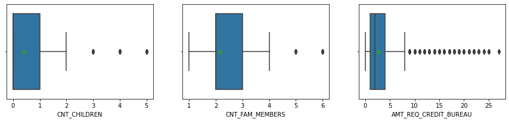

```python
#Lets validate using our boxplots again
cf_cmb_temp_var =['CNT_CHILDREN','CNT_FAM_MEMBERS','AMT_REQ_CREDIT_BUREAU']
plt.figure(figsize=(15,10))
clns = 3
rows = len(cf_cmb_temp_var)
for i in enumerate(cf_cmb_temp_var):
    plt.subplot(rows,clns,i[0]+1)
    g= sns.boxplot(x=i[1],data=df_cmb,showmeans=True)
```

#### Inter Quartile Range

Not all columns can be treated for outliers with same logic, in this segment we will look at another important method of working with outliers called **`Inter Quartile Ranges (IQR)`** >

> The `IQR` is calculated as the difference between the `75th` and the `25th` percentiles of the data and defines the box in a box and whisker plot.

> The `IQR` can be used to identify outliers by defining limits on the sample values that are a factor `k`of the `IQR` below the `25th percentile` or above the `75th percentile`. The common value for the factor k is the value `1.5` however you can use other factors also depending on various conditions

> We can calculate the percentiles of a dataset using the **`percentile() NumPy function`** that takes the dataset and specification of the desired percentile. The `IQR` can then be calculated as the difference between the `75th` and `25th` percentiles.

We have created two user defined function to help us segment Outliers from our various columns

> > **`yCube_iQr_gRp`** - This function is helful where we need to calculate Inter Quartile Range for a column grouped by another column. This is particularly important when we are dealing with `Rational Subgrouping`

> > **`yCube_iQr`** - This function is helpful where we don't have to segment IQR based on grouping. For example `Days Employed` is not dependent on any of the other categorical variable, so we can look at this column as a whole and calculate IQR and then the outliersTop

### Segmenting Outliers in our Data Frame

In this segment we will segment our data values in each columns, if they are outiler basis the two methods that we have discussed so far.

Outlier Segmentation using Data Transformation Method

> Transform the count data using Squreroot Method `𝑌=2√𝑋`

> We will identify Y as an outlier if `𝑌 > med(𝑌) + 3`, the constant (3) in this can be changed as needed

> For every column we apply this function, a new column is created which will hold if a specific data point is an `outlier` or `normal`

Outlier Segmentation using IQR method

> we will look at **`Q1`** and **`Q3`** using python function and calculate the Inter **`Quartile Range (IQR)`**

> any value less that `1.5 times the IQR` from `Q1` we will name it as `L_Outlier` (`Lower Outlier`)

> any value more than `1.5 times the IQR` from `Q3`we will name it as `U_Outlier` (`Upper Outlier`)

> any value in between the above two ranges, we will name it as `Normal` (`non-outliers`)

```python
#we will separate outlierss in these column grouped by Occupation type
df_cmb=yCube_iQr_gRp(df_cmb,'AMT_INCOME_TOTAL','OCCUPATION_TYPE_NEW',1.5)
df_cmb=yCube_iQr_gRp(df_cmb,'AMT_CREDIT','OCCUPATION_TYPE_NEW',1.5)
df_cmb=yCube_iQr_gRp(df_cmb,'AMT_ANNUITY','OCCUPATION_TYPE_NEW',1.5)
df_cmb=yCube_iQr_gRp(df_cmb,'PREV_AMT_CREDIT','OCCUPATION_TYPE_NEW',1.5)
df_cmb=yCube_iQr_gRp(df_cmb,'PREV_AMT_CREDIT','OCCUPATION_TYPE_NEW',1.5)
df_cmb=yCube_iQr_gRp(df_cmb,'AMT_APPLICATION','OCCUPATION_TYPE_NEW',1.5)
```

```python
#we will separate outlierss in these column grouped by Occupation type
yCube_iQr(df_cmb,'DAYS_EMPLOYED',1.5)
yCube_iQr(df_cmb,'DAYS_REGISTRATION',1.5)
yCube_iQr(df_cmb,'DAYS_BIRTH',1.5)
yCube_iQr(df_cmb,'DAYS_ID_PUBLISH',1.5)
```

|  | SK_ID_CURR | SK_ID_PREV | TARGET | NAME_CONTRACT_TYPE | PREV_NAME_CONTRACT_TYPE | PREV_NAME_CONTRACT_STATUS | PREV_CODE_REJECT_REASON | NAME_CLIENT_TYPE | NAME_INCOME_TYPE_NEW | OCCUPATION_TYPE_NEW | CODE_GENDER | NAME_FAMILY_STATUS | NAME_EDUCATION_TYPE | NAME_HOUSING_TYPE | NAME_TYPE_SUITE_NEW | PREV_NAME_TYPE_SUITE_NEW | FLAG_OWN_CAR | FLAG_OWN_REALTY | CHANNEL_TYPE | NAME_PORTFOLIO | DEF_CNT_SOCIAL | AMT_REQ_CREDIT_BUREAU | CNT_CHILDREN | CNT_FAM_MEMBERS | CNT_PAYMENT | DAYS_BIRTH | DAYS_DECISION | DAYS_EMPLOYED | DAYS_ID_PUBLISH | … |
| --- | --- | --- | --- | --- | --- | --- | --- | --- | --- | --- | --- | --- | --- | --- | --- | --- | --- | --- | --- | --- | --- | --- | --- | --- | --- | --- | --- | --- | --- | --- |
| 0 | 100002 | 1038818 | 1 | Cash loans | Consumer loans | Approved | Approved | New | Private Servant | Loborer - Low Skill | M | Single | Secondary | Own Apartment | Unaccompanied | Accompanied | N | Y | Stone | POS | True | 1.0 | 0 | 1.0 | 24.0 | 9461 | 606 | 637 | 2120 | … |
| 1 | 100004 | 1564014 | 0 | Revolving loans | Consumer loans | Approved | Approved | New | Private Servant | Loborer - Low Skill | M | Single | Secondary | Own Apartment | Unaccompanied | Unaccompanied | Y | Y | Regional or Local | POS | False | 0.0 | 0 | 1.0 | 4.0 | 19046 | 815 | 225 | 2531 | … |
| 2 | 100006 | 2078043 | 0 | Cash loans | Cash loans | Approved | Approved | Repeater | Private Servant | Loborer - Low Skill | F | Married | Secondary | Own Apartment | Unaccompanied | Unaccompanied | N | Y | Credit & Cash offices | Cash | False | 0.0 | 0 | 2.0 | 48.0 | 19005 | 181 | 3039 | 2437 | … |
| 3 | 100006 | 2827850 | 0 | Cash loans | Revolving loans | Canceled | CLIENT | Repeater | Private Servant | Loborer - Low Skill | F | Married | Secondary | Own Apartment | Unaccompanied | Accompanied | N | Y | Credit & Cash offices | Cards | False | 0.0 | 0 | 2.0 | NaN | 19005 | 181 | 3039 | 2437 | … |
| 4 | 100006 | 2190416 | 0 | Cash loans | Consumer loans | Approved | Approved | Repeater | Private Servant | Loborer - Low Skill | F | Married | Secondary | Own Apartment | Unaccompanied | Accompanied | N | Y | Country Wide | POS | False | 0.0 | 0 | 2.0 | 12.0 | 19005 | 311 | 3039 | 2437 | … |
| ... | ... | ... | ... | ... | ... | ... | ... | ... | ... | ... | ... | ... | ... | ... | ... | ... | ... | ... | ... | ... | ... | ... | ... | ... | ... | ... | ... | ... | ... | … |
| 1384993 | 402085 | 2567445 | 0 | Revolving loans | Consumer loans | Approved | Approved | New | Student | Student | F | Married | Secondary | Own Apartment | Unaccompanied | Unaccompanied | N | N | Regional or Local | POS | True | 1.0 | 1 | 3.0 | 6.0 | 8812 | 1377 | 1925 | 1503 | … |
| 1384994 | 402085 | 1744260 | 0 | Revolving loans | Consumer loans | Approved | Approved | Repeater | Student | Student | F | Married | Secondary | Own Apartment | Unaccompanied | Unaccompanied | N | N | Country Wide | POS | True | 1.0 | 1 | 3.0 | 18.0 | 8812 | 1093 | 1925 | 1503 | … |
| 1384995 | 402085 | 2144023 | 0 | Revolving loans | Consumer loans | Refused | LIMIT | Repeater | Student | Student | F | Married | Secondary | Own Apartment | Unaccompanied | Unaccompanied | N | N | Regional or Local | POS | True | 1.0 | 1 | 3.0 | NaN | 8812 | 1309 | 1925 | 1503 | … |
| 1384996 | 434942 | 1320060 | 0 | Cash loans | Consumer loans | Approved | Approved | New | Student | Student | M | Single | Incomplete higher | Office apartment | Accompanied | Accompanied | Y | Y | Regional or Local | POS | False | 1.0 | 0 | 1.0 | 10.0 | 8285 | 706 | 1692 | 960 | … |
| 1384997 | 449187 | 2028843 | 0 | Cash loans | Consumer loans | Approved | Approved | New | Student | Student | M | Married | Secondary | Own Apartment | Unaccompanied | Unaccompanied | Y | Y | Regional or Local | POS | False | 1.0 | 0 | 2.0 | 24.0 | 15770 | 1519 | 5607 | 4505 | … |

1384998 rows × 62 columns

```python
amt_income_nor = df_cmb['AMT_INCOME_TOTAL_out'].isin(['Normal'])
amt_app_nor = df_cmb['AMT_APPLICATION_out'].isin(['Normal'])
amt_credit_nor = df_cmb['AMT_CREDIT_out'].isin(['Normal'])
amt_annuity_nor = df_cmb['AMT_ANNUITY_out'].isin(['Normal'])
amt_prev_annuity_nor = df_cmb['PREV_AMT_CREDIT_out'].isin(['Normal'])
days_emp_nor = df_cmb['DAYS_EMPLOYED_out'].isin(['Normal'])
days_reg_nor = df_cmb['DAYS_REGISTRATION_out'].isin(['Normal'])
days_bir_nor = df_cmb['DAYS_BIRTH_out'].isin(['Normal'])
days_id_nor = df_cmb['DAYS_ID_PUBLISH_out'].isin(['Normal'])
df_cmb  = df_cmb[amt_income_nor&amt_app_nor & amt_credit_nor& amt_annuity_nor & amt_prev_annuity_nor &
                 days_emp_nor & days_reg_nor & days_bir_nor&days_id_nor ]
```

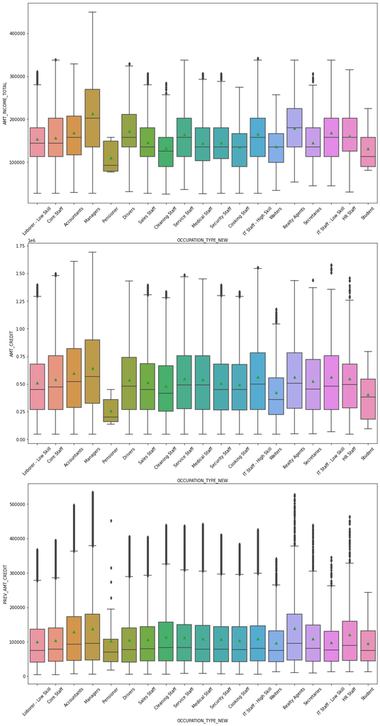

```python
#Lets validate using our boxplots again
cf_cmb_temp_var = ['AMT_INCOME_TOTAL', 'AMT_CREDIT', 'PREV_AMT_CREDIT']

plt.figure(figsize=(15,30))
clns = 1
rows = len(cf_cmb_temp_var)
for i in enumerate(cf_cmb_temp_var):
    plt.subplot(rows,clns,i[0]+1)
    g= sns.boxplot(y=i[1],x= 'OCCUPATION_TYPE_NEW',data=df_cmb,showmeans=True)
    plt.xticks (rotation=45)
```

### 10. Final Data Frame after all cleansing Go Back to Glossary

After almost 90 lines of python code, now we are amost ready with out final data file for the big awaited **Exploratory Data Analysis**. We will do final touch up on our data frame and clean some unwanted columns (the ones which we created during outlier processing).

```python
unwanted_cols = ['AMT_INCOME_TOTAL_out',
                 'AMT_APPLICATION_out',
                 'AMT_CREDIT_out',
                 'AMT_ANNUITY_out',
                 'PREV_AMT_CREDIT_out',
                 'DAYS_EMPLOYED_out',
                 'DAYS_REGISTRATION_out',
                 'DAYS_BIRTH_out',
                 'DAYS_ID_PUBLISH_out']
df_cmb = df_cmb.drop(columns=unwanted_cols)
df_cmb.shape
```

```
(876186, 53)
```

### 11. Exploratory Data Analytics Go Back to Glossary

We have come a long way in terms of cleaning our data, imputing and deleting unnecessary values in both of our `Application Data` and `Previous Application Data` data frame and removing outliers to make it more meaningful and quote unquote normal. Now we are ready to move into the most critical and interesting segment of our work, **`Data Analysis`**. In this segment we will work on combined sets of **`df_app`** and **`df_pre`** dataframes called **`df_cmb`** and bring out all the interesting and critical information in the dataset with the help of **`univarate`** and **`multivarate`** data analysis. We will also use several **`parametric`** and **`nonparametric`** **`statistical`** analysis to draw some insights and statistically validated output from our data.

In order for us to understand the outcomes, we will try do segment our analysis basis the type of variables we have in our data set. We will perform our `Data Analysis` basis following variables types. Remember our main **`VILLAIN`** is alwyas **`Loan Defaults`** which is our target variable and fortunately our column name is also **`TARGET`**

> **Output Variable** -`['TARGET']` - this is our target variable, all our focus would be around this column which holds binomial data

> **Binomial factors** - `['NAME_CONTRACT_TYPE', 'CODE_GENDER','NAME_TYPE_SUITE_NEW','FLAG_OWN_CAR', 'FLAG_OWN_REALTY','DEF_CNT_SOCIAL','LIVE_CITY_NOT_WORK_CITY', 'LIVE_REGION_NOT_WORK_REGION', 'REG_CITY_NOT_LIVE_CITY', 'REG_CITY_NOT_WORK_CITY', 'REG_REGION_NOT_LIVE_REGION', 'REG_REGION_NOT_WORK_REGION']` - These columns contains only two probable outputs, Yes or No, True or False, 0 or 1 and Male or Female. This type of data is known as binomial data, and hence they tend to follow a `binomial distribution`. We will have to perform a set of non-parametric tests on these types of data.

> **Polynomial factors** - `['PREV_NAME_CONTRACT_TYPE', 'PREV_NAME_CONTRACT_STATUS', 'PREV_CODE_REJECT_REASON', 'NAME_CLIENT_TYPE', 'NAME_INCOME_TYPE_NEW', 'OCCUPATION_TYPE_NEW', 'NAME_FAMILY_STATUS', 'NAME_EDUCATION_TYPE', 'NAME_HOUSING_TYPE','CHANNEL_TYPE' ,'NAME_PORTFOLIO','CNT_FAM_MEMBERS','AMT_REQ_CREDIT_BUREAU','DAYS_BIRTH', 'DAYS_DECISION', 'DAYS_EMPLOYED', 'DAYS_ID_PUBLISH', 'DAYS_REGISTRATION', 'FLAG_DOCUMENT_COUNT','REGION_RATING_CLIENT', REGION_RATING_CLIENT_W_CITY', 'REGION_RATING_CLIENT', 'REGION_RATING_CLIENT_W_CITY','NAME_GOODS_CATEGORY', 'NAME_CASH_LOAN_PURPOSE']` - these columns have multiple outputs, some even extend to counts we cannot represent in a categorical plot. We need to perform comparaitve graphical represenation for this type of data, especially if the target is a binomial variable. We also have a set of `COUNT DATA` in some of these factors like `'DAYS_ID_PUBLISH'`, some of these count data are of finite nature like `'CNT_FAM_MEMBERS'` which can take a maximum of a certain finite number (single digit in our case), and then we have some other count variables which can take any integer value like `'DAYS_DECISION'`. Depending on type of Polynomial factors we will use various graphical representation. Again for these type of data we will have to do Non Parametric test for statistical inferences.

> **Continuous factors** - `['AMT_INCOME_TOTAL', 'AMT_APPLICATION', 'AMT_CREDIT', 'PREV_AMT_CREDIT', 'AMT_ANNUITY', 'PREV_AMT_ANNUITY','AMT_DOWN_PAYMENT', 'RATE_DOWN_PAYMENT', 'EXT_SOURCE_AVG', 'REGION_POPULATION_RELATIVE','AMT_GOODS_PRICE', 'PREV_AMT_GOODS_PRICE']` - these columns contain what is known as contineous variable. These type of data can take any value in a contineous scale. For these type of data we can perform parametric statistical tests.

Depending on the type of variable we are dealing with, some of our tests, procedure and assumptions will vary. We will talk about them in each section as we encounter them.

Also I am sure you must be wondering where are few of the data columns, why arn't we analyzing them, well its most likely due to the fact that they are dependent factors. For example , `CNT_CHILDREN` column is direclty dependent on `CNT_FAMILY_MEMBERS`, including such dependent variables specially in statistical treatment result in something called `Confounding`, which results in some inaccuracy in the estimated measures.Similarly we have 'AMT_ANNUITY', 'PREV_AMT_ANNUITY' which are direclty dependent on 'AMT_CREDIT'and 'PREV_AMT_CREDIT' (remember annuity is a derived metric based on these factors).

> **Dependent factors** `['AMT_ANNUITY', 'PREV_AMT_ANNUITY', 'CNT_CHILDREN', 'RATE_DOWN_PAYMENT', 'AMT_GOODS_PRICE', 'PREV_AMT_GOODS_PRICE']`

> **Not Required factors** - `['SK_ID_CURR', 'SK_ID_PREV','NAME_GOODS_CATEGORY', 'NAME_CASH_LOAN_PURPOSE']`- these columns are needed for few form of analysis, but at large we will not work with these columns. While 'SK_ID_CURR', 'SK_ID_PREV' helps us to establish relation among two data set but are not factors, 'NAME_GOODS_CATEGORY', 'NAME_CASH_LOAN_PURPOSE' are associated only for a set of data (for loan realted to Goods and Cash) and contains too many null for us to use them in any statistical treatment.

```python
df_cmb_target_var=['TARGET']
df_cmb_binomial_var = ['NAME_CONTRACT_TYPE', 'CODE_GENDER','NAME_TYPE_SUITE_NEW','FLAG_OWN_CAR',
                       'FLAG_OWN_REALTY','DEF_CNT_SOCIAL','REG_CITY_NOT_WORK_CITY', 'REG_REGION_NOT_LIVE_REGION',
                       'REG_REGION_NOT_WORK_REGION']

df_cmb_polynomial_var = ['PREV_NAME_CONTRACT_TYPE','PREV_NAME_CONTRACT_STATUS','PREV_CODE_REJECT_REASON',
                         'NAME_EDUCATION_TYPE','NAME_HOUSING_TYPE','CHANNEL_TYPE' ,'NAME_PORTFOLIO',
                         'REGION_RATING_CLIENT', 'REGION_RATING_CLIENT_W_CITY']

df_cmb_fcount_var =['CNT_FAM_MEMBERS','FLAG_DOCUMENT_COUNT','AMT_REQ_CREDIT_BUREAU']

df_cmb_icount_var =['DAYS_BIRTH','DAYS_DECISION','DAYS_EMPLOYED', 'DAYS_ID_PUBLISH', 'DAYS_REGISTRATION']

df_cmb_continuous_var = ['EXT_SOURCE_AVG','AMT_INCOME_TOTAL', 'AMT_APPLICATION', 'AMT_CREDIT', 'PREV_AMT_CREDIT',
                         'REGION_POPULATION_RELATIVE']

df_cmb_dependent_Var =['CNT_CHILDREN','AMT_ANNUITY', 'PREV_AMT_ANNUITY',
                       'AMT_DOWN_PAYMENT', 'RATE_DOWN_PAYMENT','AMT_GOODS_PRICE', 'PREV_AMT_GOODS_PRICE']

df_cmb_notrequired_Var =['SK_ID_CURR', 'SK_ID_PREV','NAME_GOODS_CATEGORY', 'NAME_CASH_LOAN_PURPOSE']
```

### A. Overall Percentage of Payment Difficulties Go Back to Glossary

Lets start with the most important metric, what percentage of our loan have at least one payment default.

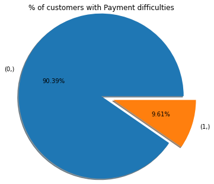

```python
c = df_cmb[df_cmb_target_var].value_counts(sort=False).plot.pie(autopct='%1.2f%%',
                                                            shadow=True,
                                                            normalize =True,
                                                            title ='% of customers with Payment difficulties\n\n',
                                                            explode=(0, 0.25),
                                                            ylabel='',
                                                            radius=1.6)
plt.show()
```

### B. Applicants with Payment Difficulties based on multiple attribute Go Back to Glossary

We have divided our data colunms into different data types, now lests look at each of the data type and how we can map our target variable basis each of these columns.

[ a ] For Binomial Variables [ b ] For Polynominal Variables [ c ] For Finite Count Variables [ d ] For Other Count Variables [ e ] For Contineous Variables

### For Binomial Variables

As we need to compare Binomial variables against another Binomial Variable, we can use bar plots. Ecah bar represents the factors and each color represents the binomial target. You can do a vis a vis comparision among multiple factors at a glace. Top

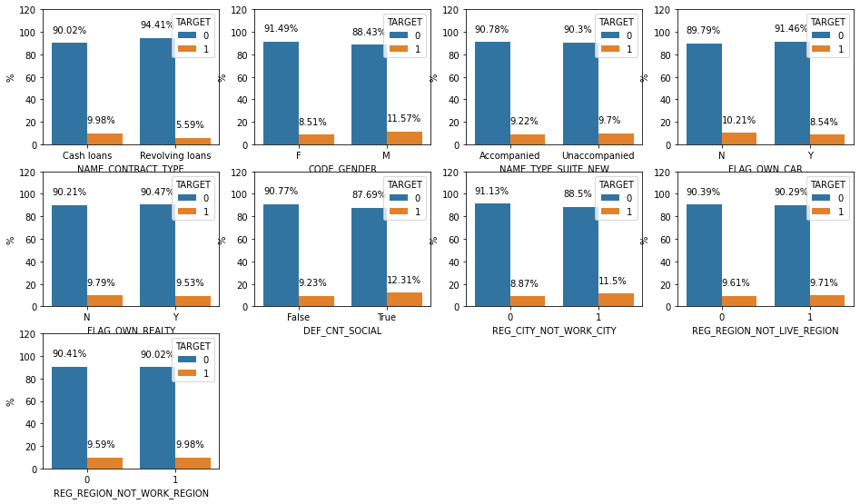

```python
plt.figure(figsize=(16,29))

clns = 4
rows = len(df_cmb_binomial_var)

for i in enumerate(df_cmb_binomial_var):
    df= df_cmb.groupby(i[1])[df_cmb_target_var[0]].value_counts(normalize=True).mul(100).rename('%').reset_index()
    #print(df)
    plt.subplot(rows,clns,i[0]+1)
    g= sns.barplot(data=df,x=i[1],y='%',hue=df_cmb_target_var[0])
    g.set_ylim(0,120)
    #plt.xticks (rotation=45)
    for p in g.patches:
        txt = str(p.get_height().round(2)) + '%\n'
        txt_x = p.get_x()
        txt_y = p.get_height()
        g.text(txt_x,txt_y,txt)
```

### For Ploynominal Variables

Top

```
posx and posy should be finite values
posx and posy should be finite values
posx and posy should be finite values
posx and posy should be finite values
```

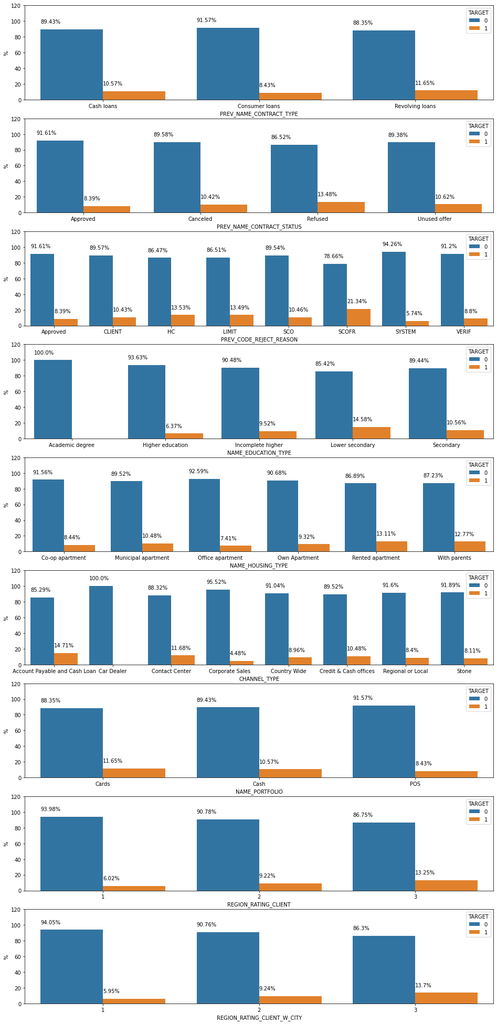

```python
plt.figure(figsize=(16,35))

clns = 1
rows = len(df_cmb_polynomial_var)

for i in enumerate(df_cmb_polynomial_var):
    df= df_cmb.groupby(i[1])[df_cmb_target_var[0]].value_counts(normalize=True).mul(100).rename('%').reset_index()
    #print(df)
    plt.subplot(rows,clns,i[0]+1)
    g= sns.barplot(data=df,x=i[1],y='%',hue=df_cmb_target_var[0])
    g.set_ylim(0,120)
    #plt.xticks (rotation=45)
    for p in g.patches:
        txt = str(p.get_height().round(2)) + '%\n'
        txt_x = p.get_x()
        txt_y = p.get_height()
        g.text(txt_x,txt_y,txt)
```

### For Finite Count Variables

Top

[output not shown]

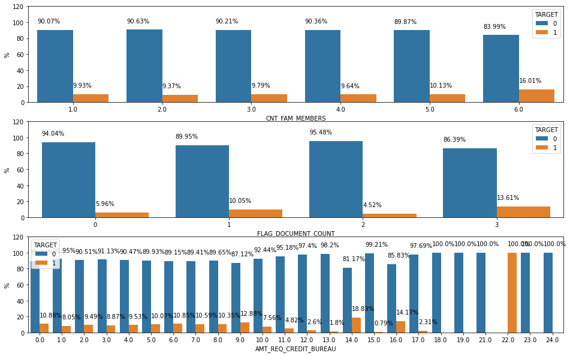

```python
plt.figure(figsize=(16,10))

clns = 1
rows = len(df_cmb_fcount_var)

for i in enumerate(df_cmb_fcount_var):
    df= df_cmb.groupby(i[1])[df_cmb_target_var[0]].value_counts(normalize=True).mul(100).rename('%').reset_index()
    #print(df)
    plt.subplot(rows,clns,i[0]+1)
    g= sns.barplot(data=df,x=i[1],y='%',hue=df_cmb_target_var[0])
    g.set_ylim(0,120)
    #plt.xticks (rotation=45)
    for p in g.patches:
        txt = str(p.get_height().round(2)) + '%\n'
        txt_x = p.get_x()
        txt_y = p.get_height()
        g.text(txt_x,txt_y,txt)
```

### For Other Count Variables

Top

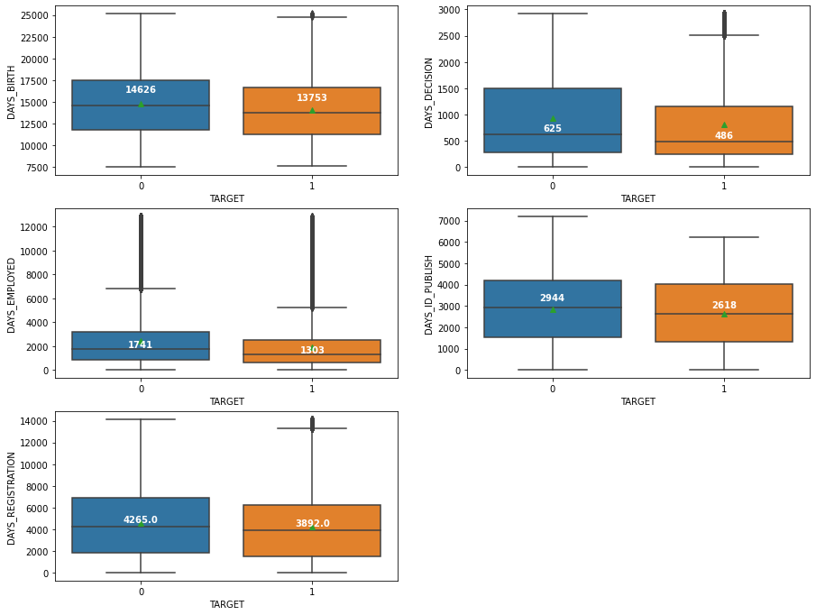

```python
plt.figure(figsize=(15,20))

clns = 2
rows = len(df_cmb_icount_var)

for i in enumerate(df_cmb_icount_var):
    plt.subplot(rows,clns,i[0]+1)
    g= sns.boxplot(x=df_cmb_target_var[0],y=i[1],data=df_cmb,showmeans=True)
    medians = df_cmb.groupby(df_cmb_target_var[0])[i[1]].median()
    vertical_offset = df_cmb[i[1]].median() * 0.1
    #plt.xticks (rotation=45)
    for xtick in g.get_xticks():
        g.text(xtick,medians[xtick] + vertical_offset,medians[xtick],
               horizontalalignment='center',size='medium',color='w',weight='semibold')
```

### For Contineous Variables

Top

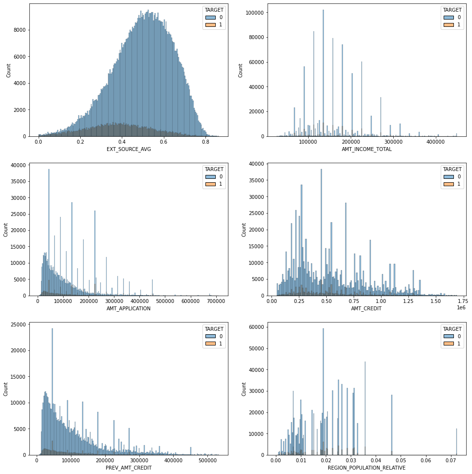

```python
plt.figure(figsize=(16,35))

clns = 2
rows = len(df_cmb_continuous_var)

for i in enumerate(df_cmb_continuous_var):
    plt.subplot(rows,clns,i[0]+1)
    g= sns.histplot(hue=df_cmb_target_var[0],x=i[1],data=df_cmb)
```

### C. Stastistical Data Analysis and Sample Tests Go Back to Glossary

So far we have looked into some of the basic pie and bar charts and percentage values (proportions) to understand which of the factors have higher tendency to contribute more towards a loan default or payment difficulties.

While those univarate analysis helped us to bring forth some of the key observations, but just with them we will not help us to make discrete decission. For exampple, we found that `Male` gender group has a higher `proportion` of payment difficulties as compated to `Female` population, but we don't have a clear view of weather it was merely one time possibility by chance that male had higher percentage or is it the `probability` of male defaults is always higher (not merely a reandom chance).

In this segment we will use some of the *`basic stastistical tests`* to stastistically estimate higher tendency of a particular proportion over other.

Will take the help of `Sample Proportion Tests` (also called `2-sample z-test` to `stastically establish` if one proportion has higher likelihood of a particular output as compated to other proportion. A Z-test is a type of hypothesis test that will give a way for you to figure out if results from a test are valid and repeatable or it was merely a random occurance.

> Here are some of the assumptions we need to satisfy for Sample Tests
> 1. Sample size for our test is more than 30 data points
> 2. The assumptions for the `binomial distribution` are satisfied for both populations
> 3. Data should be randomly selected and data points should be independent of each other

> *Here are the steps we will follow for our sample proportion tests*
> 1. State the null and alternate hypothesis (H0 and Ha)
> 2. We will chose al alpha level of 0.05 - Alpha level also known as significance level is the probability of making the wrong decision when the null hypothesis is true. So when we select 0.05, we will have 5% random chance of our test giving us wrong result.
> 3. Use python stastistical library to calculate Probability Values as well as Z stastistics and create a simple python function to give us an outcome

*Always remember P-Low Null Hypothesis Go*

[ a ] Sample Proportion Tests for Binomial Columns vs. the target [ b ] ChiSquare Test for Multinomial Data Columns [ c ] Testing Data Normality for Contineous Variables [ d ] Student's Test and Moods Median tests for Contineous Data Columns

### Sample Proportion Tests for Binomial Columns vs. the target

We have seen in our Univarate Analysis section that `Male` have a slightly higher default rate of `11.11%` compared to `Female` gender which stands at `7.9%`

We will know test this samples to see was it merely by a chance that our Male proportion was higher, or does it have a higher likelyhood of repeating (Male proptions will be different to Female proportions most of the time)

Note that `p value` is used in `hypothesis testing` is to help us support or reject the `null hypothesis`. The `p value` is the evidence against a `null hypothesis`. The `smaller the p-value`, the stronger the evidence that you should reject the `null hypothesis`.That is why in the above test our P value is `0.0000` with which we can reject the `Null Hypothesis`, if P value is greate than the `alpha`, we would have `Failed to reject the null hypothesis`

NB: P values are expressed as decimals although it may be easier to understand what they are if you convert them to a percentage. For example, a p value of 0.0254 is 2.54%. This means there is a 2.54% chance your results could be random (i.e. happened by chance). That’s pretty tiny. On the other hand, a large p-value of .9(90%) means your results have a 90% probability of being completely random and not due to anything in your experiment. Therefore, the smaller the p-value, the more important (“significant“) your result is.

The test result will be summarized at the end. Top

```python
df_cmb_stats_binomial=[]

for i in enumerate(df_cmb_binomial_var):
    df_cmb[i[1]]= label.fit_transform(df_cmb[i[1]])

    sample_success_a = df_cmb.loc[df_cmb[i[1]] == 1, df_cmb_target_var[0]].sum()
    sample_size_a = df_cmb.loc[df_cmb[i[1]] == 1, df_cmb_target_var[0]].count()
    sample_success_b = df_cmb.loc[df_cmb[i[1]] ==0 , df_cmb_target_var[0]].sum()
    sample_size_b = df_cmb.loc[df_cmb[i[1]] == 0, df_cmb_target_var[0]].count()

    successes = np.array([sample_success_a, sample_success_b])
    samples = np.array([sample_size_a, sample_size_b])

    significance = 0.05
    stat, p_value = proportions_ztest(count=successes, nobs=samples,  alternative='two-sided')

    H0="""At {sig} level of significance, we fail to reject null hypotheses.
The proportion of {tar} are same among {var} groups.\n""" .format(sig = significance, var = i[1],tar='Defaulters & Non Defaulters')
    HA="""At {sig} level of significance, we reject the null hypotheses and accept HA.
The proportion of {tar} are different among {var} groups.\n""" .format(sig = significance, var = i[1],tar='Defaulters & Non Defaulters')

    if p_value > significance:
        print ("\nFail to reject the null hypothesis -" + H0)
        df_cmb_stats_binomial.append([i[1],'p-Test',stat,p_value,H0])
    else:
        print ("\nReject the null hypothesis- "+ HA )
        df_cmb_stats_binomial.append([i[1],'p-Test',stat,p_value,HA])
```

```
Reject the null hypothesis- At 0.05 level of significance, we reject the null hypotheses and accept HA.
The proportion of Defaulters & Non Defaulters are different among NAME_CONTRACT_TYPE groups.


Reject the null hypothesis- At 0.05 level of significance, we reject the null hypotheses and accept HA.
The proportion of Defaulters & Non Defaulters are different among CODE_GENDER groups.


Reject the null hypothesis- At 0.05 level of significance, we reject the null hypotheses and accept HA.
The proportion of Defaulters & Non Defaulters are different among NAME_TYPE_SUITE_NEW groups.


Reject the null hypothesis- At 0.05 level of significance, we reject the null hypotheses and accept HA.
The proportion of Defaulters & Non Defaulters are different among FLAG_OWN_CAR groups.


Reject the null hypothesis- At 0.05 level of significance, we reject the null hypotheses and accept HA.
The proportion of Defaulters & Non Defaulters are different among FLAG_OWN_REALTY groups.


Reject the null hypothesis- At 0.05 level of significance, we reject the null hypotheses and accept HA.
The proportion of Defaulters & Non Defaulters are different among DEF_CNT_SOCIAL groups.


Reject the null hypothesis- At 0.05 level of significance, we reject the null hypotheses and accept HA.
The proportion of Defaulters & Non Defaulters are different among REG_CITY_NOT_WORK_CITY groups.


Fail to reject the null hypothesis -At 0.05 level of significance, we fail to reject null hypotheses.
The proportion of Defaulters & Non Defaulters are same among REG_REGION_NOT_LIVE_REGION groups.


Reject the null hypothesis- At 0.05 level of significance, we reject the null hypotheses and accept HA.
The proportion of Defaulters & Non Defaulters are different among REG_REGION_NOT_WORK_REGION groups.
```

### ChiSquare Test for Multinomial Data Columns

We have so far worked with two proportions tests that we used in `Binomial Data types`, and used stastistical methods to establish if any two set of proportions are different in terms of loan defaults. Now we have a couple of very interesting columns, but these columns hold information which when summarized will give more than just 2 factors, in other words they don't satisfy the binomial distribution citeria for Proportion Test. For these columns we will be working on another type of stastistical test known as `Chi Square Test`

> Our Null and Alternative Hypothesis for this tests can be stated as below

> > **Null Hypothesis(H0) - two or more (given set of) categorical variables are independent in some population**

> > **Alternate Hypothesis(H1) - two or more (given set of) categorical variables are not independent in some population**

Before we continue, let's first make sure we understand what **“independence”** really means in the first place.

In short, `independence` means that one variable doesn't “say anything” about another variable. A different way of saying the exact same thing is that independence means that `the relative frequencies of one variable are identical over all levels of some other variable`.

The test result for each column will be summarized at the end.

Our - *`CNT_CHILDREN`* column holds information regarding the number of children for each applicant. It holds categorical numeric values like `1`,`2`,`3`,`4` and `5`. We are now interested to know if there is a stastistical difference (or Similarity) among these categorical values and `Probability to Default`. We will be able to analyze this using *`ChiSquare Test of Independence`*. The chi-square independence test is a procedure for testing if two or more categorical variables are related in some population.

Much like `2 sample proportion test`, `ChiSquare Test of Independence` will help us to establish if individual proportions of *`CNT_CHILDREN`* column values (and other similar categorical columns) are different from each other.

In our graphical section here for our *`CNT_CHILDREN`* column we noted that-

> > `The loan default rate is quite consistent (between 8.93% to 10.11%) for customers having children count 0,1,2 an 3, but increases to 14.44% for children count 4 and then decreases to 6.76% for customers having children count 5`

Top

```python
df_cmb_stats_poly=[]

for i in enumerate(df_cmb_polynomial_var+df_cmb_fcount_var):
    data_cmb_cross = pd.crosstab(df_cmb[df_cmb_target_var[0]],df_cmb[i[1]])
    chi, pval, dof, exp = chi2_contingency(data_cmb_cross)
    significance = 0.05
    H0="""At {sig} level of significance, we fail to reject null hypotheses.
The relative frequencies of {tar} are independent of {var}.\n""" .format(sig = significance, var = i[1],tar='Defaulters & Non Defaulters')
    HA="""At {sig} level of significance, we reject the null hypotheses and accept HA.
The relative frequencies of {tar} are dependent of {var}.\n""" .format(sig = significance, var = i[1],tar='Defaulters & Non Defaulters')


    if pval < significance:
        print(HA)
        df_cmb_stats_poly.append([i[1],'x2-Test',chi,pval,HA])
    else:
        print(H0)
        df_cmb_stats_poly.append([i[1],'x2-Test',chi,pval,H0])
```

```
At 0.05 level of significance, we reject the null hypotheses and accept HA.
The relative frequencies of Defaulters & Non Defaulters are dependent of PREV_NAME_CONTRACT_TYPE.

At 0.05 level of significance, we reject the null hypotheses and accept HA.
The relative frequencies of Defaulters & Non Defaulters are dependent of PREV_NAME_CONTRACT_STATUS.

At 0.05 level of significance, we reject the null hypotheses and accept HA.
The relative frequencies of Defaulters & Non Defaulters are dependent of PREV_CODE_REJECT_REASON.

At 0.05 level of significance, we reject the null hypotheses and accept HA.
The relative frequencies of Defaulters & Non Defaulters are dependent of NAME_EDUCATION_TYPE.

At 0.05 level of significance, we reject the null hypotheses and accept HA.
The relative frequencies of Defaulters & Non Defaulters are dependent of NAME_HOUSING_TYPE.

At 0.05 level of significance, we reject the null hypotheses and accept HA.
The relative frequencies of Defaulters & Non Defaulters are dependent of CHANNEL_TYPE.

At 0.05 level of significance, we reject the null hypotheses and accept HA.
The relative frequencies of Defaulters & Non Defaulters are dependent of NAME_PORTFOLIO.

At 0.05 level of significance, we reject the null hypotheses and accept HA.
The relative frequencies of Defaulters & Non Defaulters are dependent of REGION_RATING_CLIENT.

At 0.05 level of significance, we reject the null hypotheses and accept HA.
The relative frequencies of Defaulters & Non Defaulters are dependent of REGION_RATING_CLIENT_W_CITY.

At 0.05 level of significance, we reject the null hypotheses and accept HA.
The relative frequencies of Defaulters & Non Defaulters are dependent of CNT_FAM_MEMBERS.

At 0.05 level of significance, we reject the null hypotheses and accept HA.
The relative frequencies of Defaulters & Non Defaulters are dependent of FLAG_DOCUMENT_COUNT.

At 0.05 level of significance, we reject the null hypotheses and accept HA.
The relative frequencies of Defaulters & Non Defaulters are dependent of AMT_REQ_CREDIT_BUREAU.
```

### Testing Data Normality for Contineous Variables

> > **H0 - Data came from a normally distributed population**

> > **H1 - Data came from a non-normally distributed population** Top

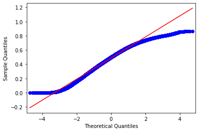

```
EXT_SOURCE_AVG --Statistics=25478.572, p=0.000
At 0.05 level of significance, we reject the null hypotheses and accept HA.
The sample data doesnot follow normal distribution.
```

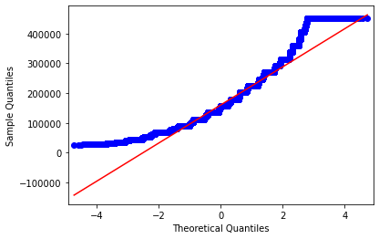

```
AMT_INCOME_TOTAL --Statistics=113366.792, p=0.000
At 0.05 level of significance, we reject the null hypotheses and accept HA.
The sample data doesnot follow normal distribution.
```

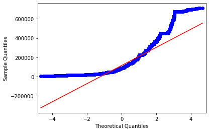

```
AMT_APPLICATION --Statistics=209529.020, p=0.000
At 0.05 level of significance, we reject the null hypotheses and accept HA.
The sample data doesnot follow normal distribution.
```

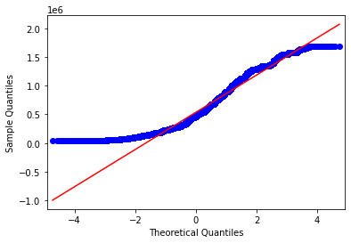

```
AMT_CREDIT --Statistics=70984.425, p=0.000
At 0.05 level of significance, we reject the null hypotheses and accept HA.
The sample data doesnot follow normal distribution.
```

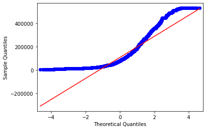

```
PREV_AMT_CREDIT --Statistics=145321.449, p=0.000
At 0.05 level of significance, we reject the null hypotheses and accept HA.
The sample data doesnot follow normal distribution.
```

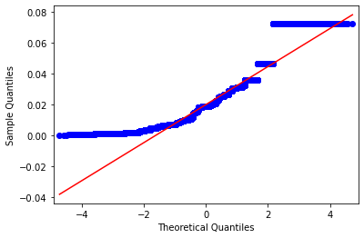

```
REGION_POPULATION_RELATIVE --Statistics=222400.474, p=0.000
At 0.05 level of significance, we reject the null hypotheses and accept HA.
The sample data doesnot follow normal distribution.
```

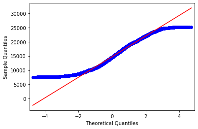

```
DAYS_BIRTH --Statistics=60438.417, p=0.000
At 0.05 level of significance, we reject the null hypotheses and accept HA.
The sample data doesnot follow normal distribution.
```

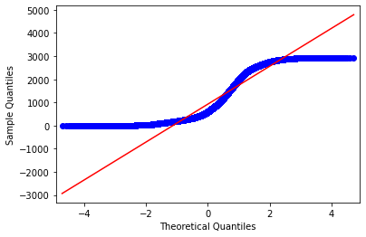

```
DAYS_DECISION --Statistics=101275.912, p=0.000
At 0.05 level of significance, we reject the null hypotheses and accept HA.
The sample data doesnot follow normal distribution.
```

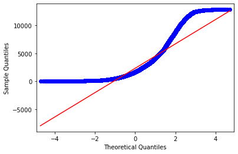

```
DAYS_EMPLOYED --Statistics=300440.773, p=0.000
At 0.05 level of significance, we reject the null hypotheses and accept HA.
The sample data doesnot follow normal distribution.
```

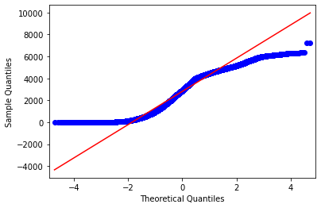

```
DAYS_ID_PUBLISH --Statistics=566150.913, p=0.000
At 0.05 level of significance, we reject the null hypotheses and accept HA.
The sample data doesnot follow normal distribution.
```

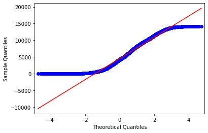

```
DAYS_REGISTRATION --Statistics=57466.592, p=0.000
At 0.05 level of significance, we reject the null hypotheses and accept HA.
The sample data doesnot follow normal distribution.
```

```python
for i in enumerate(df_cmb_continuous_var+df_cmb_icount_var):
    df_cmb_data=yCube_iQr(df_cmb,i[1],1.5)

    data= df_cmb_data[i[1]].dropna()
    qqplot(data,line='s')
    plt.show()
    stat, p = normaltest(data)
    print(i[1],'--Statistics=%.3f, p=%.3f' % (stat, p))
# interpret normality
    significance = 0.05
    H0 = """At %.2f level of significance, we fail to reject H0.
The sample data follows normal distribution.""" % (significance)
    HA = """At %.2f level of significance, we reject the null hypotheses and accept HA.
The sample data doesnot follow normal distribution.""" % (significance)
    if p > significance or math.isnan(p):
        print(H0)
    else:
        print(HA)
```

### Student's Test and Moods Median tests for Contineous Data Columns

So far we have looked into some of the categorical variables only, but we have some important contineous data columns like `**Overall Income of Applicants/Customers**`. Say if we want to see if Higher income group has lower probability of default or vice versa, or if we want to see if the `lower external credit score` results in `higher defaults`, how do we do it?

This is where we can use tests like `**Student T Tests**`,`**Welch's T Test**` and `**Moods Median Test**` depending on few observations and underlying assumptions in data.

Much like other stastistical tests, tests for contineous data need to satisfy one additional assumpation, that is `data normality`. A norma datal in general is free of `Outliers` or in common word should behave like the most of other data in that column. If we were asked to analze behaviours of `Dogs` in an experiment, but if our samples has a `Lion` do we want to analyze that `Lion`, well similary in any data set, if a group of data is `way different` than the rest, we will have to analyze them seprately.

There are various Stastistical methods to establish Data Normality, for our study we will take one simple Normality test Procedure called `D’Agostino and Pearson’s` method of normality. If our data is Normal, we will carry on with-

> `Welch's t-test`, or unequal variances t-test, whhich is a two-sample location test which is used to test the hypothesis that two populations have equal means. It is named for its creator, Bernard Lewis Welch, and is an adaptation of `Student's t-test`, `Welch's t-test` test is more reliable when the two samples have unequal variances and/or unequal sample sizes. These tests are often referred to as "unpaired" or "independent samples" t-tests, as they are typically applied when the statistical units underlying the two samples being compared are non-overlapping. Its is a parametric test, or in other way our data needs to be `normal` for us to perform this test.

> Our Null and Alternative Hypothesis for this tests can be stated as below

> > **Null Hypothesis(H0) - the average external credit score is same between defaulters and non defaulters**

> > **Alternate Hypothesis(H1) - the external credit score income of Defaulters is significantly different than that of Non Defaulters**

And if our data is not normal, we will use another non parametric test called

> `Moods Median Test`, this is a nonparametric test that is used to test the equality of medians from two or more populations. Therefore, it provides a nonparametric alternative to the `Student's t-test`, i.e we can use it withough assuming the underlying normality condition. The Mood’s median test works when the Y variable is continuous, discrete-ordinal or discrete-count, and the X variable is discrete with two or more attributes.

> Our Null and Alternative Hypothesis for this tests can be stated as below

> > **Null Hypothesis(H0) - the median of income is same between defaulters and non defaulters**

> > **Alternate Hypothesis(H1) - the median income of Defaulters is significantly different than that of Non Defaulters** Top

```python
df_cmb_stats_continuous=[]

for i in enumerate(df_cmb_continuous_var+df_cmb_icount_var):

    data_1 = df_cmb_data[df_cmb_data[df_cmb_target_var[0]]==1 & df_cmb_data[i[1]+'_out'].isin(['Normal'])]
    data_0 = df_cmb_data[df_cmb_data[df_cmb_target_var[0]]==0 & df_cmb_data[i[1]+'_out'].isin(['Normal'])]
    stat, p = normaltest(df_cmb_data[i[1]])
    # interpret normality
    significance = 0.05
    if p > significance or math.isnan(p):
        H0 = """At {sig} level of significance, we fail to reject H0.The Mean {var} between {tar} are same.\n""" .format(sig = significance, var = i[1],tar='Approved & Declined Loans')
        HA = """At {sig} level of significance, we reject the null hypotheses and accept HA.The Mean {var} between {tar} are different.\n""" .format(sig = significance, var = i[1],tar='Approved & Declined Loans')
        tval, pval = stats.ttest_ind(data_1[i[1]], data_0[i[1]], equal_var=False)
        if pval < significance:
            print(HA)
            df_cmb_stats_continuous.append([i[1],'Welchs t-test',stat,pval,HA])
        else:
            print(H0)
            df_cmb_stats_continuous.append([i[1],'Welchs t-test',stat,pval,H0])


    else:
        H0 = """At {sig} level of significance, we fail to reject H0.The Median {var} between {tar} are same.\n""" .format(sig = significance, var = i[1],tar='Approved & Declined Loans')
        HA = """At {sig} level of significance, we reject the null hypotheses and accept HA.The Median {var} between {tar} are different.\n""" .format(sig = significance, var = i[1],tar='Approved & Declined Loans')
        stat, pval,med, tbl = stats.median_test(data_1[i[1]], data_0[i[1]])
        if pval < significance:
            print(HA)
            df_cmb_stats_continuous.append([i[1],'Moods Median test',stat,pval,HA])
        else:
            print(H0)
            df_cmb_stats_continuous.append([i[1],'Moods Median test',stat,pval,H0])
```

```
At 0.05 level of significance, we reject the null hypotheses and accept HA.The Median EXT_SOURCE_AVG between Approved & Declined Loans are different.

At 0.05 level of significance, we reject the null hypotheses and accept HA.The Median AMT_INCOME_TOTAL between Approved & Declined Loans are different.

At 0.05 level of significance, we fail to reject H0.The Mean AMT_APPLICATION between Approved & Declined Loans are same.

At 0.05 level of significance, we reject the null hypotheses and accept HA.The Median AMT_CREDIT between Approved & Declined Loans are different.

At 0.05 level of significance, we fail to reject H0.The Mean PREV_AMT_CREDIT between Approved & Declined Loans are same.

At 0.05 level of significance, we reject the null hypotheses and accept HA.The Median REGION_POPULATION_RELATIVE between Approved & Declined Loans are different.

At 0.05 level of significance, we reject the null hypotheses and accept HA.The Median DAYS_BIRTH between Approved & Declined Loans are different.

At 0.05 level of significance, we reject the null hypotheses and accept HA.The Median DAYS_DECISION between Approved & Declined Loans are different.

At 0.05 level of significance, we reject the null hypotheses and accept HA.The Median DAYS_EMPLOYED between Approved & Declined Loans are different.

At 0.05 level of significance, we reject the null hypotheses and accept HA.The Median DAYS_ID_PUBLISH between Approved & Declined Loans are different.

At 0.05 level of significance, we reject the null hypotheses and accept HA.The Median DAYS_REGISTRATION between Approved & Declined Loans are different.
```

### D. Correlation between input variables and Loan Defaults Go Back to Glossary

All of the statistical tests done so far has helped us to establish existance or non-esistance of significant relationship between our input variables (like `Gender`, `Income` etc.) and output variable (`Loan Defaults`), but until now we don't know `how much` of a relationship exists between the input and the output variables. Now its time to assign a `numerical value to our relationship using` **`Correlation Analysis`**. But before we start drawing random heatmaps, it it critical for us to understand `Correlation` and different methods available to us in calculating `Correlation Coefficient`, which is dependend on type of data we have.

`Correlation` is a `bivariate analysis` that measures the strength of association between two variables and the direction of the relationship. In terms of the strength of relationship, the value of the `correlation coefficient varies between +1 and -1`. A value of `± 1` indicates a perfect degree of association between the two variables. As the correlation coefficient value goes towards `0`, the relationship between the two variables `will be weaker`. The direction of the relationship is indicated by the sign of the coefficient; a `+ sign` indicates a positive relationship and a `– sign` indicates a negative relationship. Usually, in statistics, we measure following types of correlations: `Pearson correlation`, `Kendall rank correlation`, `Spearman correlation`, `Cramér's V correlation` and the `Point-Biserial correlation`. I will quickly touch upon the two correlation we will be using:

**`Point-Biserial correlation`** - A point-biserial correlation is used to measure the strength and direction of the association that exists between one `continuous variable` and one `dichotomous variable`. It is a special case of the `Pearson’s correlation`, which is applied when you have `two continuous variables`, whereas in this case one of the variables is measured on a `dichotomous scale` . We will use this method to calculate Correlation for the `Loan Defaults` which is `dichotomous scale` of 0 and 1 (for no default and default) and `AMT_INCOME_TOTAL` and `EXT_SOURCE_AVG` which are contineous variables

**`Cramér's V correlation`** - The Cramér’s V (also known as Cramér’s φ) will help us to measure the strength of association between two nominal variables. Cramér’s V is a nonparametric statistic used in cross-tabulated table data. These data are usually measured at the nominal level, although some researchers will use Cramér’s V with ordinal data or collapsed (grouped) interval or ration data. This test is useful for us to establish mathematical relation between our `Loan Defaults` and nominal columns like `NAME_CONTRACT_TYPE, CODE_GENDER, FLAG_OWN_CAR, FLAG_OWN_REALTY` etc. With this we will no be able to calculate negative correlation as correlation cofficient in this case will range from 0 to +1.

> > While Point-Biserial Correlation is built on to scipy library, for Cramer Correlation we constructed custom function to calculate the same `YCube_Cramer_V`

[ a ] Correlation among Categorical columns and Payment Default [ b ] Correlation among Contineous Columns and Payment Default

### Correlation among Categorical columns and Payment Default

We will use Cramer's V logic to establish relation and direction of relation among our Categorical Columns and Target column. Its important to note that since both X and Y are categorical, we will have to interpret the outcome hand in hand with our frequency plot given above. For eg. our gender column has Male and Female and our target column has Defaulter and No Defaulter (1,0), though we may have positive correlation between these two columns, but this doen't necessarily mean that incrase in Male would result in increase in Defaulters, or vice versa. That is why we will have to analyze categorical frequency plots to understand the actual relationship.

Top

```python
#we will run Cramer's coeff on our Categorical Columns
df_cmb_Cramer=[]
for i in enumerate(df_cmb_binomial_var + df_cmb_polynomial_var + df_cmb_fcount_var):
    c= YCube_Cramer_V(df_cmb[i[1]],df_cmb[df_cmb_target_var[0]])
    df_cmb_Cramer.append([i[1],c])
df_cmb_Cramer = pd.DataFrame(df_cmb_Cramer, columns=["Variables", "Coeff"])
```

### Correlation among Contineous Columns and Payment Default

Now we will look into our contineous columns and most prominant ones are Applican't Income and External Credit Score. As our X is categorical (Defaulters or Non Defaulters) and our Y is contineous, we will use Pointbiserial method. We will have to infer the outcome hand in had with frequency plots as our X is categorical. Its because, a positive Pointbiserial correlation indicates relation between two columns, but since our categorical columns has multiple factors (like Male/Female), we will have to depend on individual frequency plot to see the individual relationship. Top

```python
#we will run Point-Biserial on our contineous variable column
df_cmb_PointBiserial =df_cmb.dropna()#biserial doesnot like NAN values nor unequal data in two columns


df_cmb_Biserial=[]
for i in enumerate(df_cmb_icount_var+df_cmb_continuous_var):
    p = stats.pointbiserialr(df_cmb_PointBiserial[df_cmb_target_var[0]], df_cmb_PointBiserial[i[1]])
    df_cmb_Biserial.append([i[1],p[0]])
df_cmb_Biserial = pd.DataFrame(df_cmb_Biserial, columns=["Variables", "Coeff"])
```

### E. Summarizing statistical tests output Go Back to Glossary

Here we will combing our Correlation Coefficients from both Pointbiserial and Cramers V outputs, and sort it out to find the top columns with relationship with our Target variable.

Most of the relationship that we have found is very feeble suggesting not strong correlation among these columns and target variable

Now its time to summarize all our findings, and list down top factors that can help us predict a defaulter and a non defaulter. Based on this factors we can work on `Regression` analysis to correctly predict the output.

```python
df_cmb_stats_binomial = pd.DataFrame(df_cmb_stats_binomial,
                                       columns=["Variables", "Test","Stats","PValue","Result"])
df_cmb_stats_poly = pd.DataFrame(df_cmb_stats_poly,
                                       columns=["Variables", "Test","Stats","PValue","Result"])
df_cmb_stats_continuous = pd.DataFrame(df_cmb_stats_continuous,
                                       columns=["Variables", "Test","Stats","PValue","Result"])


df_cmb_tests = pd.concat([df_cmb_stats_binomial,df_cmb_stats_poly],ignore_index=True)
df_cmb_tests = pd.concat([df_cmb_tests,df_cmb_stats_continuous],ignore_index=True)
df_cmb_coeff = pd.concat([df_cmb_Cramer,df_cmb_Biserial],ignore_index=True)
df_cmb_tests_final = pd.merge(left=df_cmb_tests, right=df_cmb_coeff,how='inner', on='Variables')
df_cmb_tests_final.sort_values(by='Coeff', ascending=False,ignore_index=True)
```

|  | Variables | Test | Stats | PValue | Result | Coeff |
| --- | --- | --- | --- | --- | --- | --- |
| 0 | PREV_CODE_REJECT_REASON | x2-Test | 4462.975371 | 0.000000e+00 | At 0.05 level of significance, we reject the null hypotheses and accept HA. \nThe relative frequencies of Defaulters & Non Defaulters are dependent of PREV_CODE_REJECT_REASON.\n | 0.071314 |
| 1 | REGION_RATING_CLIENT_W_CITY | x2-Test | 3659.422192 | 0.000000e+00 | At 0.05 level of significance, we reject the null hypotheses and accept HA. \nThe relative frequencies of Defaulters & Non Defaulters are dependent of REGION_RATING_CLIENT_W_CITY.\n | 0.064608 |
| 2 | PREV_NAME_CONTRACT_STATUS | x2-Test | 3499.808083 | 0.000000e+00 | At 0.05 level of significance, we reject the null hypotheses and accept HA. \nThe relative frequencies of Defaulters & Non Defaulters are dependent of PREV_NAME_CONTRACT_STATUS.\n | 0.063174 |
| 3 | NAME_EDUCATION_TYPE | x2-Test | 3311.887302 | 0.000000e+00 | At 0.05 level of significance, we reject the null hypotheses and accept HA. \nThe relative frequencies of Defaulters & Non Defaulters are dependent of NAME_EDUCATION_TYPE.\n | 0.061444 |
| 4 | REGION_RATING_CLIENT | x2-Test | 3250.044903 | 0.000000e+00 | At 0.05 level of significance, we reject the null hypotheses and accept HA. \nThe relative frequencies of Defaulters & Non Defaulters are dependent of REGION_RATING_CLIENT.\n | 0.060885 |
| 5 | CODE_GENDER | p-Test | 46.660753 | 0.000000e+00 | At 0.05 level of significance, we reject the null hypotheses and accept HA. \nThe proportion of Defaulters & Non Defaulters are different among CODE_GENDER groups.\n | 0.049837 |
| 6 | CHANNEL_TYPE | x2-Test | 1907.844414 | 0.000000e+00 | At 0.05 level of significance, we reject the null hypotheses and accept HA. \nThe relative frequencies of Defaulters & Non Defaulters are dependent of CHANNEL_TYPE.\n | 0.046577 |
| 7 | FLAG_DOCUMENT_COUNT | x2-Test | 1750.958099 | 0.000000e+00 | At 0.05 level of significance, we reject the null hypotheses and accept HA. \nThe relative frequencies of Defaulters & Non Defaulters are dependent of FLAG_DOCUMENT_COUNT.\n | 0.044665 |
| 8 | NAME_PORTFOLIO | x2-Test | 1576.916343 | 0.000000e+00 | At 0.05 level of significance, we reject the null hypotheses and accept HA. \nThe relative frequencies of Defaulters & Non Defaulters are dependent of NAME_PORTFOLIO.\n | 0.042397 |
| 9 | PREV_NAME_CONTRACT_TYPE | x2-Test | 1576.916343 | 0.000000e+00 | At 0.05 level of significance, we reject the null hypotheses and accept HA. \nThe relative frequencies of Defaulters & Non Defaulters are dependent of PREV_NAME_CONTRACT_TYPE.\n | 0.042397 |
| 10 | NAME_CONTRACT_TYPE | p-Test | -38.657814 | 0.000000e+00 | At 0.05 level of significance, we reject the null hypotheses and accept HA. \nThe proportion of Defaulters & Non Defaulters are different among NAME_CONTRACT_TYPE groups.\n | 0.041285 |
| 11 | REG_CITY_NOT_WORK_CITY | p-Test | 37.608089 | 1.585479e-309 | At 0.05 level of significance, we reject the null hypotheses and accept HA. \nThe proportion of Defaulters & Non Defaulters are different among REG_CITY_NOT_WORK_CITY groups.\n | 0.040163 |
| 12 | AMT_REQ_CREDIT_BUREAU | x2-Test | 1307.470961 | 3.797563e-262 | At 0.05 level of significance, we reject the null hypotheses and accept HA. \nThe relative frequencies of Defaulters & Non Defaulters are dependent of AMT_REQ_CREDIT_BUREAU.\n | 0.038288 |
| 13 | DEF_CNT_SOCIAL | p-Test | 31.970913 | 2.767177e-224 | At 0.05 level of significance, we reject the null hypotheses and accept HA. \nThe proportion of Defaulters & Non Defaulters are different among DEF_CNT_SOCIAL groups.\n | 0.034139 |
| 14 | NAME_HOUSING_TYPE | x2-Test | 949.801918 | 4.423575e-203 | At 0.05 level of significance, we reject the null hypotheses and accept HA. \nThe relative frequencies of Defaulters & Non Defaulters are dependent of NAME_HOUSING_TYPE.\n | 0.032838 |
| 15 | FLAG_OWN_CAR | p-Test | -25.346627 | 9.789754e-142 | At 0.05 level of significance, we reject the null hypotheses and accept HA. \nThe proportion of Defaulters & Non Defaulters are different among FLAG_OWN_CAR groups.\n | 0.027057 |
| 16 | CNT_FAM_MEMBERS | x2-Test | 126.548585 | 1.284644e-25 | At 0.05 level of significance, we reject the null hypotheses and accept HA. \nThe relative frequencies of Defaulters & Non Defaulters are dependent of CNT_FAM_MEMBERS.\n | 0.011778 |
| 17 | NAME_TYPE_SUITE_NEW | p-Test | 5.803360 | 6.499909e-09 | At 0.05 level of significance, we reject the null hypotheses and accept HA. \nThe proportion of Defaulters & Non Defaulters are different among NAME_TYPE_SUITE_NEW groups.\n | 0.006107 |
| 18 | FLAG_OWN_REALTY | p-Test | -3.801496 | 1.438252e-04 | At 0.05 level of significance, we reject the null hypotheses and accept HA. \nThe proportion of Defaulters & Non Defaulters are different among FLAG_OWN_REALTY groups.\n | 0.003918 |
| 19 | REG_REGION_NOT_WORK_REGION | p-Test | 2.628642 | 8.572654e-03 | At 0.05 level of significance, we reject the null hypotheses and accept HA. \nThe proportion of Defaulters & Non Defaulters are different among REG_REGION_NOT_WORK_REGION groups.\n | 0.002597 |
| 20 | REG_REGION_NOT_LIVE_REGION | p-Test | 0.359435 | 7.192695e-01 | At 0.05 level of significance, we fail to reject null hypotheses.\nThe proportion of Defaulters & Non Defaulters are same among REG_REGION_NOT_LIVE_REGION groups.\n | 0.000000 |
| 21 | AMT_INCOME_TOTAL | Moods Median test | 3313.414584 | 0.000000e+00 | At 0.05 level of significance, we reject the null hypotheses and accept HA.The Median AMT_INCOME_TOTAL between Approved & Declined Loans are different.\n | -0.014168 |
| 22 | AMT_CREDIT | Moods Median test | 581.692381 | 1.606772e-128 | At 0.05 level of significance, we reject the null hypotheses and accept HA.The Median AMT_CREDIT between Approved & Declined Loans are different.\n | -0.018219 |
| 23 | DAYS_DECISION | Moods Median test | 1015.400117 | 8.069766e-223 | At 0.05 level of significance, we reject the null hypotheses and accept HA.The Median DAYS_DECISION between Approved & Declined Loans are different.\n | -0.020180 |
| 24 | REGION_POPULATION_RELATIVE | Moods Median test | 9351.571466 | 0.000000e+00 | At 0.05 level of significance, we reject the null hypotheses and accept HA.The Median REGION_POPULATION_RELATIVE between Approved & Declined Loans are different.\n | -0.025966 |
| 25 | PREV_AMT_CREDIT | Welchs t-test | NaN | NaN | At 0.05 level of significance, we fail to reject H0.The Mean PREV_AMT_CREDIT between Approved & Declined Loans are same.\n | -0.026403 |
| 26 | DAYS_ID_PUBLISH | Moods Median test | 1174.899153 | 1.739648e-257 | At 0.05 level of significance, we reject the null hypotheses and accept HA.The Median DAYS_ID_PUBLISH between Approved & Declined Loans are different.\n | -0.030116 |
| 27 | DAYS_REGISTRATION | Moods Median test | 124.833444 | 5.535091e-29 | At 0.05 level of significance, we reject the null hypotheses and accept HA.The Median DAYS_REGISTRATION between Approved & Declined Loans are different.\n | -0.031617 |
| 28 | AMT_APPLICATION | Welchs t-test | NaN | NaN | At 0.05 level of significance, we fail to reject H0.The Mean AMT_APPLICATION between Approved & Declined Loans are same.\n | -0.032616 |
| 29 | DAYS_BIRTH | Moods Median test | 1673.651443 | 0.000000e+00 | At 0.05 level of significance, we reject the null hypotheses and accept HA.The Median DAYS_BIRTH between Approved & Declined Loans are different.\n | -0.065124 |
| 30 | DAYS_EMPLOYED | Moods Median test | 8685.581578 | 0.000000e+00 | At 0.05 level of significance, we reject the null hypotheses and accept HA.The Median DAYS_EMPLOYED between Approved & Declined Loans are different.\n | -0.065155 |
| 31 | EXT_SOURCE_AVG | Moods Median test | 29880.411262 | 0.000000e+00 | At 0.05 level of significance, we reject the null hypotheses and accept HA.The Median EXT_SOURCE_AVG between Approved & Declined Loans are different.\n | -0.214795 |

## 12. Phase I Project Summary Go Back to Glossary

Here we will summarize our top observations for this leg of our data analysis

[ a ] Factors of Interest [ b ] Data Imbalance

### Factors of Interest

Basis our overall Statistical test we have follow set of Top 10 Factors that we can include in our modeling

**Top Positive Factors - `PREV_CODE_REJECT_REASON, REGION_RATING_CLIENT_W_CITY, PREV_NAME_CONTRACT_STATUS, NAME_EDUCATION_TYPE, REGION_RATING_CLIENT`**

**Top Negative Factors - `EXT_SOURCE_AVG, DAYS_BIRTH, DAYS_EMPLOYED, AMT_APPLICATION, DAYS_REGISTRATION`**

Most of our factors have feeble correlation with the Target Variable (Loan Defaults), we will always have to keep this in mind while performing any data models

Top

### Data Imbalance

Imbalanced data typically refers to a classification problem where the number of observations per class is not equally distributed; often you'll have a large amount of data/observations for one class (referred to as the majority class), and much fewer observations for one or more other classes (referred to as the minority class).

Having majority of one value in the dataset may result in what is called `Aplah` and `Beta` errors or Type I and Type II errors.

In our data set also we have clear data imbalance problem, and it has been shown repeatedly in our Exploratory Data Analysis segment. For example, we have <10% of defaulters while rest 90% are non defaulters. Well as a bank we always wanted this, but from a modeling prespective, this may cause some errors in our predictions.

While there are many established ways to work out with this, some of which are now embeded as a part of Machine Learning Algorithms (like Oversampling, Undersampling and SMOTE etc), on easy way to deal with these kind of problem is 'Random Sampling', we can randomly sample the minory class and duplicate the sampled observation. In our next segment we will surely look more in terms of sampling other algorithmns to deal with this problem.

Top